# Ch. 1 Introduction — fluidpy

← All chapters🎮 All explainers

← PreviousNext →

[▶ Open in Colab](https://colab.research.google.com/github/shammun/fluidpy/blob/main/notebooks/ch01_introduction_colab.ipynb) ↓ Download .ipynb [View on GitHub](https://github.com/shammun/fluidpy/blob/main/notebooks/ch01_introduction.ipynb)

## Interactive explainers in this chapter

🎮 1**When does 'density at a point' make sense?**Grow a sampling box from 1 nm to 1 m through a gas or a liquid and watch its density reading go from wild molecular noise to a steady plateau to the flow's own variation.🎮 2**How does the fluid learn that a plate moved?**The top plate starts moving: watch momentum diffuse down through the gap, the profile relax to a straight line and the wall stress settle at μU/h, with ν, not μ, setting the clock. Heat (Fourier) and species (Fick) modes show the same diffusion.🎮 3**Same two states: what depends on the path?**Take 1 kg of air between the same two states along different routes: heat and work change, internal energy and entropy do not, and friction breaks ds = dq/T.🎮 4**Push a parcel up: does it come back?**Shape the environment's temperature (or density) profile, lift a parcel and release it: it oscillates at N, stays put or runs away, with the stability criterion shown in Kundu's and in the meteorology sign convention.🎮 5**Why can 7 pipe variables shrink to 4 numbers?**Switch variables off, pick the repeating set and watch the dimensional matrix, its rank, the exponent solve and the Π groups change; then change units and see every Π keep its value.

# Chapter 1 — Introduction

*Fluid Mechanics, 5th edition — Pijush K. Kundu, Ira M. Cohen, David R. Dowling (2012).* This notebook teaches every new idea of the chapter with plain words, step-by-step mathematics, small worked examples, tested Python from the `fluidpy` package, figures, animations and interactive explainers. It does not reproduce the book's text or figures; equations are cited by their numbers so you can follow along in your copy.

**The big idea in one paragraph**

A fluid is matter that keeps deforming under any shear stress, and we describe it as a **continuum**: density, velocity, pressure and temperature have a value at every point. Chapter 1 builds the vocabulary that the rest of the book stands on — molecules averaged into fields (§1.4), molecules carrying momentum and heat down gradients (§1.5), pressure in a fluid at rest (§1.7), the thermodynamics of a small fluid particle (§1.8–1.9), when a stratified column of air or water is stable (§1.10), and how dimensional analysis shrinks a problem to a few numbers (§1.11).

**Road map** — the new ideas of this chapter, in the order they build on each other:

1. The continuum hypothesis — a value at a point is the plateau of an average (C06)
2. Newton's law of viscosity — shear stress is a flux of momentum (C12)
3. The hydrostatic law — pressure grows downward by the weight above (C20)
4. The first law — heat plus work changes internal energy (C25)
5. Entropy and the Gibbs relations (C35)
6. The speed of sound — stiffness at constant entropy (C36)
7. The perfect-gas law p = ρRT (C40)
8. The isentropic law p/ρ^γ = const (C45)
9. The displaced parcel (C50)
10. The Brunt–Väisälä frequency N² (C51)
11. The adiabatic lapse rate, in both sign conventions (C54)
12. Potential temperature θ (C55)
13. Dimensional homogeneity (C64)
14. The dimensional matrix (C67)
15. Buckingham's Π theorem (C69)

**What you should already know** (each is recapped where it is used):

- school physics: force, energy, SI units
- calculus of one variable, and a little linear algebra
- Python with numpy — everything else (partial derivatives, Maxwell relations, null spaces, sympy, plotly …) is primed with a 📎 box right where it is first used

## 🎮 Interactive explainers in this chapter

| # | Explainer | What it makes clear |
| --- | --- | --- |
| 1 | **When does 'density at a point' make sense?** | a value at a point is the plateau of an average |
| 2 | **How does the fluid learn that a plate moved?** | viscosity diffuses momentum; ν sets the clock |
| 3 | **Same two states: what depends on the path?** | q and w depend on the route, Δe and Δs do not |
| 4 | **Push a parcel up: does it come back?** | stability compares two lapse rates — in both sign conventions |
| 5 | **Why can 7 pipe variables shrink to 4 numbers?** | Π groups are the null space of a matrix |

Each one opens right where its idea is taught and fills the window (no scrolling). Start with the **Walkthrough**, then **Explore** with the sliders and presets, read **Explain** (every number worked out with your settings, and what it means), step through the **Derivation** where there is one, read the **Equations** and the **Code**, and finish with **Check yourself**. On the web page they are full-window; in Colab and Jupyter they appear in the cell output (use ⤢ *Full screen* or *Open in new tab* for more room).

## ⚙️ Setup — run this cell first

It works in three places without changes:

- **Google Colab** — clones the public repository into `/content/fluidpy` (the `fluidpy` package, its tests and the interactive explainers) and installs the one package Colab lacks (`pint`). No GPU is needed.
- **Jupyter / VS Code on your computer** — finds the repository root (the folder with `book.yaml`) and imports from it.
- **The published web page** — already executed; nothing to run.

```python
# ── Setup: find (or fetch) the fluidpy repository, then load the house style ─────────────────────────────
import os, sys, subprocess, pathlib                     # standard library only, so this cell never fails on imports

IN_COLAB = "google.colab" in sys.modules                 # True when this notebook runs inside Google Colab
REPO_URL = "https://github.com/shammun/fluidpy.git"               # the public repository with the fluidpy package

if IN_COLAB:
    ROOT = pathlib.Path("/content/fluidpy")              # where the repository is cloned on Colab
    if not ROOT.exists():                                 # first run in this Colab session: clone it
        subprocess.run(["git", "clone", "--depth", "1", REPO_URL, str(ROOT)], check=True)
    else:                                                 # later runs: fetch the newest version
        subprocess.run(["git", "-C", str(ROOT), "pull", "--ff-only", "-q"], check=False)
    subprocess.run([sys.executable, "-m", "pip", "install", "-q", "-r", str(ROOT / "requirements-colab.txt")], check=True)
else:
    ROOT = pathlib.Path.cwd().resolve()                   # start where Jupyter was launched …
    while not (ROOT / "book.yaml").exists() and ROOT != ROOT.parent:
        ROOT = ROOT.parent                                # … and walk up until we find the repository root

os.chdir(ROOT)                                            # relative paths (outputs/, viz/) now resolve from the root
if str(ROOT) not in sys.path:
    sys.path.insert(0, str(ROOT))                         # make `import fluidpy` work

from fluidpy.core.style import setup_notebook            # matplotlib + plotly style shared with the explainers
from fluidpy.core.embed import show_viz                  # shows an interactive explainer in the notebook
from fluidpy.core.anim import show_animation             # plays a matplotlib animation inline
FAST = setup_notebook()                                   # FAST=True (env FLUIDPY_FAST=1) shrinks grids for quick runs
print(f"IN_COLAB = {IN_COLAB} | repository root: {ROOT} | FAST = {FAST}")
```

```
IN_COLAB = False | repository root: C:\Users\sislam27\Work\Climate Dynamics PHD\Fluid Dynamics | FAST = False
```

## 1.1 Fluid Mechanics

**What is this section about?** What the subject covers and the three ways it makes progress — and a map of where the ideas of this chapter are used later in the book.

📝 **Note.** **What fluid mechanics is, and its three routes** `C01` — Fluid mechanics studies liquids and gases at rest and in motion — from blood in a capillary to the jet stream. It moves forward along three routes that check one another: **analysis** (equations solved with pencil and paper — most of this book), **computation** (numerical solutions, Ch. 10) and **experiment** (laboratory and field measurements). All three start from the same picture of a fluid as a continuum, which the C06 block of §1.4 builds. The map below shows how the chapters lean on each other.

> 📎 **Primer — matplotlib figures.** `P01` · `fig, ax = plt.subplots()` makes a figure with one set of axes; `ax.plot(x, y)` draws a line; `ax.set_xlabel(...)` labels an axis — always with its unit in square brackets. Every figure in this notebook is followed by the same three reading notes: *What you see*, *How to read it*, *What would change if…*.

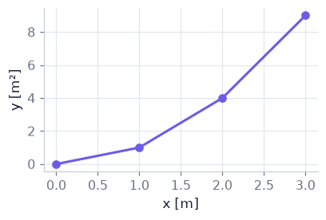

```python
import matplotlib.pyplot as plt                # matplotlib's plotting interface, used for every static figure
import logging                                 # standard library: controls library log messages
logging.getLogger("matplotlib.font_manager").setLevel(logging.ERROR)   # hide harmless font-substitution notes
x = [0, 1, 2, 3]                               # a few x values [m]
y = [0, 1, 4, 9]                               # y = x² at those points [m²]
fig, ax = plt.subplots(figsize=(3.6, 2.4))     # one small figure with one set of axes
ax.plot(x, y, marker="o")                      # draw the points joined by straight lines
ax.set_xlabel("x [m]")                         # label the horizontal axis, with its unit
ax.set_ylabel("y [m²]")                        # label the vertical axis, with its unit
plt.show()                                     # display the figure below the cell
```

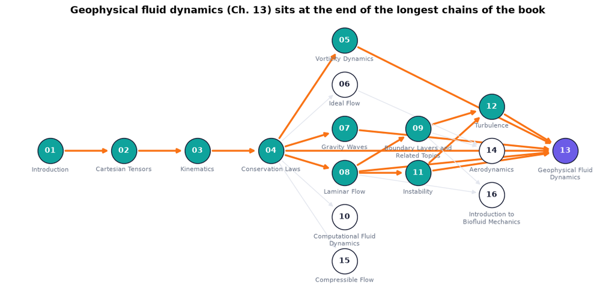

```python
from scripts.ch01_book_map import draw_book_map   # our drawing helper (pure matplotlib, no physics) from scripts/
fig, ax = plt.subplots(figsize=(10, 4.8))          # one wide figure for 16 chapter boxes
draw_book_map(ax, highlight=("ch13",))             # boxes = chapters, arrows = "builds on"; routes into Ch. 13 highlighted
import textwrap                                    # standard library: wraps long text onto several lines
from fluidpy.core.project import chapters          # the chapter list from book.yaml (titles)
full = {c["title"][:20] + "…": c["title"] for c in chapters()}   # the helper shortens long titles to 20 characters + "…"
for label in ax.texts:                             # every text drawn on the map
    if label.get_text() in full:                   # a shortened title …
        label.set_text(textwrap.fill(full[label.get_text()], 22))   # … gets its full title back, on two lines
ax.set_title("Geophysical fluid dynamics (Ch. 13) sits at the end of the longest chains of the book")  # the message
plt.show()                                         # display it
```

**What you see.** Sixteen chapter boxes arranged from foundations (left) to applications (right), with arrows meaning "this chapter needs that one". The routes that end in Chapter 13 (geophysical fluid dynamics) are highlighted.

**How to read it.** Follow the highlighted arrows backwards from Ch. 13: it rests directly on the conservation laws (Ch. 4), vorticity (Ch. 5), waves (Ch. 7), laminar flows (Ch. 8), instability (Ch. 11) and turbulence (Ch. 12) — and all of them rest on this chapter's vocabulary.

**What would change if…** Call `draw_book_map(ax, highlight=("ch15",))` instead: the compressible-flow chapter lights up, and its roots run straight back through Ch. 4 to the thermodynamics of §1.8–1.9.

## 1.2 Units of Measurement

**What is this section about?** SI units are school knowledge; we recap them once and let the `pint` library carry units through calculations, so every later number has its unit attached.

> 🔁 **Recap — SI base quantities and derived units** (pre-book, school physics; used again in C64). Four base quantities are enough for this book: length (m), mass (kg), time (s) and temperature (K). Everything else is built from them: newton N = kg m s⁻², pascal Pa = N m⁻², joule J = N m, watt W = J s⁻¹, hertz Hz = s⁻¹. So $[\mathrm{Pa}] = \mathrm{kg\,m^{-1}\,s^{-2}}$. **A unit is a product of powers of base units** — exactly the idea that §1.11 turns into dimensional analysis (C64).

> 📎 **Primer — pint quantities.** `P02` · `Q_(value, "unit")` attaches a unit to a number; `.to("Pa")` converts it; `.dimensionality` shows the powers of the base dimensions. Temperatures in °C are *offset* units (0 °C is not "no temperature"), so formulas always use kelvin.

```python
from fluidpy.core.units import Q_                          # Q_(value, "unit"): a number that carries its unit (pint)
print(Q_(1, "bar").to("Pa"))                               # 1 bar in pascals → 100000 pascal
w = Q_(1000, "kg/m**3") * Q_(9.81, "m/s**2") * Q_(10, "m") # ρ g z for 10 m of water: the units multiply as well
print(w.to("Pa"), "|", w.dimensionality)                   # 98100 pascal | [mass] / [length] / [time] ** 2
```

```
100000.0 pascal
98100.0 pascal | [mass] / [length] / [time] ** 2
```

> 📎 **Primer — numpy arrays.** `P03` · A numpy array holds many numbers, and arithmetic acts on all of them at once ("vectorised") — no loops needed.

```python
import numpy as np                     # numpy: fast arrays of numbers
T_C = np.array([0.0, 15.0, 100.0])     # three temperatures in °C, stored in one array
print(T_C + 273.15)                    # add 273.15 to every element at once → [273.15 288.15 373.15]
```

```
[273.15 288.15 373.15]
```

> 📎 **Primer — f-strings.** `P04` · `f"{x:.3g} Pa"` inserts the value of `x` into a string with 3 significant figures, followed by its unit; `{x:.1f}` gives one decimal.

```python
p = 101325.0                          # standard atmospheric pressure [Pa]
print(f"p = {p/1e3:.1f} kPa")         # p = 101.3 kPa  (divide by 1000, one decimal)
print(f"p = {p:.3g} Pa")              # p = 1.01e+05 Pa (three significant figures)
```

```
p = 101.3 kPa
p = 1.01e+05 Pa
```

> 🔁 **Recap — SI prefixes** (pre-book; used wherever a number is printed). Prefixes scale a unit by powers of ten — n 10⁻⁹, µ 10⁻⁶, m 10⁻³, k 10³, M 10⁶, G 10⁹. `pint` handles them, so hPa in §1.10, mN/m in §1.6 and nm in §1.4 need no hand conversion. A prefix changes the number, never the dimension.

> 🔁 **Recap — Celsius and kelvin** (pre-book; used in C40). $T_{[^\circ\mathrm C]} = T_{[\mathrm K]} - 273.15$. Laws such as $p = \rho R T$ need the **absolute** temperature: 15 °C is 288.15 K, and doubling the kelvin temperature (not the Celsius one) doubles $p$ at fixed $\rho$.

```python
from fluidpy import ch01_introduction as ch01                         # the tested chapter-1 module: every function cites its book section
T_K = ch01.celsius_to_kelvin(np.array([-40.0, 0.0, 15.0, 20.0]))     # four Celsius readings → kelvin in one call
print(T_K)                                                             # [233.15 273.15 288.15 293.15]
print(ch01.kelvin_to_celsius(288.15))                                  # and back: 15.0 °C
print(Q_(15, "degC").to("K"))                                          # pint knows °C is an offset unit → 288.15 kelvin
```

```
[233.15 273.15 288.15 293.15]
15.0
288.15 kelvin
```

**What does the code above do?**

1. Imports the chapter module as `ch01`; all physics of this notebook is called from it.
2. Converts four Celsius readings to kelvin at once (a numpy array in, an array out).
3. Converts 288.15 K back to °C.
4. Lets `pint` do the same conversion; it treats °C as an offset unit, so it converts correctly but refuses to multiply a °C value — one more reason to compute in kelvin.

## 1.3 Solids, Liquids, and Gases

**What is this section about?** What makes something a fluid (it cannot resist a shear stress by staying put), how fluids respond to being squeezed and pulled, and why gases and liquids differ (the spacing of their molecules).

> 📎 **Primer — stress.** `P05` · **Stress = force per area** [Pa]. On a surface it splits into a **normal** part (pushing or pulling across the surface) and a **shear** part (sliding along it). Shear turns a small cube into a leaning one; the lean angle γ [rad] is the **shear strain**, and how fast it grows, dγ/dt [1/s], is the **strain rate**.

```python
F_slide = 2.0            # sliding (tangential) force on a lid [N]
A_lid = 0.01             # lid area [m²] (10 cm × 10 cm)
print(F_slide / A_lid)   # shear stress = force / area → 200.0 Pa
```

```
200.0
```

📝 **Note.** **Fluid versus solid** `C02` — A solid under a small, steady shear stress τ leans to a fixed angle and stops: $\gamma = \tau/G$, where G [Pa] is its shear modulus (*gloss:* how stiff the solid is against shearing). A fluid **never stops**: any shear stress, however small, makes γ grow for as long as it acts — $\gamma = \tau t/\mu$ for the simple fluids of this book. The rate law behind the second formula is Newton's law of viscosity, developed in the C12 block of §1.5.

$$ \gamma_{\rm solid} = \tau/G \qquad \gamma_{\rm fluid} = \tau\,t/\mu $$

> 📎 **Primer — np.linspace and np.logspace.** `P06` · `np.linspace(a, b, n)` gives n evenly spaced numbers from a to b; `np.logspace(p, q, n)` gives n numbers from 10ᵖ to 10ᵠ that are evenly spaced on a logarithmic axis (the same factor between neighbours).

```python
print(np.linspace(0, 1, 5))      # [0.   0.25 0.5  0.75 1.  ] — equal steps
print(np.logspace(-9, -6, 4).tolist())   # [1e-09, 1e-08, 1e-07, 1e-06] — equal factors of 10
```

```
[0.   0.25 0.5  0.75 1.  ]
[1e-09, 1e-08, 1e-07, 1e-06]
```

Our drawing of the idea (in the spirit of the book's Fig. 1.1, `N02`): the same shear stress applied to a solid and to a fluid for 1.5 s, then removed.

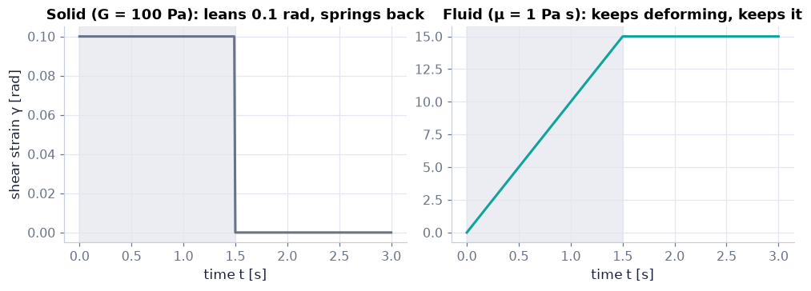

```python
from fluidpy.core.style import COLORS                              # the house palette shared with the explainers
t = np.linspace(0, 3, 301)                                          # time [s]; the stress acts from 0 to 1.5 s
gam_solid = ch01.shear_deformation_history(t, 10.0, "solid", G=100.0, t_off=1.5)  # γ = τ/G while loaded (τ = 10 Pa)
gam_fluid = ch01.shear_deformation_history(t, 10.0, "fluid", mu=1.0, t_off=1.5)   # γ = τt/μ while loaded (μ = 1 Pa s)
fig, (a, b) = plt.subplots(1, 2, figsize=(9, 3.2))                   # two panels: solid left, fluid right
for ax in (a, b):                                                    # same shading on both panels
    ax.axvspan(0, 1.5, color=COLORS["grid"], alpha=0.7)              # grey band = shear stress applied
    ax.set_xlabel("time t [s]")                                      # x label with unit
a.plot(t, gam_solid, color=COLORS["muted"])                          # the solid: jumps to a fixed lean, springs back
a.set_ylabel("shear strain γ [rad]")                                 # y label with unit
a.set_title("Solid (G = 100 Pa): leans 0.1 rad, springs back")      # the message of the left panel
b.plot(t, gam_fluid, color=COLORS["teal"])                           # the fluid: γ keeps growing while loaded
b.set_title("Fluid (μ = 1 Pa s): keeps deforming, keeps it")        # the message of the right panel
plt.show()                                                           # display
```

**What you see.** Left: the solid jumps to a lean of 0.1 rad while the stress (grey band) acts and returns to zero when it is removed. Right: the fluid's strain climbs steadily to 15 rad during the same 1.5 s and stays there afterwards.

**How to read it.** A flat line while loaded means an elastic solid; a rising line means a fluid. The slope of the rising line is the strain rate τ/μ = 10 s⁻¹ — exactly what Newton's law of viscosity (C12) will relate to the stress.

**What would change if…** Halve μ and the fluid's line rises twice as steeply (to 30 rad); the solid's panel would not change at all, because viscosity plays no role in an elastic solid.

📝 **Note.** **In-between materials** `N01` — Some materials sit in between: **plastic** (yield-stress) materials behave as solids until the stress passes a yield value, and **viscoelastic** ones (paint, egg white) partly spring back — non-Newtonian fluids, where Newton's law fails (Ch. 4 §4.5; blood in Ch. 16 §16.3).

📝 **Note.** **Normal stress: compression, tension and cavitation** `C03` — A normal stress can **push** (compression) or **pull** (tension). Solids and fluids both resist compression, but a liquid pulled hard enough breaks: when its pressure drops below the **vapour pressure** (*gloss:* the pressure at which the liquid boils at that temperature, ≈ 2.3 kPa for water at 20 °C) vapour cavities appear — **cavitation**, which eats ship propellers. On a surface with unit normal $\hat{\mathbf n}$ the normal stress is the part of the traction vector $\mathbf t$ (force per area on that surface) along $\hat{\mathbf n}$ (*gloss:* the dot product $\mathbf t\cdot\hat{\mathbf n}$ picks out the component of a vector along a unit vector). Pressure (C20) is the compressive normal stress of a fluid at rest. Number (code below): a traction (3, 4, 0) Pa on a surface facing x has σ_n = 3 Pa of tension and |τ| = 4 Pa of shear.

$$ \sigma_n = \mathbf t\cdot\hat{\mathbf n} $$

> 📎 **Primer — mole, kilomole, molecular weight and Avogadro's number.** `P07` · A kilomole (kmol) is 6.022×10²⁶ molecules — Avogadro's number per kilomole, A_o. The molecular weight M_w is the mass of one kilomole in kilograms (air 28.96 kg/kmol, water 18.02). So one molecule weighs m = M_w/A_o, and a gas or liquid of density ρ holds n = ρA_o/M_w molecules per m³. **This book uses kmol, not mol — a factor 1000 hides here.**

```python
A_o = 6.02214076e26               # Avogadro's number per kilomole [1/kmol]
print(28.9644 / A_o)              # mass of one air molecule m = M_w / A_o → 4.81e-26 kg
print(1.225 * A_o / 28.9644)      # molecules per m³ in sea-level air n = ρ A_o / M_w → 2.55e+25
```

```
4.8096517757250166e-26
2.5469619363770698e+25
```

📝 **Note.** **Liquid versus gas** `C04` — In a liquid the molecules touch their neighbours; in a gas they sit about ten molecule-sizes apart, so a gas is mostly empty space and easy to squeeze. A liquid poured into a container forms a **free surface**; a gas fills whatever space it is given. The typical spacing is $n^{-1/3}$ (one molecule per little cube): water ≈ 0.31 nm, sea-level air ≈ 3.4 nm — about 11 times more. How many molecules a sampling box holds is the question of C06.

$$ \ell_{\rm spacing} = n^{-1/3}, \qquad n = \rho A_o/M_w $$

```python
sig_n, tau_vec, tau_mag = ch01.traction_components([3.0, 4.0, 0.0], [1.0, 0.0, 0.0])  # C03: traction (3,4,0) Pa on a surface facing +x
print(f"normal stress {sig_n} Pa (positive = tension), shear {tau_mag} Pa")          # 3.0 Pa tension, 4.0 Pa shear
s_water = ch01.mean_molecular_spacing(998.0, 18.015)        # C04: spacing n^(-1/3) in liquid water [m]
s_air = ch01.mean_molecular_spacing(1.225, ch01.M_W_AIR)    # C04: spacing in sea-level air [m]
print(f"water {s_water:.2e} m, air {s_air:.2e} m, ratio {s_air/s_water:.0f}")        # 3.11e-10 m, 3.40e-09 m, ratio 11
```

```
normal stress 3.0 Pa (positive = tension), shear 4.0 Pa
water 3.11e-10 m, air 3.40e-09 m, ratio 11
```

**What does the code above do?**

1. `traction_components` splits a traction vector into its normal part (positive = pulling, tension) and its shear part — the C03 number.
2. `mean_molecular_spacing` computes n = ρA_o/M_w (primer P07) and returns n^(−1/3), for water and for air.
3. The ratio ≈ 11 is the "ten times farther apart" of C04.

## 1.4 Continuum Hypothesis

**What is this section about?** Why we may speak of density, velocity and temperature *at a point* although matter is made of molecules, and the test — the Knudsen number — that says when this picture fails.

### 🧩 The continuum hypothesis: a value at a point is the plateau of an average `C06`

*The question:* Matter is mostly empty space between molecules — so what can 'the density at this point' possibly mean?

#### The problem in plain words

A weather model stores one temperature per grid box; a pipe-flow formula uses the velocity *at* the wall. Zoom into either and you find molecules flying about with nothing in between. Yet every equation from Chapter 2 onward treats ρ, **u**, p and T as smooth functions of position. We need to know why that works — and when it stops working (microchannels, the upper atmosphere, aerosol particles).

#### The idea

Measure density by counting: put a box of side L around the point, weigh the molecules inside, divide by the box volume. Now grow the box and watch the reading.

```
box side L       1 nm       10 nm      100 nm     10 µm         1 mm          10 cm
molecules N      0.03       25         2.5e4      2.5e10        2.5e16        2.5e22
relative noise    —         20 %       0.6 %      6e-6          6e-9          —
reading          0 or huge  noisy      settling   ───── plateau ─────        drifts with the flow
                 └─ molecular noise ─┘            └─ continuum window ─┘     └─ flow's own variation ─┘
```

**The density at a point is the plateau value.** It exists because a wide range of box sizes lies between the molecular scale and the scale on which the flow itself changes.

> 📎 **Primer — temperature as molecular kinetic energy.** `P08` · Temperature measures the mean random kinetic energy of the molecules: $\tfrac12 m\langle|\mathbf u|^2\rangle = \tfrac32 k_B T$, with Boltzmann's constant $k_B = 1.380649\times10^{-23}$ J/K. Hotter gas = faster molecules.

```python
m_air = ch01.molecular_mass(ch01.M_W_AIR)              # mass of one air molecule [kg] (primer P07)
print(np.sqrt(3 * ch01.K_B * 288.15 / m_air))          # rms speed sqrt(3 k_B T / m) at 15 °C → ≈ 498 m/s
```

```
498.1438392740687
```

> 📎 **Primer — Newton's second law and momentum.** `P09` · Momentum = mass × velocity [kg m/s]. Newton's second law: the net force on a body equals the rate of change of its momentum (F = ma for a fixed mass). Draw every force acting on the body (a **free-body diagram**), add them with their signs, and set the sum equal to m a. By the third law, whatever momentum the body gains, whatever pushed it loses.

```python
m_ball, v_in, v_out = 0.1, 2.0, -2.0      # a 0.1 kg ball hits a wall at 2 m/s and bounces straight back
dP = m_ball * v_in - m_ball * v_out       # momentum handed to the wall = 0.2 − (−0.2) = 0.4 kg m/s
print(dP, dP / 0.01)                      # delivered in 0.01 s → average force 40 N
```

```
0.4 40.0
```

> 📎 **Primer — np.random.default_rng.** `P10` · `rng = np.random.default_rng(0)` makes a *seeded* random-number generator: the same "random" numbers on every run, so results are reproducible. `rng.normal(0, s, n)` draws n Gaussian numbers with standard deviation s; `rng.poisson(lam, n)` draws n random counts with mean lam; `rng.random((n, 3))` draws uniform numbers in [0, 1).

```python
rng = np.random.default_rng(0)                  # seeded generator → reproducible numbers
print(rng.normal(0, 2, 100_000).std())          # ≈ 2.0: the spread we asked for
print(rng.poisson(100, 100_000).std())          # ≈ 10: counts with mean 100 scatter by about √100
```

```
2.0002570081062894
9.96941698190521
```

> 📎 **Primer — Gaussian velocity components and mean square speed.** `P11` · In a gas at rest each velocity component ($u_x$, $u_y$, $u_z$) is Gaussian with zero mean and variance $k_BT/m$. The mean square speed adds the three: $\langle|\mathbf u|^2\rangle = \langle u_x^2\rangle + \langle u_y^2\rangle + \langle u_z^2\rangle = 3\langle u_x^2\rangle$, because no direction is special.

```python
u = ch01.maxwellian_velocities(100_000, 288.15, m_air, seed=0)   # 100 000 molecules' velocities [m/s], shape (100000, 3)
print((u**2).sum(axis=1).mean() / (u[:, 0]**2).mean())           # ⟨|u|²⟩ / ⟨u_x²⟩ → ≈ 3.0
```

```
2.989523450802973
```

📝 **Note.** **Pressure is momentum delivered by molecular impacts** `C05` — Molecules hitting a wall bounce back, and every bounce pushes the wall. On each square metre of a wall in sea-level air there are about 10²⁷ impacts per second, so their average push per area is perfectly steady — that average is the pressure. The derivation below turns this picture into a formula.

$$ p = \tfrac13\,n\,m\,\langle|\mathbf u|^2\rangle $$

#### 🧮 Derivation — Pressure from molecular impacts (kinetic theory behind §1.4; our addition)

**What we want to show.** Turn "pressure is the average push of molecules hitting a wall" into a formula, and see that it gives the gas law pV = nk_BT used in §1.9.

**Assumptions.** Ideal gas: molecules do not interact except by brief collisions (step 2: straight flight to the wall) · an elastic, smooth wall (step 1) · isotropic velocities, gas at rest (steps 5–7) · equilibrium, so the kinetic meaning of T applies (step 8).

**The plan.**

1. Find the momentum one bounce gives the wall.
2. Count how many molecules of one velocity hit in a time dt.
3. Add over all velocities.
4. Use isotropy and the kinetic meaning of temperature.

**Tools we use** (each explained before this point): Newton's second law and momentum (P09) · Gaussian velocity components and mean square speed (P11) · temperature as molecular kinetic energy (P08)

**We start from**

$$ p = \dfrac{\text{momentum delivered to the wall}}{\text{area} \times \text{time}} $$

*In words:* force is momentum per time (Newton), and pressure is force per area.

**Step 1 of 8 — Momentum given by one bounce.**

$$ \Delta P_{\rm wall} = 2\,m\,u_x $$

- *Why we can do this:* An elastic bounce off a smooth wall normal to x reverses u_x and keeps u_y, u_z; the molecule's momentum changes by −2mu_x, so by Newton's third law the wall gains +2mu_x. This is the push we want to count.
- *In words:* Each hit hands the wall twice the molecule's normal momentum.

**Step 2 of 8 — Count hits of one velocity class in time dt.**

$$ dN = n_{u_x}\,A\,u_x\,dt \quad (u_x > 0) $$

- *Why we can do this:* Only molecules moving toward the wall (u_x > 0) and within a distance u_x dt of it arrive in dt: they fill a slab of volume A u_x dt, and n_{u_x} is the number per volume with that velocity.
- *In words:* Faster molecules reach the wall from farther away.

**Step 3 of 8 — Multiply hits by momentum per hit.**

$$ dP = 2\,m\,n_{u_x}\,u_x^2\,A\,dt $$

- *Why we can do this:* Total momentum = number of hits × momentum per hit (steps 1 and 2); u_x appears twice, once from how many arrive and once from how hard each hits.
- *In words:* The delivered momentum grows with the square of the speed.

**Step 4 of 8 — Divide by area and time.**

$$ p_{u_x} = 2\,m\,n_{u_x}\,u_x^2 $$

- *Why we can do this:* Force = momentum per time (P09), pressure = force per area; dividing by A dt gives this velocity class's share of the pressure.
- *In words:* One velocity class adds this much pressure.

**Step 5 of 8 — Add all classes moving toward the wall.**

$$ p = 2m\sum_{u_x>0} n_{u_x}u_x^2 = 2m\cdot\tfrac{n}{2}\langle u_x^2\rangle $$

- *Why we can do this:* By symmetry half of the n molecules per volume move toward the wall, and those have the same mean square u_x as the whole gas. We sum because pressure is the total push.
- *In words:* The half of the molecules heading for the wall carry the average square speed.

**Step 6 of 8 — Cancel the 2 and the ½.**

$$ p = n\,m\,\langle u_x^2\rangle $$

- *Why we can do this:* 2 × ½ = 1; nothing else changes, and the formula now uses only averages over the whole gas.
- *In words:* Pressure is number density × mass × mean square normal velocity.

**Step 7 of 8 — Replace ⟨u_x²⟩ using isotropy.**

$$ p = \tfrac13\,n\,m\,\langle|\mathbf u|^2\rangle $$

- *Why we can do this:* In a gas at rest no direction is special, so ⟨u_x²⟩ = ⟨u_y²⟩ = ⟨u_z²⟩ and their sum is ⟨|u|²⟩ (P11); hence ⟨u_x²⟩ = ⅓⟨|u|²⟩. We want the speed, not one component.
- *In words:* Pressure is one third of density times mean square speed.

**Step 8 of 8 — Use the kinetic meaning of temperature.**

$$ p = n\,k_B\,T $$

- *Why we can do this:* ½m⟨|u|²⟩ = (3/2)k_BT (P08), so m⟨|u|²⟩ = 3k_BT and the ⅓ cancels the 3. This links the molecular picture to a measurable temperature.
- *In words:* Pressure = molecules per volume × k_B × temperature.

**Result**

$$ p = \tfrac13\,n\,m\,\langle|\mathbf u|^2\rangle = n\,k_B T $$

*In words:* multiplying by a volume V with n = N/V gives $pV = N k_B T$ — the molecular gas law $pV = n\,k_B T$ (1.21) stated in C38, with n there counting molecules.

**What it means.** A steady pressure is the average of an enormous number of tiny, random pushes — which is why it is well defined only for boxes holding many molecules (D35 below). Heating a gas at fixed n raises p because molecules hit harder and more often. The formula fails for dense gases and liquids, where molecules interact during their whole flight.

**Check it.** Units: m⁻³ · kg · m² s⁻² = kg m⁻¹ s⁻² = Pa ✓. Number: sea-level air, n = 2.55×10²⁵ m⁻³, m = 4.81×10⁻²⁶ kg, ⟨|u|²⟩ = 3k_BT/m = 2.48×10⁵ m²/s² → p = ⅓ × 2.55×10²⁵ × 4.81×10⁻²⁶ × 2.48×10⁵ = 1.013×10⁵ Pa ✓. The next code cell samples molecules and gets within 2 % of nk_BT both ways.

> ⚠️ **Common confusion (traps in this derivation):** losing the factor 2 of the bounce; forgetting that only half the molecules move toward the wall; using ⟨u_x²⟩ = ⟨|u|²⟩ instead of ⅓⟨|u|²⟩.

```python
n_air = ch01.number_density(1.225, ch01.M_W_AIR)           # molecules per m³ in sea-level air, n = ρ A_o / M_w [1/m³]
N_mol = 200_000 if not FAST else 50_000                    # how many molecules we sample (fewer in FAST mode)
u = ch01.maxwellian_velocities(N_mol, 288.15, m_air, seed=0)  # their random velocities at 288.15 K [m/s], shape (N, 3)
p_kin = ch01.molecular_pressure(n_air, m_air, u)           # D34 step 7: p = ⅓ n m ⟨|u|²⟩ from the sample [Pa]
p_wall = ch01.wall_impact_pressure(u, m_air, n_air)        # D34 steps 1–5: count wall hits in a short time, add 2 m u_x [Pa]
p_nkT = n_air * ch01.K_B * 288.15                          # D34 step 8: p = n k_B T [Pa]
print(f"n k_B T = {p_nkT:,.0f} Pa")                        # ≈ 101 327 Pa: sea-level pressure from molecules
print(f"⅓ n m <|u|²> = {p_kin:,.0f} Pa  (ratio {p_kin/p_nkT:.3f})")      # within sampling scatter of 1
print(f"wall impacts = {p_wall:,.0f} Pa  (ratio {p_wall/p_nkT:.3f})")    # within sampling scatter of 1
```

```
n k_B T = 101,327 Pa
⅓ n m <|u|²> = 101,548 Pa  (ratio 1.002)
wall impacts = 102,553 Pa  (ratio 1.012)
```

**What does the code above do?**

1. `number_density` and `molecular_mass` (primer P07) give n and m for air.
2. `maxwellian_velocities` draws Gaussian velocity components with variance k_BT/m (primers P10, P11).
3. `molecular_pressure` evaluates step 7 of D34 on the sample.
4. `wall_impact_pressure` literally counts the molecules that would reach a wall in a short time and adds their 2mu_x — steps 1–5.
5. Step 8, p = nk_BT, is the exact value; both sampled estimates agree with it to within their random scatter.

> 📎 **Primer — Poisson counting statistics.** `P12` · When very many independent things each have a small chance to land in a box, the count N is **Poisson**: its variance equals its mean $\bar N$, so its standard deviation is $\sqrt{\bar N}$ and its **relative** scatter is $1/\sqrt{\bar N}$.

```python
rng = np.random.default_rng(0)            # seeded generator (primer P10)
c = rng.poisson(25, 100_000)              # 100 000 boxes that expect 25 molecules each
print(c.std() / c.mean(), 1 / np.sqrt(25))   # measured relative scatter ≈ 0.20 = 1/√25
```

```
0.20017823329989554 0.2
```

> 📎 **Primer — power laws and log–log plots.** `P13` · $y = a\,x^k$ is a straight line of slope k on log–log axes (`ax.loglog`), because $\log y = \log a + k\log x$. So the slope you read off a log–log plot is the exponent; `np.polyfit(log x, log y, 1)[0]` measures it.

```python
x = np.logspace(0, 3, 4)                                   # 1, 10, 100, 1000
y = 5 * x**-1.5                                            # a power law with exponent −1.5
print(np.polyfit(np.log10(x), np.log10(y), 1)[0])          # slope of the straight line on log–log axes → −1.5
```

```
-1.5000000000000002
```

> 📎 **Primer — exponent rules.** `P43` · $a^m a^n = a^{m+n}$; $(a^m)^n = a^{mn}$; $a^{-m} = 1/a^m$; $(a/b)^m = a^m/b^m$; and $(ab)^m = a^m b^m$. For example $(L^3)^{-1/2} = L^{-3/2}$.

```python
print(2.0**0.4 * 2.0**1.0, 2.0**1.4)            # a^m a^n = a^(m+n): both 2.639
print((2.0**0.5)**2, 1 / 2.0**-1.4, 2.0**1.4)   # (a^m)^n = a^(mn) and a^(−m) = 1/a^m
print((3.0 * 4.0)**-0.5, 3.0**-0.5 * 4.0**-0.5) # (ab)^k = a^k b^k: both 0.2887
```

```
2.6390158215457884 2.6390158215457884
2.0000000000000004 2.6390158215457884 2.6390158215457884
0.28867513459481287 0.28867513459481287
```

#### The maths, step by step

1. Around a point **x** take a small volume δV [m³] holding a mass δm [kg].
2. Define the continuum density as the ratio $\rho(\mathbf x) = \delta m/\delta V$ (§1.4).
3. The ratio is useful only if δV holds so many molecules that the scatter of the count is negligible (**lower bound**, worked out in D35 below) **and** δV is so small that the flow's own density does not change across it (**upper bound**, set by the flow's length scale L_flow [m]).
4. Every field variable of the book — **u**, p, T — is defined the same way, as a plateau average.

Symbols: n [m⁻³] molecules per volume; m [kg] mass of one molecule; $\bar N = n\,\delta V$ the expected count; ε [–] the fractional amplitude of the flow's own density variation.

#### 🧮 Derivation — How noisy is a density measured in a small box? (§1.4; our addition)

**What we want to show.** Find how the scatter of a box's density reading depends on the box size — the lower end of the continuum window.

**Assumptions.** Molecules placed independently (ideal gas; step 1) · the box holds a tiny fraction of all molecules (step 1: Poisson limit) · the macroscopic density does not vary across the box (step 3; the flow's variation is the separate upper bound).

**The plan.**

1. The molecule count is Poisson.
2. Scale its scatter into a density scatter.
3. Divide by the mean.
4. Write the result in terms of L.

**Tools we use** (each explained before this point): Poisson counting statistics (P12) · power laws and log–log plots (P13) · exponent rules (P43)

**We start from**

$$ \bar N = n\,\delta V = n\,L^3 $$

*In words:* a box of side L in a gas with n molecules per m³ holds N̄ molecules on average.

**Step 1 of 5 — Use Poisson statistics for the count.**

$$ \operatorname{Var}(N) = \bar N $$

- *Why we can do this:* Each of very many independent molecules has a tiny chance to be inside the box; such counts are Poisson, whose variance equals the mean (P12). This is where the randomness enters.
- *In words:* The count scatters by about √N̄.

**Step 2 of 5 — Take the square root.**

$$ \sigma_N = \sqrt{\bar N} $$

- *Why we can do this:* The standard deviation is by definition the square root of the variance, and it has the units of the count.
- *In words:* A box expecting 100 molecules typically sees 90 to 110.

**Step 3 of 5 — Turn counts into densities.**

$$ \sigma_\rho = \dfrac{m\,\sigma_N}{L^3},\qquad \rho = \dfrac{m\bar N}{L^3} $$

- *Why we can do this:* The reading is δm/δV = mN/L³ (C06); multiplying a random number by the constant m/L³ multiplies both its mean and its standard deviation by that constant.
- *In words:* The density reading inherits the count's scatter.

**Step 4 of 5 — Divide by the mean.**

$$ \dfrac{\sigma_\rho}{\rho} = \dfrac{\sigma_N}{\bar N} = \bar N^{-1/2} $$

- *Why we can do this:* m/L³ cancels; √N̄/N̄ = N̄^(−1/2). A *relative* scatter is what decides whether a value is usable.
- *In words:* The relative noise is one over the square root of the expected count.

**Step 5 of 5 — Write it in terms of the box side.**

$$ \dfrac{\sigma_\rho}{\rho} = (nL^3)^{-1/2} = n^{-1/2}L^{-3/2} $$

- *Why we can do this:* Substitute N̄ = nL³ and use (ab)^k = a^k b^k and (L³)^(−1/2) = L^(−3/2). The exponent is the slope on a log–log plot (P13).
- *In words:* Every factor 10 in box side cuts the noise by 10^1.5 ≈ 32.

**Result**

$$ \dfrac{\sigma_\rho}{\rho} = (n\,L^3)^{-1/2} $$

*In words:* the relative noise of a box density falls as the box side to the power −3/2.

**What it means.** The continuum's lower limit is statistical: a density exists once a box holds, say, 10⁶ molecules (noise 0.1 %), i.e. L ≈ 0.3 µm in sea-level air. In a liquid the molecules are not independent (they touch), so the true scatter is smaller than Poisson and this estimate is an upper bound. In the explainer below, the grey band's half-width at the marker is exactly this number.

**Check it.** Dimensionless ✓ (nL³ is a count). Limits: L → 0 gives infinite noise (a box with no molecules), L → ∞ gives zero ✓. Number: a 10 µm cube of air, N̄ = 2.55×10¹⁰ → 6.3×10⁻⁶ ✓; the sweep below follows a line of slope −1.5, and a from-scratch molecule count agrees within its statistical scatter.

> ⚠️ **Common confusion (traps in this derivation):** writing L^(−1/2) (it is the volume, not the side, under the root); confusing the absolute scatter σ_ρ with the relative scatter σ_ρ/ρ.

#### ✏️ Tiny example: a 10 µm cube of sea-level air

1. n = ρA_o/M_w = 1.225 × 6.022×10²⁶ / 28.96 = 2.55×10²⁵ m⁻³.
2. δV = (10⁻⁵ m)³ = 10⁻¹⁵ m³.
3. N̄ = nδV = 2.55×10¹⁰ molecules.
4. δm = N̄m = 2.55×10¹⁰ × 4.81×10⁻²⁶ kg = 1.225×10⁻¹⁵ kg, so δm/δV = 1.225 kg/m³.
5. Relative noise 1/√N̄ = 1/(1.6×10⁵) = 6.3×10⁻⁶ — utterly negligible.
6. The same air in a 10 nm cube: N̄ = 25, noise = 1/5 = 20 % — no useful density at all.

> 📎 **Primer — tuple unpacking.** `P14` · A function may return several values packed in a tuple; `a, b = f()` unpacks them into two names in one line.

```python
result = (1.225, 0.01)       # a function result with two values: (mean, standard deviation)
mean, std = result           # unpack them into two names
print(mean, std)             # 1.225 0.01
```

```
1.225 0.01
```

```python
L = np.logspace(-9, 0, 37 if not FAST else 19)                  # box sides from 1 nm to 1 m, evenly spaced in log [m]
eps, L_flow = 0.2, 1.0                                          # the flow's density varies ±20 % over 1 m
mean, std = ch01.sample_density(L, n_air, m_air, n_samples=200 if not FAST else 60,   # sampled box densities (continued below)
                                variation=eps, L_flow=L_flow, seed=0)  # 200 random boxes per size: mean and std [kg/m³]
rel = std / mean                                                # measured relative scatter [–]
noise = ch01.density_noise_expected(L, n_air)                   # D35 prediction (n L³)^(-1/2) [–]
rho_pt = 1.225 * (1 + eps)                                      # the density AT the point (the box sits on a crest) [kg/m³]
box_avg = ch01.box_average_density(L, 1.225, eps, L_flow)       # the noiseless box average: blurs the variation [kg/m³]
drift = np.abs(box_avg / rho_pt - 1)                            # how far the box average has drifted from the point value
for Lq in (1e-8, 1e-5, 1e-1):                                   # three sizes: tiny, window, too big
    i = np.argmin(np.abs(np.log10(L / Lq)))                     # index of the nearest box size in the sweep
    print(f"L = {L[i]:.0e} m: measured noise {rel[i]:.2e}, D35 {noise[i]:.2e}, drift {drift[i]:.1e}")   # one table row
```

```
L = 1e-08 m: measured noise 1.78e-01, D35 1.98e-01, drift 0.0e+00
L = 1e-05 m: measured noise 5.87e-06, D35 6.27e-06, drift 2.7e-11
L = 1e-01 m: measured noise 5.46e-12, D35 6.27e-12, drift 2.7e-03
```

**What does the code above do?**

1. Builds 37 box sizes from 1 nm to 1 m (primer P06).
2. `sample_density` places 200 random boxes per size in air whose density varies by ±20 % over 1 m, draws each box's molecule count as in D35 around the box average, and returns the mean and standard deviation of the readings (tuple unpacking, primer P14).
3. `rel` is the measured relative scatter and `noise` the D35 prediction — they agree.
4. `box_average_density` is the average of the flow's smooth variation over the box (a sinusoid averaged over a box gives the factor sinc(πL/L_flow) = sin(πL/L_flow)/(πL/L_flow)); `drift` measures how far it has moved from the value at the point.
5. The table: at 10 nm the noise dominates, at 10 µm both are negligible (the plateau), at 10 cm the drift has grown.

> 📎 **Primer — assert np.allclose.** `P15` · `assert np.allclose(a, b, rtol=…)` stops the notebook with an error if two numbers or arrays differ by more than the relative tolerance `rtol`. We use it as proof that a hand-written version matches the tested library.

```python
assert np.allclose([1.0, 2.0], [1.0, 2.0 + 1e-9])   # passes silently: equal to within the default tolerance
print("the two arrays agree")                        # reached only if the assert passed
```

```
the two arrays agree
```

#### From scratch: place molecules and count them

The library draws counts from the Poisson law. Here we do it the naive way — scatter molecules uniformly in a unit cube, drop random boxes into it and count what falls inside — and check that the relative scatter follows D35.

```python
rng = np.random.default_rng(1)                               # seeded generator (primer P10)
n_mol = 100_000 if not FAST else 40_000                      # molecules in the unit cube → number density n = n_mol per m³
pos = rng.random((n_mol, 3))                                 # their positions, uniform in [0, 1)³ [m]
n_boxes = 300 if not FAST else 120                           # how many random boxes per size
for b in (0.05, 0.1, 0.2):                                   # three box sides [m]
    corners = rng.random((n_boxes, 3)) * (1 - b)             # random lower corners that keep the box inside the cube
    counts = np.array([np.all((pos >= c) & (pos < c + b), axis=1).sum() for c in corners])  # molecules inside each box
    rel_mine = counts.std(ddof=1) / counts.mean()            # measured relative scatter of the count (= of the density)
    rel_d35 = ch01.density_noise_expected(b, n_mol)          # D35: (n b³)^(-1/2)
    m_lib, s_lib = ch01.sample_density(b, n_mol, 1.0, n_samples=n_boxes)   # the library's sampler, molecule mass 1 kg
    print(f"b = {b}: N̄ = {n_mol*b**3:.0f}, mine {rel_mine:.3f}, D35 {rel_d35:.3f}, library {s_lib/m_lib:.3f}")   # compare the three estimates
    assert np.allclose(rel_mine, rel_d35, rtol=0.25)         # both random: agreement within the statistical scatter
    assert np.allclose(rel_mine, s_lib / m_lib, rtol=0.25)   # the library's sampler behaves like real counting
```

```
b = 0.05: N̄ = 13, mine 0.294, D35 0.283, library 0.280
```

```
b = 0.1: N̄ = 100, mine 0.102, D35 0.100, library 0.102
```

```
b = 0.2: N̄ = 800, mine 0.036, D35 0.035, library 0.036
```

Statistical agreement (to 25 %) is the right test here: both sides are random, and the scatter of a standard deviation estimated from a few hundred boxes is several per cent. The deterministic law is D35.

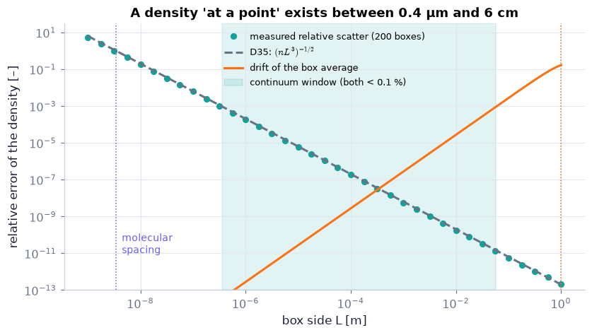

```python
from fluidpy.core.style import savefig                                  # saves a copy to outputs/ch01/ (not committed)
fine = np.logspace(-9, 0, 400)                                          # a fine grid of box sides for the smooth curves [m]
noise_f = ch01.density_noise_expected(fine, n_air)                      # D35 line (slope −3/2 on log–log axes)
drift_f = np.abs(ch01.box_average_density(fine, 1.225, eps, L_flow) / rho_pt - 1)  # drift of the box average
ok = (noise_f < 1e-3) & (drift_f < 1e-3)                                # the continuum window: both below 0.1 %
fig, ax = plt.subplots(figsize=(7.5, 4.2))                              # one log–log panel
ax.loglog(L, rel, "o", color=COLORS["teal"], ms=5, label="measured relative scatter (200 boxes)")   # the samples
ax.loglog(fine, noise_f, "--", color=COLORS["muted"], label=r"D35: $(nL^3)^{-1/2}$")                # prediction
ax.loglog(fine[drift_f > 1e-16], drift_f[drift_f > 1e-16], color=COLORS["orange"], label="drift of the box average")   # drift (zeros hidden on a log axis)
ax.axvspan(fine[ok][0], fine[ok][-1], color=COLORS["teal"], alpha=0.12, label="continuum window (both < 0.1 %)")   # shade the window
ax.axvline(s_air, color=COLORS["accent"], lw=1, ls=":")                 # molecular spacing of air (3.4 nm)
ax.text(s_air * 1.3, 1e-11, "molecular\nspacing", color=COLORS["accent"], fontsize=9)   # label the spacing line
ax.axvline(L_flow, color=COLORS["orange"], lw=1, ls=":")                # the flow's length scale (1 m)
ax.set_ylim(1e-13, 30)                                                  # fixed range so all three regimes show
ax.set_xlabel("box side L [m]")                                         # x label with unit
ax.set_ylabel("relative error of the density [–]")                      # y label (dimensionless)
ax.set_title(f"A density 'at a point' exists between {fine[ok][0]*1e6:.1f} µm and {fine[ok][-1]*100:.0f} cm")   # the message, with the window's edges
ax.legend(loc="upper center", fontsize=8.5)                             # legend in the empty upper middle
savefig(fig, "ch01", "c06_continuum_window")                            # keep a copy for review
plt.show()                                                              # display
```

**What you see.** Teal dots (measured scatter) lying on a grey dashed line of slope −3/2, an orange curve rising at the right, and a shaded window about five decades wide where both are below 10⁻³.

**How to read it.** Inside the shaded window any box gives the same density to better than 0.1 % — that shared number is ρ(**x**). Left of it the reading is dominated by molecular noise; right of it the box is so big that it averages over the flow's own variation, and the "value at the point" gets blurred. The window's width, not molecules being absent, is what makes the continuum description work.

**What would change if…** In water n is ≈ 1300× larger, so the grey line drops by √1300 ≈ 36 and the window starts about 11× smaller boxes. In a thin boundary layer (the thin layer next to a wall where the flow speed changes quickly; L_flow = 1 mm) the orange curve moves three decades to the left and the window shrinks from the right.

> 📎 **Primer — animate and show_animation.** `P16` · `animate(update, frames=n, fig=fig)` calls your function `update(i)` once for every frame number i; `update` moves artists that are already drawn (with `set_data`, `set_offsets`, `set_text` …). `show_animation(anim, player="frames")` embeds it with ◀ ▮▮ ▶ step buttons; `player="video"` makes a smooth MP4.

```python
from fluidpy.core.anim import animate               # builds a matplotlib animation from an update function
fig, ax = plt.subplots(figsize=(3.2, 1.4))          # a tiny figure
(dot,) = ax.plot([0], [0], "o", color=COLORS["accent"])   # draw the first frame once: a dot at x = 0
ax.set_xlim(-0.5, 9.5); ax.set_ylim(-1, 1)          # fixed axes, so only the dot moves
def update(i):                                      # called for frames i = 0 … 9
    dot.set_data([i], [0])                          # move the dot to x = i
    return (dot,)                                   # the changed artist
show_animation(animate(update, frames=10, fig=fig, interval=200), player="frames")   # step through the 10 frames
```

[figure not shown]

Once Loop Reflect

```python
from fluidpy.core.anim import animate                                     # animation helper (primer P16)
frames = 37 if not FAST else 19                                           # one frame per quarter decade of box size
L_anim = np.logspace(-9, 0, frames)                                       # box side for each frame [m]
import warnings                                                           # standard library: silence expected warnings
with warnings.catch_warnings():                                           # a 1-box "standard deviation" is undefined …
    warnings.simplefilter("ignore", RuntimeWarning)                       # … so numpy warns; we only use the mean
    reading = np.array([ch01.sample_density(Li, n_air, m_air, n_samples=1, variation=eps, L_flow=L_flow, seed=i)[0]   # (continued)
                        for i, Li in enumerate(L_anim)])                  # ONE random box reading per size [kg/m³]
fig, (axl, axr) = plt.subplots(1, 2, figsize=(8.4, 3.5), gridspec_kw=dict(width_ratios=[1, 1.35]))   # left: the gas, right: the readings
axl.set_xticks([]); axl.set_yticks([]); axl.set_aspect("equal")          # left: a slice of the gas, 4 box sides wide
field = axl.imshow(np.zeros((2, 60)), extent=(-2, 2, -2, 2), vmin=1.0, vmax=1.5, cmap="Blues", origin="lower")   # the smooth density field (blank at first)
dots = axl.scatter([], [], s=6, color=COLORS["ink"])                      # molecules (only while few enough to draw)
axl.add_patch(plt.Rectangle((-0.5, -0.5), 1, 1, fill=False, ec=COLORS["accent"], lw=2))   # the sampling box
label = axl.set_title("")                                                 # shows L and the expected count
axr.axhline(rho_pt, color=COLORS["muted"], ls="--", lw=1)                 # the density at the point (1.47 kg/m³)
axr.text(2e-9, rho_pt + 0.05, "value at the point", color=COLORS["muted"], fontsize=8)   # label the dashed line
(trace,) = axr.semilogx([], [], "-", color=COLORS["teal"], lw=1)          # readings so far
(now,) = axr.semilogx([], [], "o", color=COLORS["orange"], ms=9)          # the current reading, enlarged
axr.set_xlim(5e-10, 2); axr.set_ylim(0, 3)                                # fixed axes (readings above 3 are clipped)
axr.set_xlabel("box side L [m]"); axr.set_ylabel("one box reading δm/δV [kg/m³]")   # axis labels with units
rng_anim = np.random.default_rng(3)                                       # seeded positions for the dots
def update(i):                                                            # frame i: box side L_anim[i]
    Li = L_anim[i]                                                        # current box side [m]
    n_view = n_air * (4 * Li)**2 * Li                                     # expected molecules in the drawn slice (4L × 4L × L)
    if n_view < 2000:                                                     # few enough: draw them as dots
        k = rng_anim.poisson(n_view)                                      # how many fall in the slice this time
        dots.set_offsets(rng_anim.uniform(-2, 2, (k, 2)))                 # random positions in box units
        field.set_data(np.full((2, 60), np.nan))                          # no smooth field yet
    else:                                                                 # too many: show the smooth density field instead
        dots.set_offsets(np.empty((0, 2)))                                # hide the dots
        x = L_flow / 4 + np.linspace(-2, 2, 60) * Li                      # positions across the view [m] (centred on a crest)
        field.set_data(np.tile(1.225 * (1 + eps * np.sin(2 * np.pi * x / L_flow)), (2, 1)))   # ρ(x) of the flow
    label.set_text(f"L = {Li:.1e} m, expected N = {n_air*Li**3:.2g}")    # title with the numbers
    trace.set_data(L_anim[:i + 1], np.minimum(reading[:i + 1], 2.95))     # readings so far (clipped at the top)
    now.set_data([Li], [min(reading[i], 2.95)])                           # the current one
    return dots, field, trace, now, label   # the artists that changed
show_animation(animate(update, frames=frames, fig=fig, interval=350), player="frames")   # step decade by decade
```

[figure not shown]

Once Loop Reflect

**What does the code above do?**

1. Frame i sets the box side L = 10^(−9 + i/4) m; `sample_density(..., n_samples=1)` gives one random reading per size.
2. Left panel: while the drawn slice would hold fewer than 2000 molecules they are drawn as dots; after that the slice shows the flow's smooth density field (it only varies visibly once L approaches the 1 m flow scale).
3. Right panel: the reading so far, with the current one enlarged; readings larger than 3 kg/m³ are clipped at the top.

**What you see.** Dots and a wildly jumping reading (zero, or far off the top) for nanometre boxes; then the dots become too many to draw and the reading settles onto the dashed line; in the last frames the reading slides down as the box spans the flow's own variation.

**How to read it.** The moment the molecules become too many to draw is roughly where the reading stops jumping — beyond it you are in the continuum window.

**What would change if…** the flow had no density variation (ε = 0): the right end would stay flat on the line forever, and the only limit would be the molecular one.

> 📎 **Primer — slider_figure.** `P17` · `slider_figure(fn, name, values)` calls `fn(value)` for every slider position **now**, in Python, and stores all the curves in one plotly figure. Dragging the slider just switches which curves are visible — so it keeps working on the published web page without any Python running. `fn` returns `{trace name: (x, y)}`.

```python
from fluidpy.core.interact import slider_figure                       # precomputed-slider plotly figures
xs = np.linspace(0, 1, 11)                                            # x values
fig = slider_figure(lambda a: {"y = a·x": (xs, a * xs)}, "a", [1, 2, 3],   # fn, name, values …
                    xlabel="x [–]", ylabel="y [–]", title="Drag a: the slope changes", height=320)   # 3 slider steps
fig.show()                                                            # interactive figure below the cell
```

[interactive chart not shown]

```python
z_alt = np.linspace(0, 80e3, 17)                                          # 17 geopotential altitudes from 0 to 80 km [m]
L_body = np.logspace(-9, 1, 120)                                          # body or channel sizes from 1 nm to 10 m [m]
def kn_curves(z_km):                                                      # called once per slider position (altitude in km)
    T, p, rho = ch01.standard_atmosphere(z_km * 1e3)                      # US Standard Atmosphere 1976 at that geopotential height
    l = ch01.mean_free_path_air(T, p)                                     # mean free path of air there [m] (Jennings)
    return {"Kn = l/L": (L_body, ch01.knudsen_number(l, L_body)),        # Knudsen number for every body size
            "Kn = 0.01 (continuum limit)": (L_body[[0, -1]], [0.01, 0.01]),   # guide line
            "Kn = 0.1 (slip → transition)": (L_body[[0, -1]], [0.1, 0.1])}    # guide line
fig = slider_figure(kn_curves, "altitude", z_alt / 1e3, unit="km", xlabel="body size L [m]", ylabel="Kn [–]",   # one slider position per altitude
                    title="The continuum fails for smaller and smaller bodies as the air thins", active=0)   # start at sea level
fig.update_xaxes(type="log", range=[-9, 1])                               # log axes: ranges are given in powers of ten
fig.update_yaxes(type="log", range=[-11, 4])                              # Kn from 1e-11 to 1e4
fig.show()                                                                # drag the altitude slider
```

[interactive chart not shown]

**What does the code above do?**

1. For each of 17 altitudes, `standard_atmosphere` returns the US Standard Atmosphere 1976 temperature, pressure and density (a cited public table, see reference/ch01/SOURCES.md). Its height argument is the *geopotential* altitude, which corrects for g weakening with height; at 80 km it is about 1 km less than the geometric height, which does not matter for the orders of magnitude read here.
2. `mean_free_path_air` computes the mean free path l with Jennings' formula and Sutherland's viscosity.
3. `knudsen_number` gives Kn = l/L for every body size; the two flat lines mark Kn = 0.01 and 0.1.

**What you see.** A falling straight line of Kn against body size on log–log axes, with two flat guide lines at Kn = 0.01 and 0.1; the slider moves the line up as the altitude grows.

**How to read it.** Where the line lies below the lower guide, a body of that size sees a continuum; between the guides, slip flow; above them the gas behaves as separate molecules. Read the body size where the line crosses Kn = 0.01 — that is the smallest object the continuum description suits at that altitude: about 7 µm at sea level, while at 80 km (l ≈ 4.4 mm) even a 40 cm instrument is outside it.

**What would change if…** At a fixed altitude, doubling the temperature at the same pressure would halve the density and roughly double l, moving the whole line up by a factor of 2 or more (warmer air is also more viscous) — a small shift on these axes.

📝 **Note.** **The Knudsen number** `C07` — The same scale question arises for *motion*: molecules fly a **mean free path** l between collisions. If the body or channel size L is not much larger than l, the gas cannot smooth out velocity differences and the continuum description fails. The test is the Knudsen number: continuum for Kn ≲ 0.01, slip flow for 0.01–0.1, transition up to about 10, free-molecular flow beyond. Air at 300 K around a 1 µm particle: Kn = 0.067 — already slip flow (code below).

$$ Kn = l/L \qquad \text{(§1.4)} $$

📝 **Note.** **The mean free path of air and water** `N03` — For air at 300 K and 1 atm, l ≈ 67 nm (Jennings' formula with Sutherland's viscosity — our value, the published order of magnitude). In liquid water the molecules are in contact, so l is comparable with the 0.3 nm molecular size and Kn is negligible for any practical L.

📝 **Note.** **The fluid particle (book §1.8, taught here)** `C24` — A **fluid particle** is the plateau box followed as the flow carries it along. It (1) always contains the same molecules; (2) is large enough that its properties are well defined — the lower end of the window; and (3) is small enough, with collisions frequent enough, that it **relaxes** to equilibrium (settles after any disturbance; the relaxation time is defined with C23 in §1.8) much faster than the flow changes it. A 10 µm particle of air holds 2.5×10¹⁰ molecules (noise 6×10⁻⁶) and each molecule collides about every 1.4×10⁻¹⁰ s. Chapter 3 turns this into the material volume.

```python
l_300 = ch01.mean_free_path_air(300.0)                          # N03: mean free path of air at 300 K, 1 atm [m]
print(f"l = {l_300:.2e} m")                                     # ≈ 6.7e-08 m = 67 nm
print(f"Kn for a 1 µm particle = {ch01.knudsen_number(l_300, 1e-6):.3f}")          # C07: 0.067 → slip flow
print(f"collision time = {ch01.collision_time(l_300, 300.0, m_air):.2e} s")        # C24: l / mean speed ≈ 1.4e-10 s
T80, p80, _ = ch01.standard_atmosphere(80e3)                    # temperature and pressure at 80 km geopotential height (USSA-1976)
print(f"l at 80 km = {ch01.mean_free_path_air(T80, p80):.1e} m")                   # ≈ 4.4e-03 m: millimetres
rho80 = ch01.standard_atmosphere(80e3)[2]                                          # density at 80 km [kg/m³]
print(f"sea-level density / density at 80 km = {ch01.standard_atmosphere(0.0)[2] / rho80:,.0f}")   # how much thinner the air is
```

```
l = 6.72e-08 m
Kn for a 1 µm particle = 0.067
collision time = 1.43e-10 s
l at 80 km = 4.4e-03 m
sea-level density / density at 80 km = 78,007
```

**What does the code above do?**

1. `mean_free_path_air` at room conditions (N03).
2. `knudsen_number` for a 1 µm aerosol particle (C07).
3. `collision_time` = mean free path ÷ mean molecular speed: the relaxation clock of a fluid particle (C24).
4. The same mean free path 80 km up; the last line prints how many times less dense the air is there (tens of thousands), which is why l has grown from nanometres to millimetres.

> 📎 **Primer — show_viz.** `P18` · `show_viz("ch01", slug)` embeds one of this chapter's interactive explainers: in Jupyter it loads the file from the repository, in Colab from the project's web site, and on the published page the explainer fills the whole window. Each explainer has a Walkthrough, Explore, Explain (every number worked out with your settings), Derivation, Equations, Code and Check-yourself tabs.

```python
print(show_viz.__doc__.splitlines()[0])   # the one-line description of the embedding helper imported in the setup cell
```

```
Display the explainer ``viz/<chapter>/<slug>.html`` in the current notebook output (see module docstring).
```

#### 🎮 Interactive: When does 'density at a point' make sense?

The continuum window is a sweep across nine decades of box size with randomness in it. Dragging the box, resampling and switching the medium shows noise, plateau and drift in a way a single static curve cannot — and the Derivation tab walks through D35 with your box.

**What to try:**

- Press ▶ in the Walkthrough and watch the teal samples squeeze into the grey band as the box grows.
- Switch the medium to liquid water and find the box size where the reading first stays within 1 %.
- Set L_flow = 1 mm (a thin boundary layer): does a continuum window still exist?
- Choose '80 km air' and read Kn for a 1 cm sensor.

```python
show_viz("ch01", "continuum_averaging_volume")   # full-width explainer; ⤢ Full screen for more room
```

🎮 Interactive 1/5 When does 'density at a point' make sense? Open alone ↗

[interactive chart not shown]

```python
z_grid = np.linspace(0, 50e3, 5001)                                         # geopotential heights every 10 m [m]
rho_ratio_z = ch01.standard_atmosphere(z_grid)[2] / ch01.standard_atmosphere(0.0)[2]   # density relative to sea level [–]
z_tenth = np.interp(0.1, rho_ratio_z[::-1], z_grid[::-1])                  # height where ρ/ρ0 = 1/10 (ratio falls with z, so reverse)
print(f"air is ten times less dense than at sea level at about {z_tenth/1e3:.1f} km (geopotential height, USSA-1976)")
```

```
air is ten times less dense than at sea level at about 17.9 km (geopotential height, USSA-1976)
```

**What would change if…** the gas were ten times thinner (the height printed above)? n drops tenfold, so the noise line rises by √10 and l grows tenfold: the window shrinks from both ends. **Next:** once properties exist at points, they can differ from point to point — and molecules carry them across. That is §1.5 (C12).

## 1.5 Molecular Transport Phenomena

**What is this section about?** Random molecular motion carries salt, heat and momentum from where there is more to where there is less. Three look-alike laws describe it; the one for momentum defines viscosity.

### 🧩 Newton's law of viscosity: shear stress is a flux of momentum `C12`

*The question:* Hold one plate still and drag the other: how does the fluid in between find out, and what force does it exert on the plates?

#### The problem in plain words

Stir honey and it resists; stir water and it barely does. Oil in a bearing, wind dragging the ocean surface along, the atmospheric boundary layer over a field (the lowest few hundred metres of air, slowed by the ground) — all are fluid layers sliding over each other. We want the force per area between layers, and how fast motion spreads into still fluid.

> 📎 **Primer — ordinary derivative as a slope.** `P19` · du/dy is the slope of the profile u(y): how much u changes per metre of y — for a velocity its unit is (m/s)/m = 1/s.

```python
y2 = np.array([0.0, 1e-3])          # two heights 1 mm apart [m]
u2 = np.array([0.0, 1.0])           # velocities there [m/s]
print((u2[1] - u2[0]) / (y2[1] - y2[0]))   # slope du/dy = 1 m/s over 1 mm → 1000.0 1/s
```

```
1000.0
```

> 📎 **Primer — partial derivative.** `P25` · For a quantity that depends on several variables, such as f(y, t) or p(x, y, z), the **partial derivative** ∂f/∂y is its slope in y with every other variable held fixed; if p depends on z alone, ∂p/∂z is just the ordinary dp/dz. Taking the slope twice, **∂²f/∂y²** is the slope of the slope — the *curvature* of the profile: positive where the profile bends up (a dip), negative where it bends down (a bump). The **gradient** ∇f = (∂f/∂x, ∂f/∂y, ∂f/∂z) collects the three slopes into one vector that points where f increases fastest (Ch. 2 §2.9 treats it properly); "down the gradient" means along −∇f.

```python
def f(y, t):                                   # a profile that also changes in time: f = y² e^(−t)
    return y**2 * np.exp(-t)
h_ = 1e-3                                      # a small step
print((f(1 + h_, 0) - f(1 - h_, 0)) / (2 * h_))                     # ∂f/∂y at y = 1, t = 0 (t held fixed) → 2.0
print((f(1 + h_, 0) - 2 * f(1, 0) + f(1 - h_, 0)) / h_**2)          # ∂²f/∂y²: slope of the slope → 2.0 (bends up)
print((f(1, h_) - f(1, -h_)) / (2 * h_))                            # ∂f/∂t at y = 1 (y held fixed) → −1.0
```

```
1.9999999999998352
1.9999999997244444
-1.0000001666666813
```

#### The idea

Molecules hop between neighbouring layers and carry their own layer's property with them:

```
y ↑   fast layer   u + du    ● → ● → ●      a molecule hopping DOWN brings extra x-momentum
      ─ ─ ─ ─ ─ ─ ─ ─ ─ A ─ ─ B ─ ─ ─ ─      a molecule hopping UP brings a deficit
      slow layer   u         ● → ●          net: x-momentum flows from fast to slow = a drag τ on the surface AB
```

| what spreads | its gradient | law | diffusivity [m²/s] |
| --- | --- | --- | --- |
| a species (mass fraction Y) | ∇Y | Fick, $\mathbf J_m = -\rho\,\kappa_m\,\nabla Y$ (1.1) | κ_m |
| heat | ∇T | Fourier, $\mathbf q = -k\,\nabla T$ (1.2) | κ = k/ρC_p |
| x-momentum | du/dy | Newton, $\tau = \mu\,du/dy$ (1.3) | ν = μ/ρ |

(∇ is the gradient of P25; k is the thermal conductivity and C_p the heat needed per kg per kelvin, both met properly in C11 and §1.8.)

**Viscosity is diffusion of momentum.** In §1.3 (C02) a fluid kept deforming under any shear stress; the law below says how fast.

📝 **Note.** **Transport down a gradient** `C08` — Where a property (salt, heat, momentum) is unevenly spread, random molecular motion carries more of it from high to low than back: a **flux** down the gradient, proportional to the gradient when the gradient is gentle. A profile that is not straight therefore relaxes — its bumps fill in. For a profile f(y) this is the model diffusion equation with diffusivity D [m²/s] (ours in Ch. 1; derived for heat in Ch. 4 §4.8). A bump 1 mm wide in water (D = ν ≈ 10⁻⁶ m²/s) smooths out in about h²/D ≈ 1 s.

$$ \frac{\partial f}{\partial t} = D\,\frac{\partial^2 f}{\partial y^2} $$

📝 **Note.** **Mass fraction** `C09` — The amount of a constituent is measured by its mass fraction Y (kg of it per kg of mixture; its partial density is ρY) — salinity S in §1.10 is one, and salt and heat diffusing at different rates drive double-diffusive instability (Ch. 11 §11.5).

📝 **Note.** **Fick's law** `C10` — The mass flux of a constituent points down its mass-fraction gradient, with mass diffusivity κ_m [m²/s] (*gloss:* ∇Y is the vector of slopes (∂Y/∂x, ∂Y/∂y, ∂Y/∂z), pointing where Y increases fastest; Ch. 2 §2.9 treats it properly). Number: water vapour in air, κ_m = 2.6×10⁻⁵ m²/s, ρ = 1.20 kg/m³, Y increasing upward by 0.01 per metre → J = −3.1×10⁻⁷ kg m⁻² s⁻¹, i.e. a downward flux.

$$ \mathbf J_m = -\rho\,\kappa_m\,\nabla Y \qquad \text{(1.1)} $$

📝 **Note.** **The species picture** `N04` — Drawn as a profile with a downward flux arrow, this is the "species" mode of the explainer at the end of this block.

📝 **Note.** **Fourier's law** `C11` — Heat flux points down the temperature gradient, with thermal conductivity k [W m⁻¹ K⁻¹]. Divided by the heat stored per kelvin per unit volume, ρC_p, it gives the thermal diffusivity κ = k/(ρC_p) [m²/s] (*gloss:* C_p, the heat needed per kg per kelvin at constant pressure, is defined properly in §1.8). Number: water, k = 0.60 W m⁻¹ K⁻¹, temperature falling upward by 100 K/m → q = +60 W/m² (upward); κ = 1.44×10⁻⁷ m²/s.

$$ \mathbf q = -k\,\nabla T \qquad \text{(1.2)} $$

> 📎 **Primer — boundary conditions.** `P20` · Boundary conditions say what the solution must do at the edges. At a solid wall a viscous fluid moves with the wall — the **no-slip** condition. **Steady** means nothing changes in time any more; **transient** is the approach to it.

```python
u0 = np.zeros(5)      # initial velocity profile across a gap, 5 grid points [m/s]: fluid at rest
u0[-1] = 1.0          # no-slip at the top plate, which suddenly moves at 1 m/s
print(u0)             # [0. 0. 0. 0. 1.]
```

```
[0. 0. 0. 0. 1.]
```

#### The maths, step by step

1. Layers slide in x with speed u(y) [m/s]; y [m] runs across the gap.
2. Across a surface AB of constant y, hopping molecules carry x-momentum per area per time — a **momentum flux** [kg m s⁻¹ per m² per s = kg m⁻¹ s⁻² = N/m² = Pa], i.e. a stress.
3. As in $\mathbf J_m = -\rho\kappa_m\nabla Y$ (1.1) and $\mathbf q = -k\nabla T$ (1.2), the flux is proportional to the gradient du/dy. The constant is the **dynamic viscosity** μ [Pa s = kg m⁻¹ s⁻¹]: $$\tau = \mu\,\frac{du}{dy} \qquad (1.3)$$ τ is the drag that the faster fluid above AB exerts on the fluid below it.
4. Units check: Pa s × s⁻¹ = Pa ✓.
5. Divide by the density to get a diffusivity, in the same units as κ_m and κ: $$\nu \equiv \mu/\rho \qquad (1.4) \quad [\mathrm{m^2/s}]$$
6. A diffusivity D spreads a disturbance across a distance h in a time of order h²/D. Why that combination: it is the only time you can build from h [m] and D [m²/s] (a preview of dimensional analysis, C64), and the animation below uses that clock: it runs h = 1 mm, but on the clock t/(h²/ν) a wider gap would give exactly the same frames.

Symbols: τ [Pa] shear stress, μ [Pa s], ν [m²/s], h [m] gap width, U [m/s] plate speed.

📝 **Note.** **Viscosity depends on temperature — in opposite ways** `C13` — A **gas** gets more viscous when hot (faster molecules carry momentum farther; roughly μ ∝ T^(1/2)); a **liquid** gets less viscous (the cohesive forces that resist sliding weaken). Numbers (code below): air 1.79×10⁻⁵ Pa s at 288 K falls to 1.42×10⁻⁵ at 217 K (Sutherland's law); the √T rule gives 1.55×10⁻⁵, 9 % high. Water: 1.00×10⁻³ Pa s at 20 °C falls to 3.5×10⁻⁴ at 80 °C.

📝 **Note.** **Kinematic viscosity** `C14` — ν = μ/ρ is the diffusivity of momentum, so it — not μ — decides how fast motion spreads, and the ranking can flip: air's μ is 55× smaller than water's, but its ν is 15× larger, so motion diffuses through still air 15× faster.

$$ \nu \equiv \mu/\rho \qquad \text{(1.4)} $$

#### ✏️ Tiny example: water between plates 1 mm apart

1. Top plate U = 1 m/s, bottom plate fixed, gap h = 1 mm: the steady slope is du/dy = U/h = 1000 s⁻¹.
2. Water, μ = 1.0×10⁻³ Pa s → τ = μU/h = 1.0 Pa.
3. On a 10 cm × 10 cm plate: F = τA = 1.0 × 0.01 = 0.01 N.
4. ν = μ/ρ = 1.0×10⁻³/998 = 1.0×10⁻⁶ m²/s → h²/ν = 10⁻⁶/10⁻⁶ = 1.0 s to set up the flow.
5. Air: μ = 1.81×10⁻⁵ → τ = 0.018 Pa (55× less), but ν = 1.51×10⁻⁵ → h²/ν = 0.066 s (15× faster).

> 📎 **Primer — Python dictionaries.** `P23` · A dict maps names to values, `d["mu"]`. fluidpy returns several named results this way.

```python
fp = {"rho": 998.2, "mu": 1.0e-3}     # a small dictionary: density [kg/m³] and viscosity [Pa s] of water
print(fp["mu"] / fp["rho"])           # look values up by name → ν = 1.0e-06 m²/s
```

```
1.0018032458425165e-06
```

```python
h, U = 1e-3, 1.0                                          # gap width [m] and top-plate speed [m/s]
for name in ("water", "air"):                             # the two fluids of the worked example, at 20 °C
    fp = ch01.fluid_properties(name)                      # dict with rho [kg/m³], mu [Pa s], nu [m²/s] from cited correlations
    tau = ch01.newton_shear_stress(fp["mu"], U / h)       # Eq. (1.3): steady Couette stress τ = μ U/h [Pa]
    nu = ch01.kinematic_viscosity(fp["mu"], fp["rho"])    # Eq. (1.4): ν = μ/ρ [m²/s]
    t_d = ch01.diffusion_time(h, nu)                      # time for momentum to cross the gap, h²/ν [s]
    print(f"{name:5s}: τ = {tau:.4g} Pa, ν = {nu:.4g} m²/s, h²/ν = {t_d:.3g} s")   # one line per fluid
```

```
water: τ = 1.002 Pa, ν = 1.004e-06 m²/s, h²/ν = 0.996 s
air  : τ = 0.01813 Pa, ν = 1.506e-05 m²/s, h²/ν = 0.0664 s
```

**What does the code above do?**

1. `fluid_properties` returns density and viscosity at 20 °C (primer P23 for the dictionary).
2. `newton_shear_stress` is $\tau = \mu\,du/dy$ (Eq. 1.3) with the steady slope U/h.
3. `kinematic_viscosity` is $\nu \equiv \mu/\rho$ (Eq. 1.4); `diffusion_time` is h²/ν.
4. Water: τ ≈ 1.00 Pa and 1 s; air: τ ≈ 0.018 Pa but only 0.066 s — the μ-versus-ν surprise in two lines.

> 📎 **Primer — finite differences.** `P21` · A derivative from samples: the **central difference** $(f_{i+1} - f_{i-1})/(2\Delta y)$ is second-order accurate (its error shrinks like Δy²). Stepping $\partial f/\partial t = D\,\partial^2 f/\partial y^2$ forward in time with $f_i^{\rm new} = f_i + r\,(f_{i+1} - 2f_i + f_{i-1})$, $r = D\Delta t/\Delta y^2$, is the **FTCS** scheme (forward in time, centred in space); it is stable only for r ≤ ½ (Ch. 10 §10.2 explains why).

```python
d = 0.01                                               # sample spacing Δ
approx = (np.sin(0.5 + d) - np.sin(0.5 - d)) / (2 * d) # central difference of sin at 0.5
print(approx - np.cos(0.5))                            # error vs the exact cos(0.5): ≈ −1.5e-05 = −cos(0.5)·Δ²/6 (∝ Δ²)
```

```
-1.4626302900055954e-05
```

```python
N = 101 if not FAST else 51                               # grid points across the gap
y = np.linspace(0, h, N)                                  # y from the fixed plate (0) to the moving plate (h) [m]
dy = y[1] - y[0]                                          # grid spacing [m]
mu_w, rho_w = 1.0e-3, 998.2                               # water viscosity [Pa s] and density [kg/m³]
nu_w = ch01.kinematic_viscosity(mu_w, rho_w)              # Eq. (1.4) [m²/s]
dt = ch01.stable_time_step(nu_w, dy)                      # FTCS step with r = 0.9 × ½ (primer P21) [s]
nsteps = int(1.5 * h**2 / nu_w / dt)                      # march to t = 1.5 h²/ν
save_every = max(nsteps // 60, 1)                         # keep about 60 profiles for the animation
u0 = np.zeros(N); u0[-1] = U                              # fluid at rest, top plate suddenly moving (no-slip, P20)
F = ch01.ftcs_diffusion_1d(u0, nu_w, dy, dt, nsteps, values=(0.0, U), save_every=save_every)  # u(y, t), shape (nsave, N)
times = np.arange(F.shape[0]) * save_every * dt           # the time of every saved profile [s]
tau_b, tau_t = ch01.wall_shear_history(F, dy, mu_w)       # Eq. (1.3) at the bottom and top walls for every saved time [Pa]
u_exact = ch01.couette_startup_profile(y, times[-1], U, h, nu_w)   # analytic series (derived in Ch. 8; used here only as a check)
print(f"{nsteps} steps, {F.shape[0]} saved profiles, last t = {times[-1]:.2f} s")   # size of the run
print(f"wall stresses at the end: bottom {tau_b[-1]:.3f} Pa, top {tau_t[-1]:.3f} Pa (steady value {mu_w*U/h:.3f})")   # both walls reach μU/h
print(f"largest difference from the series: {np.abs(F[-1] - u_exact).max():.1e} m/s")   # numerical vs exact
```

```
33333 steps, 62 saved profiles, last t = 1.52 s
wall stresses at the end: bottom 1.000 Pa, top 1.000 Pa (steady value 1.000)
largest difference from the series: 4.9e-08 m/s
```

**What does the code above do?**

1. A grid across the gap and a time step that satisfies the FTCS limit (primer P21) — `stable_time_step`.
2. The initial profile: still water with the top plate suddenly at U (boundary conditions, primer P20).
3. `ftcs_diffusion_1d` marches ∂u/∂t = ν∂²u/∂y² (the C08 diffusion picture with D = ν), saving about 60 profiles.
4. `wall_shear_history` applies $\tau = \mu\,du/dy$ (1.3) at both walls for every saved profile: both stresses approach μU/h = 1 Pa.
5. `couette_startup_profile` is the exact series solution of the same problem (derived in Ch. 8); the numerical profile agrees with it.

> 📎 **Primer — np.gradient.** `P22` · `np.gradient(f, y, edge_order=2)` returns central differences inside the array and second-order one-sided differences at the two ends. The default `edge_order=1` is only first-order accurate at the ends.

```python
print(np.gradient(np.array([0.0, 1.0, 4.0, 9.0]), 1.0, edge_order=2))   # slopes of y² at y = 0,1,2,3 → [0. 2. 4. 6.], exact
```

```
[0. 2. 4. 6.]
```

#### From scratch: the stress profile by hand

`shear_stress_profile` applies $\tau = \mu\,du/dy$ (1.3) to a sampled profile. Here is the same thing written out as a loop, compared with the library and with `np.gradient`.

```python
u_mid = ch01.couette_startup_profile(y, 0.1 * h**2 / nu_w, U, h, nu_w)   # a curved profile early in the start-up [m/s]
tau_mine = np.empty_like(u_mid)                                          # our stress profile [Pa]
for i in range(1, N - 1):                                                # interior points: central difference × μ
    tau_mine[i] = mu_w * (u_mid[i + 1] - u_mid[i - 1]) / (2 * dy)   # τ = μ du/dy with a central difference
tau_mine[0] = mu_w * (-3 * u_mid[0] + 4 * u_mid[1] - u_mid[2]) / (2 * dy)     # bottom wall: one-sided, 2nd order
tau_mine[-1] = mu_w * (3 * u_mid[-1] - 4 * u_mid[-2] + u_mid[-3]) / (2 * dy)  # top wall: one-sided, 2nd order
assert np.allclose(tau_mine, ch01.shear_stress_profile(u_mid, y, mu_w))       # same numbers as the library
assert np.allclose(tau_mine, mu_w * np.gradient(u_mid, y, edge_order=2))      # and as numpy's gradient (P22)
print("stress profile: hand loop = library = np.gradient")   # reached only if both asserts passed
fmt = lambda a: ", ".join(f"{v:.3g}" for v in np.atleast_1d(a))                 # print small numbers with 3 significant figures
print("C13 air μ at 288.15, 216.65 K (Sutherland):", fmt(ch01.sutherland_viscosity(np.array([288.15, 216.65]))), "Pa s")   # gas: μ falls as T falls
print("C13 air μ at 216.65 K from the √T rule:", fmt(ch01.viscosity_power_law(216.65, ch01.sutherland_viscosity(288.15), 288.15)), "Pa s")   # the rough rule, ≈ 9 % high
print("C13 water μ at 20 °C and 80 °C:", fmt(ch01.water_viscosity(np.array([293.15, 353.15]))), "Pa s")   # falls when heated
print("C10 Fick flux (x, y, z):", fmt(ch01.fick_mass_flux(1.20, 2.6e-5, np.array([0.0, 0.01, 0.0]))), "kg m⁻² s⁻¹")  # downward
print("C11 Fourier flux (x, y, z):", fmt(ch01.fourier_heat_flux(0.60, np.array([0.0, -100.0, 0.0]))), "W/m²")        # upward
print("C11 thermal diffusivity of water:", fmt(ch01.thermal_diffusivity(0.60, 998.0, 4182.0)), "m²/s")              # κ = k/(ρ C_p)
```

```
stress profile: hand loop = library = np.gradient
C13 air μ at 288.15, 216.65 K (Sutherland): 1.79e-05, 1.42e-05 Pa s
C13 air μ at 216.65 K from the √T rule: 1.55e-05 Pa s
C13 water μ at 20 °C and 80 °C: 0.001, 0.000351 Pa s
C10 Fick flux (x, y, z): -0, -3.12e-07, -0 kg m⁻² s⁻¹
C11 Fourier flux (x, y, z): -0, 60, -0 W/m²
C11 thermal diffusivity of water: 1.44e-07 m²/s
```

```python
frames_c12 = 40 if not FAST else 20                                      # frames spread over the saved profiles
idx = np.linspace(0, F.shape[0] - 1, frames_c12).astype(int)             # which saved profiles to show
fig, (axu, axt) = plt.subplots(1, 2, figsize=(8, 3.4), sharey=True)      # left u(y), right τ(y); same y axis
axu.plot([0, 1], [0, 1], "--", color=COLORS["muted"], lw=1, label="steady Couette")   # the final straight profile
(line_u,) = axu.plot([], [], color=COLORS["teal"], lw=2.5, label="FTCS u(y, t)")      # the numerical profile
(line_s,) = axu.plot([], [], color=COLORS["orange"], lw=1, label="series solution")   # the exact check (Ch. 8)
axu.set_xlim(-0.02, 1.02); axu.set_ylim(0, 1)                            # fixed axes
axu.set_xlabel("u / U [–]"); axu.set_ylabel("y / h [–]"); axu.legend(loc="upper left", fontsize=8)   # dimensionless axes, legend
axt.axvline(mu_w * U / h, color=COLORS["muted"], ls="--", lw=1)          # steady stress μU/h = 1 Pa
(line_t,) = axt.plot([], [], color=COLORS["rose"], lw=2.5)               # τ(y, t) from (1.3)
axt.set_xlim(0, 6); axt.set_xlabel("shear stress τ [Pa] (clipped at 6)")   # fixed stress axis
title = fig.suptitle("")                                                  # shows the time in units of h²/ν
def update(k):                                                            # frame k shows saved profile idx[k]
    j = idx[k]                                                            # index of the saved profile
    line_u.set_data(F[j] / U, y / h)                                      # numerical profile
    line_s.set_data(ch01.couette_startup_profile(y, max(times[j], 1e-6), U, h, nu_w) / U, y / h)   # series at that time
    line_t.set_data(ch01.shear_stress_profile(F[j], y, mu_w), y / h)      # stress profile, Eq. (1.3)
    title.set_text(f"t = {times[j]*nu_w/h**2:.2f} h²/ν = {times[j]:.2f} s (water, h = 1 mm)")   # time in units of h²/ν and in seconds
    return line_u, line_s, line_t, title   # the artists that changed
show_animation(animate(update, frames=frames_c12, fig=fig, interval=80), player="video")   # smooth MP4
```

[video not shown]

**What does the code above do?**

1. Each frame takes one saved FTCS profile: the teal curve is u(y, t)/U, the thin orange curve the exact series at the same time, the grey dashed line the final straight (Couette) profile.
2. The right panel applies $\tau = \mu\,du/dy$ (1.3) to the same profile with `shear_stress_profile`; the grey line is the steady μU/h.
3. The title gives the time in units of h²/ν, the natural clock of diffusion.

**What you see.** A boundary layer creeps down from the moving plate into still water; the stress, huge at the top wall at first, decays and spreads until it is the same at every height.

**How to read it.** A uniform τ means every layer passes on exactly the momentum it receives — the steady Couette flow. By t ≈ 0.5 h²/ν the profile is within about 1 % of straight.

**What would change if…** the gap were twice as wide: everything would happen 4× more slowly in seconds, but identically in units of h²/ν — which is why the title uses that clock.

📝 **Note.** **The relaxation picture** `N05` — The animation is our version of the book's relaxation sketch (Fig. 1.3): a sheared profile relaxing toward the straight one, with the stress on any surface AB equal to μ times the local slope.

📝 **Note.** **Linear, first-derivative laws** `N06` — All three transport laws are **linear** in the gradient and use **first** derivatives only — accurate because molecular steps are tiny compared with the scale of the gradients; Ch. 4 §4.5 generalises $\tau = \mu\,du/dy$ (1.3) to a tensor law, and the diffusion equations appear in Ch. 4 §4.8 and Ch. 8 §8.4.

#### 🎮 Interactive: How does the fluid learn that a plate moved?

The phenomenon is a transient: a profile creeping into the gap and settling. Playing, scrubbing and swapping fluids shows h²/ν at work and the μ-versus-ν surprise, which no single frame can.

**What to try:**

- Play with water, then with air, and compare the settling times on the τ_w(t) panel.
- Pick honey with a 5 mm gap and predict first: faster or slower than water?
- Switch to heat mode and read the Prandtl-number comparison in the Explain tab (Pr = ν/κ: how much faster momentum diffuses than heat; ≈ 7 for water, ≈ 0.7 for air).
- Click the profile to see the τ(y) arithmetic at that height.

```python
show_viz("ch01", "viscosity_momentum_diffusion")   # full-width explainer; ⤢ Full screen for more room
```

🎮 Interactive 2/5 How does the fluid learn that a plate moved? Open alone ↗

[interactive chart not shown]

**What would change if…** the top plate stopped again? Momentum would diffuse out through both walls and the profile would decay on the same clock h²/ν. **Next:** when nothing moves at all, every shear stress vanishes and only the normal stress — pressure — remains: fluid statics (§1.7, C20). First, one more force that acts at interfaces (§1.6).

## 1.6 Surface Tension

**What is this section about?** An interface between two fluids pulls like a stretched sheet; where it is curved, the pressure on its concave side is higher. The C20 block of §1.7 uses this for capillary rise.

📝 **Note.** **Surface tension σ** `C15` — Surface tension is the pull per unit length along any line drawn in the interface [N/m] — equivalently the energy needed to create one extra square metre of interface [J/m² = N/m]. It depends on the pair of fluids, the temperature and traces of surfactants (soap lowers it). Water against air at 20 °C: σ = 72.7 mN/m (IAPWS).

📝 **Note.** **The spherical drop** `N07` — For a drop or bubble of radius R, the pull σ × 2πR around a cut through its middle balances the pressure excess acting on the cut's area πR² (stated, not derived). A 1 mm drop of water has 145 Pa extra inside; a 1 µm fog droplet has 1.45×10⁵ Pa — about 1.4 atmospheres.

$$ p_i - p_o = \frac{2\sigma}{R} $$

📝 **Note.** **Laplace's pressure jump** `C16` — For any gently curved interface the jump uses its two principal radii of curvature (*gloss:* at a point on a surface, the circles that best fit it in two perpendicular directions; their radii R₁ and R₂ are taken negative when the centre lies on the other side, as on a saddle). The concave side has the higher pressure. Cylinder (R₂ → ∞): σ/R. Sphere (R₁ = R₂): 2σ/R. Symmetric saddle (R₂ = −R₁): no jump at all.

$$ p_i - p_o = \sigma\left(\frac{1}{R_1} + \frac{1}{R_2}\right) \qquad \text{(1.5)} $$

```python
sigma = ch01.surface_tension_water(293.15)                          # C15: water–air surface tension at 20 °C [N/m]
print(f"σ = {sigma:.5f} N/m")                                       # ≈ 0.07274 N/m
print(ch01.laplace_pressure_jump(sigma, np.array([1e-3, 1e-6])))    # N07: spheres of 1 mm and 1 µm → [145.5, 1.455e5] Pa
print(ch01.laplace_pressure_jump(sigma, 1e-3, np.inf))              # C16: a 1 mm cylinder → 72.7 Pa
print(ch01.laplace_pressure_jump(sigma, 1e-3, -1e-3))               # C16: a symmetric saddle → 0.0 Pa
```

```
σ = 0.07274 N/m
[   145.4723 145472.2808]
72.73614042160757
0.0
```

**What does the code above do?**

1. `surface_tension_water` evaluates the IAPWS correlation at 293.15 K.
2. `laplace_pressure_jump` with one radius is a sphere (both radii equal): the N07 numbers.
3. An infinite second radius is a cylinder; opposite radii are a saddle, whose two curvatures cancel.

📝 **Note.** **Capillarity** `N08` — Narrow tubes where these jumps matter are **capillary** tubes, and the phenomena **capillarity**; surface tension becomes a boundary condition in Ch. 4 §4.10 and drives capillary waves in Ch. 7 §7.3.

📝 **Note.** **Principal radii in pictures** `N09` — The book sketches the hemisphere force balance and a surface patch with its two principal radii; those radii return with capillary waves (Ch. 7 §7.3).

## 1.7 Fluid Statics

**What is this section about?** Pressure in a fluid at rest: it acts equally in all directions, does not change sideways, and grows downward by exactly the weight of the fluid above.

### 🧩 The hydrostatic law: pressure grows with depth by the weight above `C20`

*The question:* A cube of lake water sits perfectly still. What must the pressure do between its top and bottom faces so that nothing moves?

#### The problem in plain words

Your ears hurt at the bottom of a pool; a dam is thicker at its base; a barometer weighs the atmosphere; the deep ocean crushes submarines. The base state of every stratified flow, wave and weather system in this book is this one balance.

#### The idea

```
            (p + dp)·dx dy   ↓        the top face is pushed down
          ┌────────────┐
          │  weight    │  ρ g dx dy dz ↓
          └────────────┘
            p·dx dy          ↑        the bottom face is pushed up
at rest:  (push up on the bottom) − (push down on the top) = weight   ⇒   pressure must fall going up
```

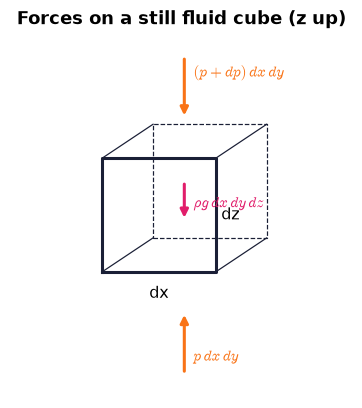

```python
from scripts.ch01_drawings import draw_cube_forces      # our drawing of the fluid cube (geometry only, no physics)
fig, ax = plt.subplots(figsize=(4.2, 3.6))               # a small square figure
draw_cube_forces(ax)                                     # the cube, its top and bottom pressure forces and its weight
ax.set_title("Forces on a still fluid cube (z up)")      # the message
plt.show()                                               # display
```

**What you see.** A small cube of fluid with two orange pressure forces — up on the bottom face, down on the top face — and its rose weight pointing down.

**How to read it.** The two orange arrows are not equal: the difference between them is exactly what holds up the cube's weight. The derivation D05 below makes this exact.

**What would change if…** In a denser fluid (mercury instead of water) the same cube is 13.6× heavier, so the pressure difference between its faces must be 13.6× larger.

📝 **Note.** **The cube balance** `N11` — The pressure difference between a fluid element's top and bottom faces balances its weight — the picture above, made exact in D05.

> 📎 **Primer — weight and gravitational acceleration.** `P24` · Weight W = mg points down; standard gravity is g = 9.80665 m/s². For fluid of density ρ filling a volume V, W = ρVg. (Newton's second law was primed in C06, P09.)

```python
rho_water, V_litre = 1000.0, 1e-3              # density of water [kg/m³] and one litre [m³]
print(rho_water * V_litre * 9.80665)           # its weight W = ρ V g → 9.81 N
```

```
9.80665
```

> 🔁 Partial derivatives ∂p/∂x (slope in one variable with the others held fixed) were primed in C12 (P25); below they tell us how pressure may vary sideways and upward in still water.

> 📎 **Primer — first-order Taylor expansion.** `P26` · Close to a point, a smooth function is its value plus slope × step: $p(z + dz) \approx p(z) + (dp/dz)\,dz$. The neglected terms shrink like dz², so after dividing by dz they vanish as dz → 0 — they are of a higher **order of smallness**.

```python
step = 0.1                                   # a small step
print(np.exp(step), 1 + step)                # e^0.1 = 1.10517 vs the first-order estimate 1.1
print(np.exp(step) - (1 + step), step**2/2)  # the error 0.00517 ≈ step²/2: second order
```

```
1.1051709180756477 1.1
0.005170918075647624 0.005000000000000001
```

📝 **Note.** **Absolute and gauge pressure** `C17` — In a fluid at rest the normal stress is the **pressure** — the compressive normal stress of C03 (§1.3). **Absolute** pressure is measured from vacuum; **gauge** pressure from the local atmosphere. The standard atmosphere is 101 325 Pa and 1 bar = 10⁵ Pa. A tyre at 2.0 bar gauge holds 3.01 bar absolute.

$$ p_{\rm gauge} = p - p_{\rm atm} $$

📝 **Note.** **Pressure is the same in every direction** `C18` — (Stated, not derived.) Take a tiny wedge of fluid at rest. The forces on its faces scale with face area (∝ size²) but its weight with its volume (∝ size³), so as the wedge shrinks the weight becomes negligible and the face pressures must be equal, whatever the wedge's orientation. For a 1 mm tall wedge of water the pressure difference is only ½ρg dz ≈ 4.9 Pa, and it vanishes as dz → 0 (printed in the code below). So pressure at a point is a single number, a scalar.

$$ p_1 = p_2 = p_3 \qquad \text{(1.6)} $$

📝 **Note.** **Towards the stress tensor** `N10` — This direction-independent normal stress becomes the −pδᵢⱼ part of the stress tensor (Ch. 2 §2.6, Ch. 4 §4.5).

📝 **Note.** **Pascal's law** `C19` — (Stated.) On a fluid cube at rest the two faces normal to x feel p(x) and p(x + dx); nothing else acts sideways (gravity is vertical), so they must be equal and ∂p/∂x = 0 — likewise in y. Points at the same height in one connected, resting fluid have the same pressure, which is why water levels in connected vessels line up.

$$ \frac{\partial p}{\partial x} = \frac{\partial p}{\partial y} = 0 \qquad \text{(1.7)} $$

#### 🧮 Derivation — The hydrostatic law (Eq. 1.8)

**What we want to show.** Find how pressure must change with height inside a fluid that is not moving, so that every little piece of it stays at rest. This is the base state of everything stratified in the book.

**Assumptions.** Fluid at rest (step 6: a = 0; step 4: p = p(z) only) · z points up (steps 1–2: signs of the face forces) · g uniform over the tiny cube (step 5) · dz small enough for a first-order Taylor step (step 3).

**The plan.**

1. List the vertical forces on a cube dx × dy × dz: pressure on the bottom, pressure on the top, weight.
2. Relate the top pressure to the bottom one with a Taylor step.
3. Add the forces, cancel, divide by the volume.

**Tools we use** (each explained before this point): Newton's second law (P09, C06) · weight W = mg (P24) · pressure acts normal to a surface and is the same in every direction (C18) · Pascal's law, p independent of x and y at rest (C19) · partial derivative (P25) · first-order Taylor expansion (P26)

**We start from**

$$ \sum F_z = m\,a_z = 0 $$

*In words:* a small cube of fluid at rest has zero acceleration, so the vertical forces on it add to zero (Newton's second law, P09).

**Step 1 of 9 — Write the push on the bottom face.**

$$ F_{\rm bottom} = +\,p(z)\,dx\,dy $$

- *Why we can do this:* Pressure pushes into the fluid normal to a face; on the bottom face that is upward (positive z). We start the force list with it because the cube is held up from below.
- *In words:* The fluid underneath pushes the cube up with pressure times area.

**Step 2 of 9 — Write the push on the top face.**

$$ F_{\rm top} = -\,p(z+dz)\,dx\,dy $$

- *Why we can do this:* On the top face the fluid above pushes down, so the force is negative with z up; it uses the pressure at the top face's height z + dz.
- *In words:* The fluid above pushes the cube down with the pressure found one step higher.

**Step 3 of 9 — Expand the top pressure to first order.**

$$ p(z+dz) \approx p(z) + \dfrac{\partial p}{\partial z}\,dz $$

- *Why we can do this:* First-order Taylor expansion (P26), an approximation (≈): the dropped terms are proportional to dz², so they vanish when we divide by the volume and let the cube shrink, and the relation becomes exact as dz → 0. We need the two face pressures in terms of one value.
- *In words:* The top pressure is the bottom pressure plus slope times height.

**Step 4 of 9 — Use Pascal's law to make it an ordinary derivative.**

$$ \dfrac{\partial p}{\partial z} = \dfrac{dp}{dz} $$

- *Why we can do this:* At rest p does not change with x or y (C19, $\partial p/\partial x = \partial p/\partial y = 0$, Eq. 1.7), so p depends on z alone and its partial derivative in z is the ordinary one. The book writes dp directly; this is why it may.
- *In words:* In still fluid pressure depends only on height.

**Step 5 of 9 — Write the weight.**

$$ W = -\,\rho g\,dx\,dy\,dz $$

- *Why we can do this:* Mass = density × volume and weight = mass × g, pointing down (P24); ρ and g are treated as constant across the tiny cube.
- *In words:* The cube's weight pulls it down.

**Step 6 of 9 — Add the three forces and set the sum to zero.**

$$ p\,dx\,dy - \Big(p + \dfrac{dp}{dz}dz\Big)dx\,dy - \rho g\,dx\,dy\,dz = 0 $$

- *Why we can do this:* Newton's second law with zero acceleration (the fluid is at rest), using steps 1–5. The horizontal forces already cancel by Pascal's law, so only this vertical balance is left.
- *In words:* Push up, push down and weight exactly cancel.

**Step 7 of 9 — Cancel the p dx dy terms.**

$$ -\dfrac{dp}{dz}\,dx\,dy\,dz - \rho g\,dx\,dy\,dz = 0 $$

- *Why we can do this:* The term p dx dy appears once with a plus and once with a minus sign, so the two cancel; what is left are the parts that differ between the faces, plus the weight.
- *In words:* Only the pressure difference between the faces and the weight remain.

**Step 8 of 9 — Divide by the volume dx dy dz.**

$$ -\dfrac{dp}{dz} - \rho g = 0 $$

- *Why we can do this:* Every remaining term contains the volume dx dy dz ≠ 0, so we may divide by it. This removes the arbitrary size of the cube, and the dropped Taylor terms (∝ dz) vanish as the cube shrinks.
- *In words:* Per unit volume, the upward pressure-gradient force balances the weight.

**Step 9 of 9 — Move the weight term across.**

$$ \dfrac{dp}{dz} = -\rho g $$

- *Why we can do this:* Add ρg to both sides, then multiply both sides by −1 (an equation, not an inequality, so nothing else changes). We isolate dp/dz because it is what we want to know.
- *In words:* Pressure falls with height by ρg per metre.

**Result**

$$ \dfrac{dp}{dz} = -\rho g $$

*In words:* going up one metre in still fluid, pressure drops by the weight of a one-metre column of unit cross-section.

**What it means.** Pressure in still fluid is the weight of everything above, per unit area. It holds for liquids and gases alike — ρ may vary with z or with p, and then we integrate numerically, as `integrate_hydrostatic` does below. It fails when the fluid accelerates (Ch. 4 adds ρ Du/Dt) or when g varies over the column (planetary scales).

**Check it.** Units: Pa/m = kg m⁻² s⁻² and ρg = kg m⁻³ · m s⁻² = kg m⁻² s⁻² ✓. Limit: ρ → 0 (vacuum) gives constant p ✓. Number: water, ρg = 1000 × 9.81 = 9810 Pa/m, so 10 m of depth adds 9.81×10⁴ Pa ≈ 1 atm ✓ (the code below prints `hydrostatic_pressure_uniform` at −10 m).

> ⚠️ **Common confusion (traps in this derivation):** with z pointing *down* (depth) the sign flips, dp/dh = +ρg; forgetting that the top-face force points down gives dp/dz = +ρg; writing dp/dz before knowing that p depends on z only.

> 📎 **Primer — definite integral.** `P27` · $\int_a^b f\,dz$ adds up the pieces f dz from z = a to z = b; for a constant, $\int_a^b c\,dz = c\,(b - a)$. The trapezoid rule `np.trapezoid(f, z)` approximates it from samples (exact for straight lines).

```python
zs = np.linspace(-10, 0, 11)                 # heights from −10 m to 0 m
print(np.trapezoid(np.full(11, 9807.0), zs)) # ∫ ρg dz of a constant 9807 Pa/m over 10 m → 98070.0 Pa
```

```
98070.0
```

📝 **Note.** **Uniform density** `C21` — (Stated.) For uniform density, integrating $dp/dz = -\rho g$ (1.8) from z = 0, where the pressure is p₀, up or down to z gives a straight line: pressure grows by ρgh at a depth h = −z. Ten metres of water add 9.81×10⁴ Pa ≈ one atmosphere. And because the pressure pushes harder on the bottom of a submerged body than on its top, the body feels an upward net force — **buoyancy**, derived next.

$$ p = p_0 - \rho g z \qquad \text{(1.9)} $$

> 📎 **Primer — net force from pressure.** `P28` · Pressure p pushes on each bit of surface dA along the inward normal, giving a force $-p\,\hat{\mathbf n}\,dA$ with $\hat{\mathbf n}$ pointing out of the body. The net force on a closed body is the sum over its whole surface, $\mathbf F = -\oint p\,\hat{\mathbf n}\,dA$ — for a box, just six faces.

```python
F_uniform = ch01.net_pressure_force_on_box(lambda x, y, z: 1e5 + 0 * z, (0, 1, 0, 1, 0, 1))  # uniform 1e5 Pa on a 1 m cube
print(F_uniform)                                                                             # → [0. 0. 0.] N: pushes cancel
```

```
[0. 0. 0.]
```

#### 🧮 Derivation — Buoyancy: the net pressure force on a submerged body (from Eq. 1.9; our addition)

**What we want to show.** Show that still fluid pushes up on a submerged body with a force equal to the weight of the fluid the body displaces — whatever the body is made of. The parcel argument (D18, §1.10) needs this.

**Assumptions.** Fluid at rest with uniform density near the body (step 5) · the body is fully submerged and does not disturb the fluid's pressure (steps 2–9) · g uniform.

**The plan.**

1. Put a box of horizontal area A between heights z₁ (bottom) and z₂ (top) into the fluid.
2. Show that the side forces cancel.
3. Subtract the top force from the bottom force and use $p = p_0 - \rho g z$ (1.9).
4. Build any shape from thin boxes.

**Tools we use** (each explained before this point): $p = p_0 - \rho g z$ (1.9) (C21) · Pascal's law (C19) · net force from pressure as a surface sum (P28) · definite integral (P27)

**We start from**

$$ p(z) = p_0 - \rho g z $$

*In words:* in fluid of uniform density ρ the pressure grows linearly with depth (1.9).

**Step 1 of 9 — Pair up the side faces.**

$$ F_{x,\rm left} + F_{x,\rm right} = p\,A_x - p\,A_x = 0 $$

- *Why we can do this:* Opposite side faces sit at the same heights, so by Pascal's law (C19) they feel the same pressure at each height, pushing in opposite directions. We clear the horizontal forces first to be left with a one-dimensional balance.
- *In words:* Sideways pushes cancel.

**Step 2 of 9 — Write the upward force on the bottom face.**

$$ F_{\rm bottom} = p(z_1)\,A $$

- *Why we can do this:* Pressure acts normal to the face, which on a bottom face means upward, over the face's area A.
- *In words:* The fluid below pushes up.

**Step 3 of 9 — Write the downward force on the top face.**

$$ F_{\rm top} = p(z_2)\,A $$

- *Why we can do this:* The same rule on the top face, where the normal push points down; the top is higher, z₂ > z₁.
- *In words:* The fluid above pushes down, less hard because it is higher.

**Step 4 of 9 — Take the net upward force.**

$$ F_{\rm net} = \big[p(z_1) - p(z_2)\big]\,A $$

- *Why we can do this:* Up minus down: this is the vertical part of the surface sum of P28, since the sides contribute nothing (step 1).
- *In words:* What is left is the difference of the two face pressures.

**Step 5 of 9 — Substitute the hydrostatic pressure.**

$$ p(z_1) - p(z_2) = \rho g\,(z_2 - z_1) $$

- *Why we can do this:* From $p = p_0 - \rho g z$ (1.9): (p₀ − ρgz₁) − (p₀ − ρgz₂); p₀ cancels. This is where the fluid's density enters — and only the fluid's.
- *In words:* The pressure difference is ρg times the box's height.

**Step 6 of 9 — Recognise the volume.**

$$ F_{\rm net} = \rho g\,A\,(z_2 - z_1) = \rho\,g\,V $$

- *Why we can do this:* A (z₂ − z₁) is the volume V of the box; multiplying area by height is the definition of a box's volume.
- *In words:* The net push up equals the weight of fluid that would fill the box.

**Step 7 of 9 — Project a slanted piece of surface onto the horizontal.**

$$ dF_z = p\,|n_z|\,dA_s = p\,dA $$

- *Why we can do this:* A curved body has slanted top and bottom surfaces. On a small slanted piece of area dA_s the pressure force is p dA_s along the normal; its vertical part is p |n_z| dA_s, and |n_z| dA_s is exactly the piece's shadow dA on a horizontal plane. So for vertical forces a slanted cap acts like a flat face of area dA.
- *In words:* Only the horizontal footprint of a surface matters for its vertical pressure force.

**Step 8 of 9 — Apply the box result to one thin vertical column.**

$$ dF_{\rm net} = \rho g\,h(x,y)\,dA $$

- *Why we can do this:* Slice the body into vertical columns of footprint dA and height h(x, y). By step 7 its caps act like the flat faces of a box, and steps 4–6 give the net upward force ρg × height × area. Side forces between neighbouring columns cancel in pairs, as in step 1.
- *In words:* Each thin column is buoyed up by the weight of fluid that would fill it.

**Step 9 of 9 — Add all the columns.**

$$ F_{\rm net} = \displaystyle\int_A \rho g\,h(x,y)\,dA = \rho g V $$

- *Why we can do this:* Summing infinitely many thin columns is the definite integral of P27 over the body's footprint A; ρg is a constant and comes outside, and ∫h dA is the body's volume V.
- *In words:* Any submerged body feels an upward force equal to the weight of the displaced fluid.

**Result**

$$ F_b = \rho_{\rm fluid}\,g\,V $$

*In words:* Archimedes' principle, derived from the hydrostatic pressure.

**What it means.** Buoyancy is nothing but the pressure difference between a body's bottom and top. It does not care what the body is made of; the body's own weight decides whether it rises or sinks. In a stratified fluid (D18) the relevant density is the environment's at the body's current height. It fails if the body sits on the bottom (no fluid underneath to push) or is only partly submerged (then use the submerged volume).

**Check it.** Units: kg m⁻³ · m s⁻² · m³ = N ✓. Special cases: ρ_fluid → 0 gives no buoyancy ✓; a body with the fluid's own density feels weight = buoyancy and is neutral ✓. Number: 1 L in water → 9.81 N; `net_pressure_force_on_box` integrates the six faces numerically and returns (0, 0, 9.807) N ✓ (code below).

> ⚠️ **Common confusion (traps in this derivation):** thinking the side forces add up; putting the body's density into the buoyancy; forgetting that the net force points up.

📝 **Note.** **Reminder: liquids under tension (from §1.3)** `C03` — A liquid cannot be pulled below its vapour pressure: a sealed water column hanging below a suction pump cannot be lifted more than about 10 m, because by $p = p_0 - \rho g z$ (1.9) the pressure at its top would have to fall below ≈ 2.3 kPa.

📝 **Note.** **Capillary rise (Example 1.1, stated)** `C22` — In a thin tube dipped into water the curved meniscus (C15, C16 in §1.6) lowers the pressure just under it, so water rises until its weight balances the surface-tension pull around the rim: σ·2πR·sin α = ρgh·πR². **The book's α is measured from the horizontal** — the complement of the usual contact angle θ_c (α = 90° − θ_c; α = 90° is perfect wetting; `ch01.alpha_from_contact_angle` converts). Clean glass and water, R = 1 mm: h = 14.9 mm; R = 0.1 mm: 149 mm.

$$ h = \frac{2\sigma\sin\alpha}{\rho g R} $$

📝 **Note.** **Pressure along the tube axis** `N12` — Along the axis the pressure falls linearly from atmospheric at the outside water level to p_atm − ρgh just under the meniscus (inset of the p(z) figure below, where F marks the axis at the outside water level and E the point just under the meniscus); pressure jumps at free surfaces return in Ch. 7 §7.3.

#### ✏️ Tiny example: 10 m of water and a 1-litre block

(g ≈ 9.81 m/s²)

1. p(−10 m) = 101 325 + 1000 × 9.81 × 10 = 199 425 Pa absolute; gauge 98 100 Pa.
2. A 1-litre block: buoyancy ρ_water g V = 1000 × 9.81 × 0.001 = 9.81 N, whatever the block is made of.
3. Steel (7850 kg/m³) weighs 77.0 N → net 67.2 N down: it sinks.
4. Pine (600 kg/m³) weighs 5.89 N → net 3.92 N up: it floats.
5. 1 m of oil (800 kg/m³) over 9 m of water: p = 101 325 + 800 × 9.81 × 1 + 1000 × 9.81 × 9 = 197 463 Pa (197 430 Pa with g = 9.80665).

> 📎 **Primer — functions as arguments and lambda.** `P29` · Python functions are values: you can pass one to another function. `lambda z, p: 1000.0` is a one-line function (here a density that ignores its inputs). `integrate_hydrostatic(z, rho_fn, p0)` takes the density as such a function.

```python
apply = lambda f, x: f(x)          # a function that calls whatever function it is given
print(apply(lambda z: 2 * z, 3.0)) # pass a doubling function → 6.0
```

```
6.0
```

> 📎 **Primer — explicit stepping.** `P30` · To follow dy/dx = f(x, y), take small steps: $y_{k+1} = y_k + f(x_k, y_k)\,\Delta x$ (**Euler's method**; its error shrinks like Δx). For oscillators, update the velocity first and use the *new* velocity to move the position (**Euler–Cromer**; keeps the energy bounded).

```python
yk, dx = 1.0, 1e-3                  # start y(0) = 1, step 0.001
for _ in range(1000):               # 1000 Euler steps of dy/dx = −y to x = 1
    yk = yk + (-yk) * dx            # y_{k+1} = y_k + f(y_k) Δx
print(yk, np.exp(-1))               # 0.3677 vs the exact e^(−1) = 0.3679
```

```
0.36769542477096373 0.36787944117144233
```

> 📎 **Primer — scipy.integrate.solve_ivp.** `P31` · `integrate_hydrostatic` hands dp/dz = −ρ(z, p) g to scipy's adaptive Runge–Kutta solver `solve_ivp`, which chooses its own step sizes to reach a requested tolerance (here 10⁻¹⁰).

```python
from scipy.integrate import solve_ivp                                              # scipy's ODE solver
print(solve_ivp(lambda x, yy: -yy, (0, 1), [1.0], rtol=1e-10, atol=1e-12).y[0, -1])  # dy/dx = −y to x = 1 → 0.367879
```

```
0.36787944117920773
```

```python
z = np.linspace(0, -10, 201)                                         # heights from the surface to 10 m down [m] (z up)
p_w = ch01.hydrostatic_pressure_uniform(z, ch01.P_ATM, 1000.0)       # Eq. (1.9): uniform water [Pa]
p_layers = ch01.layered_pressure(z, [1.0, 9.0], [800.0, 1000.0])     # 1 m of oil over 9 m of water, (1.9) layer by layer [Pa]
rho_fn = lambda zz, pp: 1000.0 - 0.5 * zz                            # a salty lake: 0.5 kg/m³ denser per metre down (P29)
p_strat = ch01.integrate_hydrostatic(z, rho_fn, ch01.P_ATM)          # Eq. (1.8) integrated numerically (solve_ivp, P31) [Pa]
p_exact = ch01.P_ATM + ch01.G0 * (1000.0 * (-z) + 0.25 * z**2)       # the same integral done by hand for this ρ(z) [Pa]
assert np.allclose(p_strat, p_exact, rtol=1e-10)                     # the integrator reproduces the exact answer
print(f"10 m down: uniform {p_w[-1]:.1f} Pa, oil over water {p_layers[-1]:.1f} Pa, salty lake {p_strat[-1]:.1f} Pa")   # the three profiles at the bottom
print(f"gauge pressure 10 m down in water: {ch01.gauge_pressure(p_w[-1]):.1f} Pa")             # C17
box = (0, 0.1, 0, 0.1, -1.1, -1.0)                                   # a 10 cm cube 1.0–1.1 m below the surface [m]
F_box = ch01.net_pressure_force_on_box(lambda xx, yy, zz: ch01.hydrostatic_pressure_uniform(zz, ch01.P_ATM, 1000.0), box)   # −∮p n dA over the cube's six faces [N]
print(f"net pressure force on the cube: {F_box} N;  ρ g V = {ch01.buoyancy_force(1000.0, 1e-3):.3f} N")   # D37 check
print("C18 wedge, 1 mm tall:", ch01.wedge_pressure_difference(1000.0, 1e-3, 0.6))              # differences of ≈ 5 Pa
h_cap = ch01.capillary_rise(ch01.surface_tension_water(293.15), np.pi / 2, 998.2, np.array([1e-3, 1e-4]))  # C22
print(f"capillary rise for R = 1 mm and 0.1 mm: {h_cap} m")                                     # [0.0149 0.149] m
```

```
10 m down: uniform 199391.5 Pa, oil over water 197430.2 Pa, salty lake 199636.7 Pa
gauge pressure 10 m down in water: 98066.5 Pa
net pressure force on the cube: [0.     0.     9.8066] N;  ρ g V = 9.807 N
C18 wedge, 1 mm tall: {'p2_minus_p1': 4.903325, 'p3_minus_p1': 0.0}
capillary rise for R = 1 mm and 0.1 mm: [0.0149 0.1486] m
```

**What does the code above do?**

1. `hydrostatic_pressure_uniform` is $p = p_0 - \rho g z$ (1.9); `layered_pressure` applies it layer by layer with a kink at the oil–water interface.
2. `integrate_hydrostatic` integrates $dp/dz = -\rho g$ (1.8) for a density that depends on z (passed as a lambda, P29) with `solve_ivp` (P31); the assert compares it with the integral done by hand.
3. `gauge_pressure` subtracts the atmosphere (C17).
4. `net_pressure_force_on_box` adds −p n̂ dA over the six faces of a submerged cube (P28): the horizontal parts cancel and the vertical part equals `buoyancy_force` = ρgV — derivation D37 checked numerically.
5. `wedge_pressure_difference` gives the tiny face-pressure differences of a 1 mm wedge (C18); `capillary_rise` gives the C22 heights.

#### From scratch: march down the salty lake

Euler's method (P30) applied to $dp/dz = -\rho g$ (1.8): start at the surface and step down 1 mm at a time, adding ρ(z)g|Δz| each step.

```python
dz_step = -1e-3                                         # step downward, 1 mm [m]
nz = 10_000                                             # 10 000 steps reach 10 m
z_mine = np.arange(nz + 1) * dz_step                    # heights 0, −0.001, …, −10 m
p_mine = np.empty(nz + 1)                               # pressure at every height [Pa]
p_mine[0] = ch01.P_ATM                                  # start: atmospheric pressure at the surface
for k in range(nz):                                     # Euler step of dp/dz = −ρ g (Eq. 1.8)
    p_mine[k + 1] = p_mine[k] - rho_fn(z_mine[k], p_mine[k]) * ch01.G0 * dz_step   # p_{k+1} = p_k − ρ g Δz
assert np.allclose(p_mine[::50], p_strat, rtol=1e-6)    # every 50th point matches the 201-point library profile
print(f"Euler at −10 m: {p_mine[-1]:.3f} Pa; library: {p_strat[-1]:.3f} Pa")   # hand march vs library
```

```
Euler at −10 m: 199636.642 Pa; library: 199636.666 Pa
```

Euler's error here is about ½ρ′g|Δz| per metre of depth — roughly 0.02 Pa after 10 m, far inside a relative tolerance of 10⁻⁶.

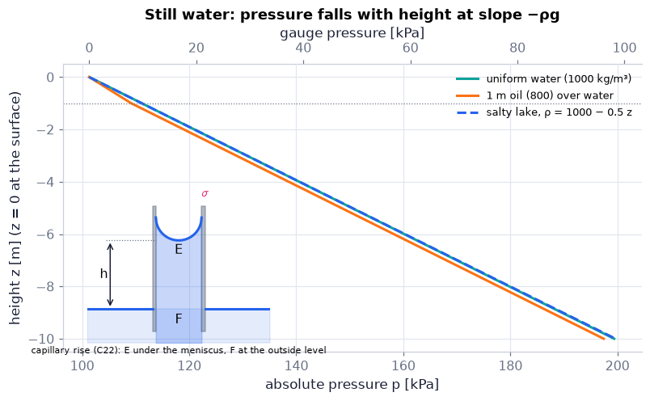

```python
from scripts.ch01_drawings import draw_capillary                        # our capillary-tube drawing (geometry only)
fig, ax = plt.subplots(figsize=(7.2, 4.4))                              # one panel: pressure across, height up
ax.plot(p_w / 1e3, z, color=COLORS["teal"], label="uniform water (1000 kg/m³)")          # straight, slope −ρg
ax.plot(p_layers / 1e3, z, color=COLORS["orange"], label="1 m oil (800) over water")    # kink at z = −1 m
ax.plot(p_strat / 1e3, z, color=COLORS["blue"], ls="--", label="salty lake, ρ = 1000 − 0.5 z")   # slightly curved
ax.axhline(-1.0, color=COLORS["muted"], lw=0.8, ls=":")                 # the oil–water interface
ax.set_xlabel("absolute pressure p [kPa]")                              # bottom axis: absolute
ax.set_ylabel("height z [m] (z = 0 at the surface)")                    # z up
top = ax.secondary_xaxis("top", functions=(lambda P: P - ch01.P_ATM / 1e3, lambda G: G + ch01.P_ATM / 1e3))   # same axis in gauge
top.set_xlabel("gauge pressure [kPa]")                                  # top axis: gauge = absolute − 101.325 kPa
ax.set_title("Still water: pressure falls with height at slope −ρg")    # the message
ax.legend(loc="upper right", fontsize=8.5)                              # legend where the lines are not
ax_in = ax.inset_axes([0.02, 0.03, 0.36, 0.5])                           # small inset in the empty lower-left corner
draw_capillary(ax_in, R=1.0, alpha=np.radians(90), h=3.0)                # N12: water rises in a thin tube
ax_in.text(0.5, -0.02, "capillary rise (C22): E under the meniscus, F at the outside level", transform=ax_in.transAxes,
           ha="center", va="top", fontsize=7)                           # inset label below the drawing (σ arrow sits on top)
savefig(fig, "ch01", "c20_pressure_profiles")                           # keep a copy for review
plt.show()                                                              # display
```

**What you see.** Three nearly straight lines running from 101 kPa at the surface to about 198–200 kPa at 10 m depth: teal for uniform water, orange with a kink at 1 m where oil meets water, dashed blue for the salty lake curving very slightly. The top axis reads the same pressures as gauge values; the inset shows water standing higher inside a thin tube.

**How to read it.** The slope of each line is −ρg, so the kink marks a density jump and the gentle curvature a density that grows with depth. Gauge and absolute pressure differ only by a constant, so the physics (the slope) is the same on both axes.

**What would change if…** Mercury (13 600 kg/m³) would make the line 13.6 times steeper — that is why a barometer column of mercury is only 76 cm tall, while a water barometer would need about 10 m.

```python
z_tank = np.linspace(0, -10, 201)                                     # heights in a 10 m tank [m]
z_faces = np.array([-1.45, -1.55])                                    # top and bottom faces of a 10 cm cube centred 1.5 m down
def tank(rho_top):                                                    # called once per slider value (upper-layer density)
    p_g = ch01.layered_pressure(z_tank, [2.0, 8.0], [rho_top, 1000.0]) - ch01.P_ATM   # gauge p(z) of 2 m oil over 8 m water
    p_f = ch01.layered_pressure(z_faces, [2.0, 8.0], [rho_top, 1000.0]) - ch01.P_ATM  # gauge pressure on the two faces
    return {"p(z) [kPa gauge]": (p_g / 1e3, z_tank), "cube faces": (p_f / 1e3, z_faces)}   # two traces: profile and face markers
rhos = np.linspace(600, 1000, 25)                                      # 25 slider positions [kg/m³]
fig = slider_figure(tank, "ρ upper layer", rhos, unit="kg/m³", xlabel="gauge pressure [kPa]", ylabel="height z [m]",   # one slider position per density
                    title="A lighter upper layer: gentler slope above the interface, less buoyancy on the cube",   # the message
                    modes={"cube faces": "markers"}, active=10)   # faces as dots; start mid-range
for i, r in enumerate(rhos):                                          # add a per-position title: plotly "update" steps take
    Fb = r * ch01.G0 * 1e-3                                           #   (data changes, layout changes); buoyancy ρ g V [N]
    st = fig.layout.sliders[0].steps[i]                               # the slider step for this density
    st.args = [st.args[0], {"title.text": f"upper layer {r:.0f} kg/m³: face-pressure gap × area = ρgV = {Fb:.2f} N"}]   # keep the visibility, add a title
fig.show()                                                            # drag the slider
```

[interactive chart not shown]

**What does the code above do?**

1. For each of 25 upper-layer densities, `layered_pressure` gives the gauge pressure profile and the pressures on the top and bottom faces of a 10 cm cube sitting in the upper layer.
2. The loop adds a title to every slider position: plotly's slider steps (method "update") accept a second dictionary of layout changes, here the title text with the buoyancy ρgV of the cube.

**What you see.** The gauge pressure profile of a 2 m oil layer over 8 m of water, with a kink at the interface, and two markers for the pressure on the top and bottom faces of a small cube in the upper layer.

**How to read it.** The slope of each straight piece is −ρg of that layer; the horizontal gap between the two markers is the pressure difference across the cube, and the title turns it into the buoyancy force.

**What would change if…** Slide the upper density toward 1000 kg/m³: the kink disappears (one fluid), and the face-pressure gap and the buoyancy grow to the values for water.

**What would change if…** the fluid were air over 1 km? Its density falls with height because air is compressible, so $dp/dz = -\rho g$ (1.8) still holds but p(z) is no longer a straight line — that needs the equation of state (§1.9, C40). **Next:** a fluid particle also has a temperature and an energy; §1.8 is its thermodynamics (C25).

## 1.8 Classical Thermodynamics

**What is this section about?** The energy bookkeeping of a fluid particle: what heat and work do to it (the first law), which quantities describe its state, entropy and the Gibbs relations, and two material properties that the rest of the book needs — the speed of sound and the thermal expansion coefficient. (The fluid particle itself, C24, was already met in §1.4.)

### 🧩 The first law: heat in plus work done changes the internal energy `C25`

*The question:* Take a kilogram of air from one state to another by two different routes. What is the same at the end, and what depends on the route?

#### The problem in plain words

A bicycle pump gets warm; an engine turns heat into work cycle after cycle; air rising over a mountain cools although nobody removes any heat. To follow the temperature of a fluid particle we need a bookkeeping rule for energy — Chapter 4 turns it into the energy equation.

#### The idea

Think of a bank account. The **balance** (the internal energy e) depends only on where you are now. Deposits arrive through two channels — **heat** q and **work** w — and how much came through each channel depends on the route you took.

```
p ↑   1 ●
      │  ╲   route A: along the isotherm (heat flows in while the gas expands)
      │ │ ╲
      │ │  ╲________● 2
      │ └──────────┘      route B: cool at fixed volume, then expand at fixed pressure
      └────────────────────► v
same start, same end  ⇒  same Δe;   different routes  ⇒  different q and w
```

📝 **Note.** **System, equilibrium and relaxation** `C23` — A **thermodynamic system** is a lump of matter we choose to follow whose molecules stay the same: energy may cross its boundary as heat or as work, but matter may not. After a disturbance it **relaxes** back to **equilibrium**, where p, T and the other properties are well defined; the time this takes is the **relaxation time** — in air about the time between molecular collisions, ≈ 10⁻¹⁰ s (C24). That is why a fluid particle can be treated as always being in equilibrium.

> 📎 **Primer — internal and kinetic energy per unit mass.** `P32` · Internal energy e [J/kg] is the energy of the molecules' random motion (and of their interactions); the particle's bulk motion adds kinetic energy u²/2 [J/kg]. Thermodynamics here uses only e.

```python
print(0.5 * 10.0**2)        # kinetic energy of a 10 m/s breeze → 50 J/kg
print(717.6 * 288.15)       # internal energy stored in air at 15 °C, e = C_v T (working model of the next primer) → ≈ 2.07e5 J/kg
```

```
50.0
206776.44
```

> 📎 **Primer — perfect-gas law as a working model.** `P33` · Until §1.9 derives it, we treat air as a perfect gas so that the examples have numbers: p = ρRT (equivalently pv = RT) with R = 287 J kg⁻¹ K⁻¹, and e = C_vT with C_v = 718 J kg⁻¹ K⁻¹ (C40 and C41 show why).

```python
v1 = ch01.R_AIR * 300.0 / 1e5       # specific volume of air at 300 K and 1 bar, v = RT/p [m³/kg]
print(v1)                           # → 0.861 m³/kg
```

```
0.8611739878768323
```

> 📎 **Primer — differentials.** `P34` · dx is a tiny change of a quantity that has a value in every state — an **exact** differential: adding up the pieces gives x₂ − x₁ whatever the route. δq and δw are tiny amounts *transferred* along a route; they are not changes of anything (**inexact** differentials), so their sums depend on the route.

```python
steps_a = [50.0, 50.0, 50.0]                     # warm 300 → 450 K in three equal steps [K]
steps_b = [200.0, -100.0, 25.0, 25.0]            # or overshoot, cool, then creep up [K]
print(sum(steps_a), sum(steps_b))                # the sum of dT is 150 K both ways: T is a state function
```

```
150.0 150.0
```

#### The maths, step by step

1. Per unit mass, energy is conserved: the heat added δq plus the work done **on** the particle δw equals the rise of its internal energy, $$\delta q + \delta w = \Delta e \qquad (1.10) \quad [\mathrm{J/kg}].$$
2. Sign convention: work done *on* the gas is positive (compression), so an expanding gas has w < 0.
3. For a slow, frictionless (reversible) change the only work is the boundary moving: δw = −p dv (C27 below).
4. Along a route from state 1 to state 2 the work is $w = -\int_1^2 p\,dv$ — minus the area under the route on a p–v diagram.
5. Then the heat follows from the first law: q = Δe − w.

📝 **Note.** **Specific volume** `N13` — v = 1/ρ [m³/kg] is the specific volume; it appears in every relation from the reversible first law $de = dq - p\,dv$ (1.11) to the Gibbs relations $T\,ds = de + p\,dv = dh - v\,dp$ (1.18), and in the energy equation of Ch. 4 §4.8.

📝 **Note.** **Path functions and state functions** `C26` — **Heat and work are path functions** — energy in transit across the boundary. The internal energy is a **state function** — a property with one value in each state, so Δe = e₂ − e₁ ignores the route. A **reversible** process is carried out so slowly and without friction that the system is always in equilibrium; only then is the route a line on a p–v diagram. Number (code below): routes A, B and C between the same states all have Δe = 0, but w = −59.7, −43.1 and −86.1 kJ/kg.

📝 **Note.** **The reversible first law** `C27` — For a reversible change with boundary work only, the work done on unit mass is −p dv (a piston face of area A pushed out by dx does work pA dx on the surroundings, and A dx is the volume increase), so (stated) the first law reads as below. Friction work is excluded. Doubling the volume of air at a constant 0.5 bar: w = −p Δv = −43.1 kJ/kg.

$$ de = dq - p\,dv \qquad \text{(1.11)} $$

📝 **Note.** **Equations of state** `C28` — An **equation of state** ties state functions together; for a simple one-component fluid **two** properties fix the state, for example p = p(v, T) (thermal) or e = e(p, T) (caloric). Seawater needs a third, salinity (§1.10). Air at v = 0.861 m³/kg and 300 K has p = 1.00×10⁵ Pa (code below).

$$ p = p(v, T), \qquad e = e(p, T) \qquad \text{(1.12)} $$

> 📎 **Primer — line integral along a path.** `P35` · $\int p\,dv$ along a route adds p × (tiny volume change) step by step along that route; on a p–v diagram it is the area under the route (negative if v decreases along it). A different route between the same end points encloses a different area.

```python
print(5e4 * (1.722 - 0.861))      # a horizontal route at p = 5e4 Pa from v = 0.861 to 1.722 m³/kg → area 43050 J/kg
```

```
43050.0
```

> 📎 **Primer — natural logarithm and exponential.** `P36` · ln x undoes eˣ; $\int dv/v = \ln(v_2/v_1)$; ln 2 = 0.693. e⁻¹ ≈ 0.368 — a quantity that shrinks by that factor has decayed by one **e-folding**.

```python
print(np.log(2.0), np.exp(-1.0))   # ln 2 = 0.6931, e^(−1) = 0.3679
```

```
0.6931471805599453 0.36787944117144233
```

#### ✏️ Tiny example: doubling the volume of 1 kg of air at 300 K, three ways

State 1: T = 300 K, p = 10⁵ Pa → v₁ = RT/p = 287.06 × 300/10⁵ = 0.861 m³/kg. State 2: v₂ = 1.722 m³/kg, T = 300 K. Δe = C_v(300 − 300) = 0 on **every** route.

- **A (isothermal):** p = RT/v, so w = −RT ln(v₂/v₁) = −287.06 × 300 × 0.693 = −59.7 kJ/kg and q = Δe − w = +59.7 kJ/kg.
- **B (cool at fixed v to 150 K, then expand at fixed p):** leg 1: w = 0, q = C_vΔT = 717.6 × (−150) = −107.6 kJ/kg. Leg 2: p = R·150/v₁ = 5.0×10⁴ Pa, w = −p(v₂ − v₁) = −43.1 kJ/kg, Δe = +107.6, q = +150.7. Totals: w = −43.1, q = +43.1 kJ/kg.
- **C (expand at fixed p to 600 K, then cool at fixed v):** w = −p₁(v₂ − v₁) = −86.1 kJ/kg, q = +86.1 kJ/kg.

> 📎 **Primer — trapezoid rule.** `P37` · Approximates $\int f\,dx$ by adding up trapezoids between neighbouring samples; the error shrinks like Δx². `np.trapezoid(f, x)` returns the total and `scipy.integrate.cumulative_trapezoid` the running sum.

```python
xs = np.linspace(1, 2, 101)                          # 101 samples between 1 and 2
print(np.trapezoid(1 / xs, xs), np.log(2.0))         # ∫ dx/x from 1 to 2: 0.693153 vs ln 2 = 0.693147
```

```
0.6931534304818243 0.6931471805599453
```

```python
routes = {"isothermal": "A: along the 300 K isotherm",   # route A
          "isochoric-isobaric": "B: cool at fixed v, then expand at fixed p",   # route B
          "isobaric-isochoric": "C: expand at fixed p, then cool at fixed v"}      # the three routes of the example
tot = {}                                                                          # exact totals per route
for kind, label in routes.items():                                                # same start and end state every time
    tot[kind] = ch01.path_heat_work_totals(kind, v1, 300.0, 2 * v1, 300.0)        # leg-by-leg q, w, Δe [J/kg]
    print(f"{label:45s} q = {tot[kind]['q']/1e3:7.2f}  w = {tot[kind]['w']/1e3:7.2f}  Δe = {tot[kind]['de']/1e3:5.2f} kJ/kg")   # q, w, Δe of this route [kJ/kg]
path_B = ch01.process_path("isochoric-isobaric", (v1, 300.0), (2 * v1, 300.0))    # route B sampled: arrays v, T, p
run_B = ch01.process_heat_work(path_B["v"], path_B["T"])                          # running w = −∫p dv, Δe, q along it
print(f"route B by trapezoid sums: w = {run_B['w'][-1]/1e3:.2f} kJ/kg")          # same as the exact total
print("C28: state (p, ρ, T) of air at v = 0.861 m³/kg, 300 K:", ch01.perfect_gas_state(rho=1 / v1, T=300.0))   # two properties fix the third
```

```
A: along the 300 K isotherm                   q =   59.69  w =  -59.69  Δe =  0.00 kJ/kg
B: cool at fixed v, then expand at fixed p    q =   43.06  w =  -43.06  Δe =  0.00 kJ/kg
C: expand at fixed p, then cool at fixed v    q =   86.12  w =  -86.12  Δe =  0.00 kJ/kg
route B by trapezoid sums: w = -43.06 kJ/kg
C28: state (p, ρ, T) of air at v = 0.861 m³/kg, 300 K: (100000.0, 1.1612055334665112, 300.0)
```

**What does the code above do?**

1. `path_heat_work_totals` computes q, w and Δe leg by leg with exact formulas for the three routes between the same two states: Δe is 0 each time, q and w are not.
2. `process_path` samples route B as arrays of v, T and p, including its corner.
3. `process_heat_work` accumulates w = −∫p dv with the trapezoid rule (P37), Δe = C_vΔT and q = Δe − w along the samples.
4. `perfect_gas_state` fills in the missing one of (p, ρ, T): two properties fix the state (C28).

#### From scratch: trapezoids along each route

```python
for kind in routes:                                                        # the three routes again
    path = ch01.process_path(kind, (v1, 300.0), (2 * v1, 300.0))           # sampled route
    v_s, T_s = path["v"], path["T"]                                        # specific volume [m³/kg] and temperature [K]
    p_s = ch01.R_AIR * T_s / v_s                                           # pressure along the route, p = RT/v [Pa]
    w = 0.0                                                                # work done ON the gas [J/kg]
    for k in range(len(v_s) - 1):                                          # one trapezoid per pair of neighbouring samples
        w -= 0.5 * (p_s[k] + p_s[k + 1]) * (v_s[k + 1] - v_s[k])           # δw = −p dv (Eq. 1.11)
    de = ch01.CV_AIR * (T_s[-1] - T_s[0])                                  # Δe = C_v ΔT (perfect gas)
    q = de - w                                                             # first law (1.10): q = Δe − w
    assert np.allclose([q, w, de], [tot[kind]["q"], tot[kind]["w"], tot[kind]["de"]], rtol=1e-4, atol=1e-6)   # = exact totals
    assert np.isclose(w, ch01.process_heat_work(v_s, T_s)["w"][-1])        # = the library's running sum
    print(f"{kind:20s} mine: q = {q/1e3:.3f}, w = {w/1e3:.3f} kJ/kg")   # our totals
```

```
isothermal           mine: q = 59.692, w = -59.692 kJ/kg
isochoric-isobaric   mine: q = 43.059, w = -43.059 kJ/kg
isobaric-isochoric   mine: q = 86.117, w = -86.117 kJ/kg
```

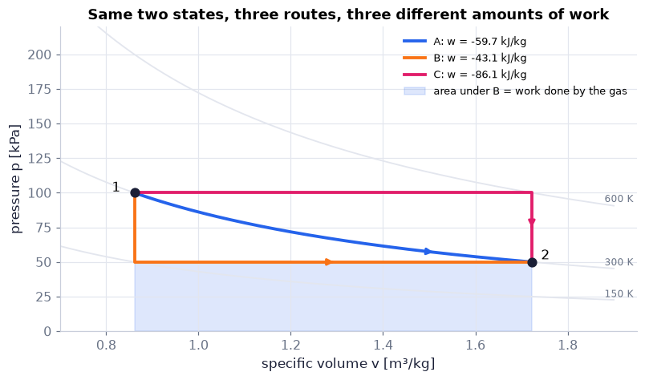

```python
fig, ax = plt.subplots(figsize=(7.2, 4.2))                                        # one p–v diagram
vv = np.linspace(0.7, 1.9, 200)                                                   # specific volumes for the isotherms [m³/kg]
for T_iso in (150.0, 300.0, 600.0):                                               # faint isotherms p = RT/v
    ax.plot(vv, ch01.R_AIR * T_iso / vv / 1e3, color=COLORS["grid"], lw=1.2)    # one isotherm [kPa]
    ax.text(1.88, ch01.R_AIR * T_iso / 1.88 / 1e3, f"{T_iso:.0f} K", color=COLORS["muted"], fontsize=8, va="bottom")  # its label
colors = {"isothermal": COLORS["blue"], "isochoric-isobaric": COLORS["orange"], "isobaric-isochoric": COLORS["rose"]}  # route colours
for kind, label in routes.items():                                                # draw the three routes
    path = ch01.process_path(kind, (v1, 300.0), (2 * v1, 300.0))                  # sampled route (v, T, p)
    ax.plot(path["v"], path["p"] / 1e3, color=colors[kind], lw=2.5, label=f"{label[:1]}: w = {tot[kind]['w']/1e3:.1f} kJ/kg")  # the route
    mid = len(path["v"]) * 3 // 4                                                 # put a direction arrow 3/4 along the route
    ax.annotate("", xy=(path["v"][mid + 1], path["p"][mid + 1] / 1e3), xytext=(path["v"][mid - 3], path["p"][mid - 3] / 1e3),
                arrowprops=dict(arrowstyle="-|>", color=colors[kind], lw=2))     # arrow head showing the direction
leg2 = path_B["corner"]                                                           # index where route B turns the corner
ax.fill_between(path_B["v"][leg2:], 0, path_B["p"][leg2:] / 1e3, color=COLORS["blue"], alpha=0.15,   # shade between p = 0 and the route
                label="area under B = work done by the gas")                      # fill_between shades between two curves
ax.plot([v1, 2 * v1], [1e2, 50.0], "o", color=COLORS["ink"], ms=7)                # state 1 and state 2
ax.text(v1 - 0.03, 101, "1", ha="right", fontsize=11); ax.text(2 * v1 + 0.02, 52, "2", fontsize=11)   # label the two states
ax.set_xlim(0.7, 1.95); ax.set_ylim(0, 220)                                       # fixed axes
ax.set_xlabel("specific volume v [m³/kg]"); ax.set_ylabel("pressure p [kPa]")    # axis labels with units
ax.set_title("Same two states, three routes, three different amounts of work")   # the message
ax.legend(loc="upper right", fontsize=8.5)                                        # legend with the work of each route
savefig(fig, "ch01", "c25_pv_routes")                                             # keep a copy for review
plt.show()                                                                        # display
```

**What you see.** Three routes from state 1, $(v, p) = (0.861\ \mathrm{m^3/kg},\ 100\ \mathrm{kPa})$, to state 2, $(v, p) = (1.722\ \mathrm{m^3/kg},\ 50\ \mathrm{kPa})$: the blue isotherm, the orange route that drops first and then runs across, and the rose route that runs across at 100 kPa and then drops. The shaded area lies under route B's horizontal leg.

**How to read it.** The area under a route is the work done *by* the gas (−w). Because Δe = 0 between these two states, the heat taken in equals that same area — so the three routes need 43, 60 and 86 kJ/kg of heat to arrive at the same place.

**What would change if…** Run route C backwards (2 → 1) and every w and q changes sign. Going out along C and back along A encloses an area: the net work of a heat engine cycle, paid for by the difference in heat.

```python
nfr = 20 if not FAST else 12                                                   # frames per route
legs = []                                                                      # (route label, v, T, p, running q, w, Δe)
for kind in ("isothermal", "isochoric-isobaric"):                              # route A, then route B
    path = ch01.process_path(kind, (v1, 300.0), (2 * v1, 300.0))               # sampled route
    run = ch01.process_heat_work(path["v"], path["T"])                         # running q, w, Δe along it [J/kg]
    sel = np.linspace(0, len(path["v"]) - 1, nfr).astype(int)                  # the samples shown as frames
    legs += [(routes[kind][:1], path["v"][j], path["T"][j], path["p"][j], run["q"][j], run["w"][j], run["de"][j],   # one tuple per frame (continued)
              run["q"][min(j + 1, len(path["v"]) - 1)] - run["q"][j]) for j in sel]   # last item: sign of the next δq
fig, (axc, axd) = plt.subplots(1, 2, figsize=(8.4, 3.3), gridspec_kw=dict(width_ratios=[1, 1.2]))   # left: cylinder, right: p–v plane
axc.set_xlim(0, 2.3); axc.set_ylim(-0.6, 1.3); axc.axis("off")                # left: the cylinder drawing
axc.plot([0, 2.2, 2.2, 0, 0], [0, 0, 1, 1, 0], color=COLORS["ink"], lw=1.5)   # cylinder walls
gas = plt.Rectangle((0, 0), 1, 1, color=plt.cm.coolwarm(0.5))                  # the gas; its colour follows T
axc.add_patch(gas)   # put the gas on the drawing
piston = plt.Rectangle((1, -0.05), 0.08, 1.1, color=COLORS["muted"])          # the piston face
axc.add_patch(piston)   # put the piston on the drawing
heat_txt = axc.text(0.6, -0.35, "", ha="center", fontsize=10)                  # heater / cooler label
count_txt = axc.text(0.0, 1.15, "", fontsize=8.5, family="monospace")          # running counters
for T_iso in (150.0, 300.0, 600.0):                                            # right: faint isotherms on the p–v plane
    axd.plot(vv, ch01.R_AIR * T_iso / vv / 1e3, color=COLORS["grid"], lw=1)   # one isotherm [kPa]
(trace,) = axd.plot([], [], color=COLORS["accent"], lw=2.5)                   # the route so far
(dot,) = axd.plot([], [], "o", color=COLORS["orange"], ms=8)                   # the current state
axd.set_xlim(0.7, 1.9); axd.set_ylim(0, 220)   # fixed axes
axd.set_xlabel("v [m³/kg]"); axd.set_ylabel("p [kPa]")   # axis labels with units
def update(i):                                                                 # frame i: one state along A, then along B
    lab, v, T, p, q, w, de, dq_next = legs[i]   # unpack this frame's state (P14)
    start = 0 if i < nfr else nfr                                              # the current route's first frame
    x_p = 2.0 * v / (2 * v1)                                                   # piston position ∝ volume
    gas.set_width(x_p); piston.set_x(x_p)                                      # move the piston
    gas.set_color(plt.cm.coolwarm((T - 150.0) / 450.0))                        # 150 K blue … 600 K red
    heat_txt.set_text("heat flows IN" if dq_next > 1e-9 else ("heat flows OUT" if dq_next < -1e-9 else ""))   # sign of the next δq
    heat_txt.set_color(COLORS["orange"] if dq_next > 0 else COLORS["blue"])   # orange in, blue out
    count_txt.set_text(f"route {lab}  T = {T:5.1f} K\nq = {q/1e3:6.1f}  w = {w/1e3:6.1f}  Δe = {de/1e3:6.1f} kJ/kg")   # running totals
    trace.set_data([s[1] for s in legs[start:i + 1]], [s[3] / 1e3 for s in legs[start:i + 1]])   # route so far on the p–v plane
    dot.set_data([v], [p / 1e3])   # current state
    return gas, piston, heat_txt, count_txt, trace, dot   # the artists that changed
show_animation(animate(update, frames=len(legs), fig=fig, interval=150), player="frames", dpi=64)   # step through; dpi 64 keeps it small
```

[figure not shown]

**What does the code above do?**

1. For routes A and B, `process_path` samples the states and `process_heat_work` gives the running q, w and Δe.
2. Each frame draws the piston at a position proportional to v, colours the gas by its temperature (blue cold, red hot) and says whether heat is flowing in or out next.
3. The right panel traces the route on the p–v plane; the counters show the running totals.

**What you see.** Both routes end with the piston in the same place and the gas the same colour; on route B the gas first turns blue (cooling at fixed volume) and then warms back while it expands.

**How to read it.** The counters for q and w end at different values on the two routes, while Δe comes back to zero on both — the state function ignores the route, the path functions do not.

**What would change if…** the route went through 600 K instead (route C): the expansion would happen at twice the pressure, so it would need twice the work and twice the heat of route B.

**What would change if…** we divided each little δq by the temperature at which it arrives before adding? The next block shows that this sum is the same on every reversible route — a new state function, entropy (C35).

### 🧩 Entropy and the Gibbs relations: a heat-like quantity that is a state function `C35`

*The question:* Heat depends on the route. Can we divide it by something so that the result no longer does?

#### The problem in plain words

Why does a hot cup cool down but never warm itself up? Why can the potential temperature of rising air stay constant (§1.10)? Both need a property that tracks heat but belongs to the state.

#### The idea

The three routes of C25 once more:

| route | q [kJ/kg] | ∫ dq/T [J kg⁻¹ K⁻¹] |
| --- | --- | --- |
| A | 59.7 | 199.0 |
| B | 43.1 | 199.0 |
| C | 86.1 | 199.0 |

**Heat depends on the route; heat divided by temperature, summed along a reversible route, does not.** That sum is the entropy change.

> 📎 **Primer — partial derivative with a variable held fixed.** `P39` · In thermodynamics every property depends on two others, so a partial derivative must say which one is held fixed: $(\partial h/\partial T)_p$ is the rate of change of h with T **at constant p**. Changing what is held fixed changes the answer — $(\partial e/\partial T)_v$ and $(\partial e/\partial T)_p$ are different numbers for most fluids.

```python
h_fun = lambda T, p: 1004.7 * T                                    # enthalpy of a perfect gas, h = C_p T [J/kg]
print(ch01.partial_derivative(h_fun, "T", {"T": 300.0, "p": 1e5})) # (∂h/∂T) at fixed p → 1004.7 J/(kg K)
```

```
1004.6999999516023
```

📝 **Note.** **Enthalpy** `C29` — h = e + pv [J/kg]: internal energy plus the "flow work" pv needed to push the particle into its place. It is the natural energy for constant-pressure processes and for flows. Air at 300 K: h − e = pv = RT = 86.1 kJ/kg.

$$ h \equiv e + pv \qquad \text{(1.13)} $$

📝 **Note.** **Specific heats** `C30 · C31` — How fast h and e grow with temperature — C_p at constant pressure, C_v at constant volume [J kg⁻¹ K⁻¹]. They are properties (defined from other properties, not from heat). Air: C_p = 1004.7, C_v = 717.6 J kg⁻¹ K⁻¹.

$$ C_p \equiv \left(\frac{\partial h}{\partial T}\right)_p, \qquad C_v \equiv \left(\frac{\partial e}{\partial T}\right)_v \qquad \text{(1.14, 1.15)} $$

📝 **Note.** **Heat per degree** `C32` — Only along a reversible constant-volume (constant-pressure) route with nothing but p dv work is the heat per kelvin equal to C_v (C_p) — stirring heats a gas with no heat at all; this is why h is written C_pT in Ch. 4 §4.8 and in stagnation enthalpy, Ch. 15 §15.4.

📝 **Note.** **Second law (i): entropy exists** `C33` — There is a state function s [J kg⁻¹ K⁻¹] whose change is the sum of dq/T along **any reversible** route between the two states. Routes A, B and C all give 199.0 J kg⁻¹ K⁻¹ = R ln 2.

$$ s_2 - s_1 = \int_1^2 \frac{dq_{\rm rev}}{T} \qquad \text{(1.16)} $$

📝 **Note.** **The differential form** `N15` — For a reversible change the heat received is T times the entropy change:

$$ T\,ds = dq \qquad \text{(1.17)} $$

> 📎 **Primer — product rule for differentials.** `P38` · d(pv) = p dv + v dp — both factors may change, and each change contributes. Forgetting one of the two terms is the classic slip.

```python
p_a, v_a, p_b, v_b = 1e5, 0.861, 1.001e5, 0.8615           # two nearby states (pressure [Pa], volume [m³/kg])
exact = p_b * v_b - p_a * v_a                              # the true change of pv [J/kg]
rule = p_a * (v_b - v_a) + v_a * (p_b - p_a)               # p dv + v dp
print(exact, rule, exact - rule)                           # they differ only by Δp·Δv = 0.05 J/kg — second order
```

```
136.15000000000873 136.1000000000056 0.05000000000313776
```

#### 🧮 Derivation — The Gibbs relations (Eq. 1.18)

**What we want to show.** Eliminate heat — which depends on the route — from the reversible first law, leaving relations between state functions only. Those relations then hold for *any* process.

**Assumptions.** A reversible route is used as a device only (steps 1–2) · simple compressible substance: only p dv work (step 1) · states 1 and 2 are equilibrium states (step 7).

**The plan.**

1. Solve the first law for dq and substitute it into T ds = dq.
2. Rewrite with enthalpy using the product rule.
3. Explain why a route-independent relation holds for every process.

**Tools we use** (each explained before this point): $T\,ds = dq$ (1.17) (N15) · $de = dq - p\,dv$ (1.11) (C27, in C25) · h = e + pv (C29) · differentials (P34) · product rule for differentials (P38)

**We start from**

$$ T\,ds = dq \quad (1.17) \qquad\text{and}\qquad de = dq - p\,dv \quad (1.11) $$

*In words:* for a reversible change the heat received is T ds, and the first law has boundary work −p dv.

**Step 1 of 7 — Solve the reversible first law for dq.**

$$ dq = de + p\,dv $$

- *Why we can do this:* Add p dv to both sides of $de = dq - p\,dv$ (1.11). We isolate dq because it is the route-dependent quantity we want to replace.
- *In words:* Heat in = rise of internal energy + work done by the gas.

**Step 2 of 7 — Substitute into T ds = dq.**

$$ T\,ds = de + p\,dv $$

- *Why we can do this:* $T\,ds = dq$ (1.17) says the same dq equals T ds on a reversible route; equal things can replace each other in an equation.
- *In words:* The first Gibbs relation — no heat left in it.

**Step 3 of 7 — Differentiate the definition of enthalpy.**

$$ dh = de + d(pv) $$

- *Why we can do this:* $h \equiv e + pv$ (1.13); the differential of a sum is the sum of the differentials. We want a second form written with dh.
- *In words:* A change in h is a change in e plus a change in pv.

**Step 4 of 7 — Apply the product rule.**

$$ dh = de + p\,dv + v\,dp $$

- *Why we can do this:* d(pv) = p dv + v dp (P38): both p and v may change, and each change contributes its own term.
- *In words:* Both pressure and volume changes feed pv.

**Step 5 of 7 — Isolate de + p dv.**

$$ de + p\,dv = dh - v\,dp $$

- *Why we can do this:* Subtract v dp from both sides of step 4; the left side is now exactly the right side of step 2.
- *In words:* The same combination, written with enthalpy.

**Step 6 of 7 — Substitute into step 2.**

$$ T\,ds = dh - v\,dp $$

- *Why we can do this:* Replace de + p dv in step 2 by its equal from step 5; substituting equals for equals keeps the equation true.
- *In words:* The second Gibbs relation.

**Step 7 of 7 — Drop the reversible restriction.**

$$ T\,ds = de + p\,dv = dh - v\,dp\quad\text{(any process)} $$

- *Why we can do this:* T, s, e, h, p and v are all state functions, so a relation between their changes for neighbouring equilibrium states cannot know which route took the fluid there; any irreversible change can be replaced by a reversible route between the same states. Only the *interpretation* T ds = dq is lost.
- *In words:* The relations hold for friction and stirring too — but then T ds is no longer the heat.

**Result**

$$ T\,ds = de + p\,dv, \qquad T\,ds = dh - v\,dp $$

*In words:* entropy changes are fixed by changes of energy (or enthalpy), volume and pressure, for any process.

**What it means.** Entropy is computable from measurable state properties alone. For stirring at constant volume (dv = 0) the first form gives T ds = de: the stirring work shows up as entropy although no heat entered — the Clausius–Duhem inequality (C34 below). The isentropic law (D14) and the adiabatic lapse rate (D19) both start from these relations. In the explainer `heat_work_paths` (C45 block), switch on the stirring mode: the Gibbs relation still gives Δs = 23.5 J/(kg K) with δq = 0.

**Check it.** Units: J/kg on every term ✓. Perfect gas heated from 300 to 600 K at constant p: form 1 gives C_v ln 2 + R ln 2 = 696.4 J/(kg K), form 2 gives C_p ln 2 − R ln 1 = 696.4 ✓ (worked example and code below). The sympy cell below shows T ds − de − p dv = 0 and T ds − dh + v dp = 0 symbolically for s = C_v ln T + R ln v.

> ⚠️ **Common confusion (traps in this derivation):** concluding that the relations hold only for reversible processes; dropping v dp in the product rule.

📝 **Note.** **Second law (ii): the Clausius–Duhem inequality** `C34` — For *any* process the entropy change is at least the actual heat received divided by the temperature at which it arrives, with equality only when the process is reversible. (We write the actual heat δq; with dq_rev on the right it would simply equal Δs by $s_2 - s_1 = \int_1^2 dq_{\rm rev}/T$ (1.16).) Free expansion of air into vacuum to twice the volume: q = w = Δe = 0, yet Δs = R ln 2 = 199 J kg⁻¹ K⁻¹

$$ s_2 - s_1 \ge \int_1^2 \frac{\delta q}{T} $$

📝 **Note.** **Second law (iii)** `N14` — μ and k must be positive — otherwise momentum or heat would un-mix by itself — so viscous dissipation is never negative (Ch. 4 §4.8).

#### ✏️ Tiny example: heating air from 300 K to 600 K at 1 bar

Constant p, so v doubles too.

- First Gibbs form, integrated for a perfect gas: Δs = C_v ln(T₂/T₁) + R ln(v₂/v₁) = 717.6 × 0.693 + 287.1 × 0.693 = 497.4 + 199.0 = 696.4 J kg⁻¹ K⁻¹.
- Second form: Δs = C_p ln(T₂/T₁) − R ln(p₂/p₁) = 1004.7 × 0.693 − 0 = 696.4 J kg⁻¹ K⁻¹.

Same number, two routes through the algebra.

```python
print(ch01.perfect_gas_entropy_change(300.0, v1, 600.0, 2 * v1))       # first Gibbs form integrated: Δs [J/(kg K)] → 696.4
print(ch01.perfect_gas_entropy_change_p(300.0, 1e5, 600.0, 1e5))       # second form, with p: → 696.4
path_p = ch01.process_path("isobaric", (v1, 300.0), (2 * v1, 600.0))   # the same heating as a sampled isobaric route
run_p = ch01.process_heat_work(path_p["v"], path_p["T"])               # running q along it [J/kg]
print(ch01.entropy_change_reversible(run_p["q"], path_p["T"]))         # ∫ dq/T along the route (1.16) → ≈ 696.4
print(ch01.irreversible_process("free_expansion", 300.0, v1, v2=2 * v1))   # C34: q = w = Δe = 0 but Δs = 199
print(ch01.irreversible_process("stirring", 300.0, v1, T2=310.0))          # C34: δq = 0 but Δs = 23.5
```

```
696.407041946456
696.407041946456
696.4074344082536
{'q': 0.0, 'w': 0.0, 'de': 0.0, 'ds': 198.97344055613027, 'int_dq_over_T': 0.0}
{'q': 0.0, 'w': 7176.449898973605, 'de': 7176.449898973605, 'ds': 23.531452068541594, 'int_dq_over_T': 0.0}
```

**What does the code above do?**

1. `perfect_gas_entropy_change` and `perfect_gas_entropy_change_p` are the two Gibbs forms integrated for a perfect gas.
2. `entropy_change_reversible` sums dq/T along the sampled isobaric route — the definition $s_2 - s_1 = \int_1^2 dq_{\rm rev}/T$ (1.16) — and agrees.
3. `irreversible_process` returns the totals for free expansion and for stirring: in both, `int_dq_over_T` is 0 while `ds` is positive — the Clausius–Duhem inequality with actual heat.

> 📎 **Primer — sympy.** `P40` · sympy does algebra with symbols: `sp.symbols` makes symbols, `sp.Function("T")(t)` an unknown function, `sp.diff` differentiates, `sp.simplify` tidies up. An expression that simplifies to 0 is an identity — true for every value of the symbols.

```python
import sympy as sp                                  # symbolic mathematics
x = sp.symbols("x")                                 # a symbol, not a number
print(sp.simplify(sp.diff(x**3, x) - 3 * x**2))     # d(x³)/dx − 3x² → 0: an identity
```

```
0
```

```python
t = sp.symbols("t")                                        # a parameter that moves along an arbitrary route
cv_s, R_s = sp.symbols("c_v R", positive=True)             # constant specific heat and gas constant
T_t = sp.Function("T")(t)                                  # temperature along the route: any function of t
v_t = sp.Function("v")(t)                                  # specific volume along the route: any function of t
s_t = cv_s * sp.log(T_t) + R_s * sp.log(v_t)               # perfect-gas entropy (up to a constant)
e_t = cv_s * T_t                                           # internal energy e = C_v T
p_t = R_s * T_t / v_t                                      # pressure from p v = R T
h_t = e_t + p_t * v_t                                      # enthalpy (1.13)
d = lambda f: sp.diff(f, t)                                # "d" along the route = derivative with respect to t
print(sp.simplify(T_t * d(s_t) - d(e_t) - p_t * d(v_t)))   # first Gibbs form residual → 0
print(sp.simplify(T_t * d(s_t) - d(h_t) + v_t * d(p_t)))   # second Gibbs form residual → 0
```

```
0
0
```

**What does the code above do?**

1. The route is left completely general: T(t) and v(t) are arbitrary functions.
2. With the perfect-gas s, e, p and h, both residuals T ds − de − p dv and T ds − dh + v dp simplify to zero — the Gibbs relations hold along every route, not only reversible ones we picked.

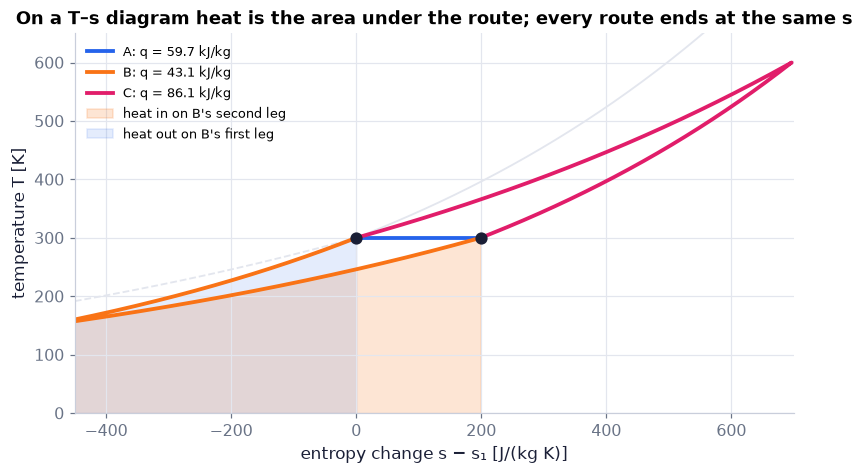

```python
fig, ax = plt.subplots(figsize=(7.2, 4.2))                                        # one T–s diagram
s_rel = lambda T, v: ch01.perfect_gas_entropy_change(300.0, v1, T, v)             # entropy relative to state 1 [J/(kg K)]
ss = np.linspace(-450, 700, 200)                                                  # entropy range for the guide lines
ax.plot(ss, 300.0 * np.exp(ss / ch01.CV_AIR), color=COLORS["grid"], lw=1.2)        # isochore through state 1: T ∝ e^{s/C_v}
ax.plot(ss, 300.0 * np.exp(ss / ch01.CP_AIR), color=COLORS["grid"], lw=1.2, ls="--")  # isobar through state 1: T ∝ e^{s/C_p}
for kind, label in routes.items():                                                # the three routes of C25
    path = ch01.process_path(kind, (v1, 300.0), (2 * v1, 300.0))                  # sampled route (v, T)
    ax.plot(s_rel(path["T"], path["v"]), path["T"], color=colors[kind], lw=2.5, label=f"{label[:1]}: q = {tot[kind]['q']/1e3:.1f} kJ/kg")  # T against s
sB, TB = s_rel(path_B["T"], path_B["v"]), path_B["T"]                             # route B in the T–s plane
ax.fill_between(sB[leg2:], 0, TB[leg2:], color=COLORS["orange"], alpha=0.18, label="heat in on B's second leg")     # ∫T ds > 0
ax.fill_between(sB[:leg2 + 1], 0, TB[:leg2 + 1], color=COLORS["blue"], alpha=0.12, label="heat out on B's first leg")  # ∫T ds < 0
ax.plot([0, s_rel(300.0, 2 * v1)], [300, 300], "o", color=COLORS["ink"], ms=7)    # states 1 and 2
ax.set_xlim(-450, 700); ax.set_ylim(0, 650)                                       # fixed axes, T from 0 so areas are honest
ax.set_xlabel("entropy change s − s₁ [J/(kg K)]"); ax.set_ylabel("temperature T [K]")   # axis labels with units
ax.set_title("On a T–s diagram heat is the area under the route; every route ends at the same s")   # the message
ax.legend(loc="upper left", fontsize=8.5)                                         # legend
plt.show()                                                                        # display
```

**What you see.** The three routes of C25 redrawn with temperature against entropy: all start at s − s₁ = 0 and all end at the same point, 199 J/(kg K) to the right. The faint solid line is the isochore through state 1, the faint dashed line the isobar.

**How to read it.** On a T–s diagram the heat of a reversible route is the area under it (∫T ds). Route B gives heat away on its first leg (blue area) and takes more in on its second (orange area); the net is its 43 kJ/kg. Different areas mean different q, yet all routes share one Δs.

**What would change if…** A reversible adiabatic route has ds = 0, so it would be a vertical line on this diagram — the isentrope of C45.

**What would change if…** the process were not reversible (friction)? The Gibbs relations would still give Δs, because they only link state functions; only T ds = dq fails. **Next:** how stiff a fluid is when squeezed at constant entropy sets the speed of sound (C36).

### 🧩 The speed of sound: stiffness at constant entropy `C36`

*The question:* Why does a sound pulse cross 340 m of air in one second, but about 1480 m of water?

#### The problem in plain words

Thunder arrives after the lightning; sonar measures ocean depth; weather models filter sound waves out. More important for this book: comparing a flow's speed with the speed of sound decides whether density changes can be ignored — the incompressible approximation of Ch. 4 §4.9 — and the speed of sound is where Ch. 15 starts.

#### The idea

A pressure push squeezes the next layer of fluid, which pushes the next… The signal travels faster the **stiffer** the fluid (more pressure change per density change) and slower the more **inertia** it has. The squeeze is far too quick for heat to flow, so the stiffness is measured at constant entropy.

| squeeze by Δp = 1 kPa | fractional density change Δρ/ρ |
| --- | --- |
| air at 1 atm | ≈ 0.7 % |
| water | ≈ 4.5×10⁻⁷ |

#### The maths, step by step

1. **Which speed can there be?** The only properties that matter are the stiffness ∂p/∂ρ [Pa per kg/m³ = m²/s²] and the density. A stiffness already has the units of a speed squared, so the signal speed must be a number times √(∂p/∂ρ) (dimensional reasoning, previewing C64).
2. **Why the number is 1 — a piston push (plausibility, not a proof).** Push a piston of area A into still fluid at a small speed u. After a time t a pressure front has travelled ct and all the fluid behind it moves at u.
   - *Mass:* the fluid that filled the length ct now fills ct − ut, so its density has risen by Δρ ≈ ρu/c.
   - *Momentum:* the extra pressure Δp acting on A for the time t gave the mass ρAct the speed u, so Δp·A·t = ρAct·u, i.e. Δp = ρcu.
   - *Stiffness:* Δp = (∂p/∂ρ)Δρ = (∂p/∂ρ)ρu/c. Equating the two expressions for Δp gives c² = ∂p/∂ρ. The squeeze is too fast for heat to flow, so the stiffness is measured with entropy held fixed (P39). The full proof is in Ch. 15 §15.2: $$c^2 = \left(\frac{\partial p}{\partial \rho}\right)_s \qquad (1.19) \quad [\mathrm{m^2/s^2}]$$
3. Define the bulk modulus $K \equiv \rho\,(\partial p/\partial\rho)_s$ [Pa]: how many pascals per *fractional* density change. Then c² = K/ρ.
4. For air squeezed isentropically, $p = p_0(\rho/\rho_0)^\gamma$ (derived in C45), so $\partial p/\partial\rho = \gamma p_0\rho^{\gamma-1}/\rho_0^\gamma = \gamma p/\rho$ and K = γp.
5. For water K ≈ 2.2 GPa (the modified Tait model, `tait_pressure`).
6. **Incompressible limit:** if ∂ρ/∂p → 0 then ∂p/∂ρ → ∞ and c → ∞ — a pressure change is felt everywhere at once.

#### ✏️ Tiny example: air and water

- Air at 101 325 Pa, 1.225 kg/m³, γ = 1.4: c² = γp/ρ = 1.4 × 101 325/1.225 = 115 800 m²/s² → c = 340.3 m/s.
- Water: c = √(K/ρ) = √(2.2×10⁹/1000) = 1483 m/s.
- Compressing water by 1 % needs Δp = 0.01K = 22 MPa — the pressure about 2.2 km down in the ocean.

```python
P_air = lambda rho, s: ch01.isentropic_pressure(rho, ch01.P_ATM, 1.225)   # air along its isentrope p = p0 (ρ/ρ0)^γ [Pa]
P_water = lambda rho, s: ch01.tait_pressure(rho)                         # water: modified Tait equation of state [Pa]
c_air = ch01.sound_speed_from_eos(P_air, 1.225)                          # Eq. (1.19): sqrt of dp/dρ at fixed s [m/s]
c_water = ch01.sound_speed_from_eos(P_water, 1000.0)                     # the same for water [m/s]
print(f"air {c_air:.2f} m/s, water {c_water:.1f} m/s, perfect-gas formula {ch01.perfect_gas_sound_speed(288.15):.2f} m/s")   # three speeds of sound
```

```
air 340.29 m/s, water 1483.2 m/s, perfect-gas formula 340.30 m/s
```

**What does the code above do?**

1. Each equation of state is passed as a function p(ρ, s) (primer P29); the entropy argument is not used because both functions already describe one isentrope.
2. `sound_speed_from_eos` differentiates p with respect to ρ at fixed s and takes the square root — $c^2 = (\partial p/\partial\rho)_s$ (1.19).
3. `perfect_gas_sound_speed` is the closed form √(γRT) that C47 derives; it agrees with the air value.

#### From scratch: a central difference of the equation of state

```python
c_mine = []                                                        # our speeds of sound [m/s]
for P, rho0 in ((P_air, 1.225), (P_water, 1000.0)):                # the two fluids
    drho = 1e-6 * rho0                                             # a tiny density step [kg/m³]
    slope = (P(rho0 + drho, 0.0) - P(rho0 - drho, 0.0)) / (2 * drho)   # central difference (P21) of p(ρ) = (∂p/∂ρ)_s
    c_mine.append(np.sqrt(slope))                                  # c = sqrt(slope), Eq. (1.19)
assert np.allclose(c_mine, [c_air, c_water], rtol=1e-6)            # same as the library
assert np.isclose(c_mine[0], ch01.perfect_gas_sound_speed(288.15), rtol=1e-4)   # and as √(γRT) for air at 15 °C
print(f"mine: air {c_mine[0]:.2f} m/s, water {c_mine[1]:.1f} m/s")   # ours
```

```
mine: air 340.29 m/s, water 1483.2 m/s
```

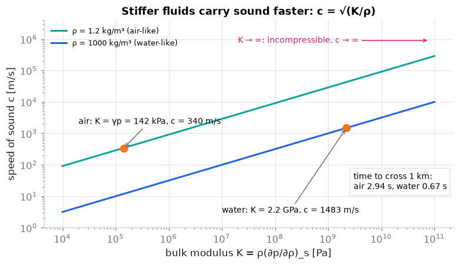

```python
K = np.logspace(4, 11, 200)                                               # bulk moduli from 10 kPa to 100 GPa [Pa]
fig, ax = plt.subplots(figsize=(7, 4))                                    # one log–log panel
for rho_c, col, lab in ((1.2, COLORS["teal"], "ρ = 1.2 kg/m³ (air-like)"), (1000.0, COLORS["blue"], "ρ = 1000 kg/m³ (water-like)")):  # two densities
    ax.loglog(K, np.sqrt(K / rho_c), color=col, label=lab)               # c = sqrt(K/ρ): slope ½ on log–log axes
K_air = ch01.GAMMA_AIR * ch01.P_ATM                                        # air's isentropic bulk modulus γp [Pa]
ax.loglog([K_air], [c_air], "o", color=COLORS["orange"], ms=8)             # air marked
ax.annotate(f"air: K = γp = {K_air/1e3:.0f} kPa, c = {c_air:.0f} m/s", (K_air, c_air), (2e4, 2e3), fontsize=9,   # label text and position
            arrowprops=dict(arrowstyle="->", color=COLORS["muted"]))      # arrow from the label to the point
ax.loglog([2.2e9], [c_water], "o", color=COLORS["orange"], ms=8)           # water marked
ax.annotate(f"water: K = 2.2 GPa, c = {c_water:.0f} m/s", (2.2e9, c_water), (1e7, 3e0), fontsize=9,   # label text and position
            arrowprops=dict(arrowstyle="->", color=COLORS["muted"]))      # arrow from the label to the point
ax.annotate("K → ∞: incompressible, c → ∞", (8e10, 9e5), (2e7, 9e5), fontsize=9, color=COLORS["rose"], va="center",   # the limit
            arrowprops=dict(arrowstyle="->", color=COLORS["rose"]))       # arrow pointing to ever larger K
ax.set_xlabel("bulk modulus K = ρ(∂p/∂ρ)_s [Pa]"); ax.set_ylabel("speed of sound c [m/s]")   # axis labels with units
ax.text(3e9, 60, f"time to cross 1 km:\nair {1000/c_air:.2f} s, water {1000/c_water:.2f} s",   # what c means in practice
        fontsize=9, va="top", bbox=dict(facecolor="white", edgecolor=COLORS["grid"]))
ax.set_ylim(1, 4e6)                                                        # headroom above the lines for the limit label
ax.set_title("Stiffer fluids carry sound faster: c = √(K/ρ)")             # the message
ax.legend(loc="upper left", fontsize=8.5)                                  # legend
plt.show()                                                                 # display
```

**What you see.** Two parallel straight lines of slope ½ on log–log axes, one for a light and one for a heavy fluid, with air and water marked, an arrow toward infinite stiffness, and a box giving the time sound needs to cross 1 km in each (about 3 s in air, under 0.7 s in water — the "count the seconds after lightning" rule).

**How to read it.** Along a line (same density) a fluid 100× stiffer carries sound 10× faster. Water is about 15 000× stiffer than air but also 800× denser, so its sound speed is only about √(15 000/800) ≈ 4.4× larger.

**What would change if…** Heating air raises p at fixed ρ, hence K = γp and c; for a perfect gas c ∝ √T (C47). Squeezing water harder barely changes its K, which is why the ocean's sound speed varies by only a few per cent.

📝 **Note.** **The thermal expansion coefficient** `C37` — α [1/K] is the same kind of held-fixed derivative, at constant pressure: the fractional density drop per kelvin of warming. Water is strange: α(20 °C) = +2.07×10⁻⁴ K⁻¹ but α(2 °C) = −3.3×10⁻⁵ K⁻¹ — below about 4 °C water contracts when warmed, which is why lakes freeze from the top. α returns in the adiabatic lapse rate (C54) and in the Boussinesq approximation (Ch. 4).

$$ \alpha \equiv -\frac{1}{\rho}\left(\frac{\partial \rho}{\partial T}\right)_p \qquad \text{(1.20)} $$

```python
alpha_w = ch01.thermal_expansion_coefficient(lambda T, p: ch01.water_density(T), np.array([275.15, 293.15]), 1e5)  # (1.20)
print(f"water: α(2 °C) = {alpha_w[0]:.2e} 1/K, α(20 °C) = {alpha_w[1]:.2e} 1/K")   # negative below 4 °C, positive above
```

```
water: α(2 °C) = -3.27e-05 1/K, α(20 °C) = 2.07e-04 1/K
```

**What does the code above do?**

`thermal_expansion_coefficient` differentiates a density function ρ(T, p) at fixed p and divides by −ρ, $\alpha \equiv -\rho^{-1}(\partial\rho/\partial T)_p$ (Eq. 1.20); the water density correlation ignores p, which is fine at 1 bar.

**What would change if…** the fluid were a perfect gas? Then K = γp = γρRT and c = √(γRT) depends on temperature only — §1.9 makes this and α = 1/T explicit. **Next:** the perfect-gas law itself (C40).

## 1.9 Perfect Gas

**What is this section about?** The equation of state of air and of most gases at ordinary conditions, and what follows from it: R from the molecular weight, C_p − C_v = R, the isentropic law, and the speed of sound and expansion coefficient of a gas. (The isothermal atmosphere and the scale height of book §1.10 are stated here, in C40, because they are just p = ρRT combined with hydrostatics.)

### 🧩 The perfect-gas law in continuum form: p = ρRT `C40`

*The question:* The molecular gas law counts molecules in a box. How does it become a law for the density at a point?

#### The problem in plain words

Aircraft performance, weather-balloon soundings, the air density in a drag formula, altimeters, every atmospheric model: all need density from pressure and temperature. The molecular law is written for a container full of molecules; we need it for a fluid particle.

#### The idea

```
p = (N/V) k_B T  →  multiply and divide by m  →  ρ (k_B/m) T  →  m = M_w/A_o  →  ρ (R_u/M_w) T  =  ρ R T
    molecules per volume           continuum density (C06)       per kilomole (P07)      one gas constant per gas
```

T is always the absolute temperature in kelvin here (recap R03 in §1.2).

📝 **Note.** **The molecular perfect-gas law** `C38` — For n non-interacting molecules in a volume V at absolute temperature T — the result D34 (C06) derived from wall impacts. It holds when attractions between molecules are negligible and each molecule's own volume is tiny compared with V/n. One cubic metre of sea-level air (n = 2.55×10²⁵ molecules at 288.15 K) gives p = 1.013×10⁵ Pa.

$$ pV = n\,k_B T \qquad \text{(1.21)} $$

> ⚠️ **Common confusion — the symbol n switches meaning.** In §1.4 (P07, C04, D34) n was a *number density* [molecules per m³]. In $pV = n\,k_B T$ (1.21) and in D11 below, n is a *count* of molecules [–], and the number density is n/V. Same letter, different quantity — watch the units.

📝 **Note.** **The constants** `C39` — (CODATA, exact since 2019) k_B = 1.380 649×10⁻²³ J/K; Avogadro's number per kilomole A_o = 6.022 140 76×10²⁶ kmol⁻¹; universal gas constant R_u = k_BA_o = 8314.46 J kmol⁻¹ K⁻¹; dry air M_w = 28.9644 kg/kmol (US Standard Atmosphere 1976), so R = R_u/M_w = 287.06 J kg⁻¹ K⁻¹. (Kilomoles: primer P07.)

#### 🧮 Derivation — From the molecular gas law to p = ρRT (Eq. 1.22)

**What we want to show.** Rewrite the molecule-counting gas law as a law for the continuum density, with one constant R per gas.

**Assumptions.** Perfect gas: non-interacting molecules (the start) · Kn ≪ 1, so nm/V is a continuum density (step 3) · one average molecular weight for a mixture such as air (step 4).

**The plan.**

1. Divide by V.
2. Create the density ρ = nm/V.
3. Replace one molecule's mass by M_w/A_o.
4. Name the constants.

**Tools we use** (each explained before this point): $pV = n\,k_B T$ (1.21) (C38, derived in D34) · continuum density (C06) · mole, kilomole, molecular weight and Avogadro's number (P07) · constants k_B, A_o, R_u (C39)

**We start from**

$$ pV = n\,k_B T $$

*In words:* n non-interacting molecules in a volume V at temperature T exert the pressure p (1.21); here n counts molecules, as in the book, so n/V is the number density (which §1.4 itself called n — see the warning above).

**Step 1 of 7 — Divide by the volume.**

$$ p = \dfrac{n}{V}\,k_B T $$

- *Why we can do this:* Divide both sides by V ≠ 0; pressure is a local quantity and should not depend on how big a container we imagine.
- *In words:* Pressure = molecules per volume × k_B × T.

**Step 2 of 7 — Multiply and divide by the molecular mass.**

$$ p = \dfrac{n\,m}{V}\,\dfrac{k_B}{m}\,T $$

- *Why we can do this:* m/m = 1 changes nothing; we do it so that nm/V — mass per volume — appears in the formula.
- *In words:* The same law, rearranged to expose mass.

**Step 3 of 7 — Recognise the density.**

$$ p = \rho\,\dfrac{k_B}{m}\,T $$

- *Why we can do this:* nm/V is the total molecular mass per volume, the continuum density of C06 (valid for boxes in the continuum window, Kn ≪ 1).
- *In words:* Density replaces the molecule count.

**Step 4 of 7 — Write one molecule's mass per kilomole.**

$$ \dfrac{k_B}{m} = \dfrac{k_B A_o}{M_w} $$

- *Why we can do this:* One kilomole of molecules (A_o of them) has a mass of M_w kg, so m = M_w/A_o (P07); dividing by a fraction multiplies by its inverse.
- *In words:* Mass of one molecule = molecular weight ÷ Avogadro's number.

**Step 5 of 7 — Substitute into step 3.**

$$ p = \rho\,\dfrac{k_B A_o}{M_w}\,T $$

- *Why we can do this:* Replace k_B/m in step 3 by its equal from step 4; substituting equals keeps the equation true and removes the mass of a single molecule from the law.
- *In words:* The law now contains only the density, measurable constants and T.

**Step 6 of 7 — Name the universal gas constant.**

$$ p = \rho\,\dfrac{R_u}{M_w}\,T,\qquad R_u \equiv k_B A_o $$

- *Why we can do this:* k_BA_o = 1.380649×10⁻²³ J/K × 6.02214076×10²⁶ kmol⁻¹ = 8314.46 J kmol⁻¹ K⁻¹ is the same for every gas; naming it shortens the law.
- *In words:* One universal constant divided by the gas's molecular weight.

**Step 7 of 7 — Name the gas constant of this gas.**

$$ p = \rho R T,\qquad R \equiv R_u/M_w $$

- *Why we can do this:* For a given gas R_u/M_w is a single number (air: 8314.46/28.9644 = 287.06 J kg⁻¹ K⁻¹), so we give it one symbol.
- *In words:* The perfect-gas law per unit mass.

**Result**

$$ p = \rho R T $$

*In words:* pressure = density × gas constant × absolute temperature.

**What it means.** Every atmospheric calculation in the book closes with this law. It fails when molecules attract each other or fill a noticeable part of the volume — dense gases, gases near condensation (the van der Waals contrast in C41).

**Check it.** Units: kg m⁻³ · J kg⁻¹ K⁻¹ · K = J m⁻³ = Pa ✓. Number: ρ = 101 325/(287.06 × 288.15) = 1.225 kg/m³ ✓ (`perfect_gas_density`, and the from-scratch constants chain below). A mixture: dry air treated as one gas with M_w = 28.96 ✓.

> ⚠️ **Common confusion (traps in this derivation):** mixing mol and kmol (R_u = 8.314 J mol⁻¹ K⁻¹ vs 8314 J kmol⁻¹ K⁻¹, a factor 1000); confusing R_u with R; using °C for T.

#### ✏️ Tiny example: air density on three days

- Sea level, 15 °C: $\rho = p/(RT) = 101\,325/(287.06 \times 288.15) = 1.225$ kg/m³.
- A hot day, 35 °C: $\rho = 101\,325/(287.06 \times 308.15) = 1.145$ kg/m³ (6.5 % less).
- A high plateau, 84 kPa and 15 °C: $\rho = 84\,000/(287.06 \times 288.15) = 1.016$ kg/m³ — aircraft need longer runways there.

```python
print(ch01.gas_constant(ch01.M_W_AIR))                           # R = R_u / M_w for dry air [J/(kg K)] → 287.058
p_days = np.array([101325.0, 101325.0, 84000.0])                 # pressures of the three days [Pa]
T_days = np.array([288.15, 308.15, 288.15])                      # temperatures [K]
rho_days = ch01.perfect_gas_density(p_days, T_days)              # Eq. (1.22) solved for ρ [kg/m³]
print(rho_days)                                                  # [1.225  1.1455 1.0155]
print(ch01.perfect_gas_state(p=101325.0, T=288.15))              # fill in the missing ρ: (p, ρ, T)
print(ch01.perfect_gas_pressure(1.225, 288.15))                  # and back to p = ρRT [Pa] → 101 327
```

```
287.0579959589441
[1.225  1.1455 1.0155]
(101325.0, 1.2249781434512679, 288.15)
101326.80788107293
```

**What does the code above do?**

1. `gas_constant` divides R_u by the molecular weight (step 7 of D11).
2. `perfect_gas_density` is $p = \rho R T$ (1.22) solved for ρ, applied to three days at once.
3. `perfect_gas_state` returns whichever of p, ρ, T is missing; `perfect_gas_pressure` is $p = \rho R T$ (1.22) itself.

#### From scratch: the constants chain

```python
R_mine = ch01.K_B * ch01.N_A_KMOL / ch01.M_W_AIR                  # D11 steps 4–7: R = k_B A_o / M_w [J/(kg K)]
rho_mine = p_days / (R_mine * T_days)                             # ρ = p / (R T) [kg/m³]
assert np.allclose(rho_mine, ch01.perfect_gas_density(p_days, T_days))    # same as the library
n_days = p_days / (ch01.K_B * T_days)                             # the molecular route: n/V = p/(k_B T) [1/m³] (D34)
rho_molecular = n_days * ch01.molecular_mass(ch01.M_W_AIR)        # ρ = (n/V) m [kg/m³]
assert np.allclose(rho_molecular, rho_mine)                       # counting molecules gives the same density
print(rho_mine, rho_molecular)   # both routes: [1.225 1.1455 1.0155] kg/m³
```

```
[1.225  1.1455 1.0155] [1.225  1.1455 1.0155]
```

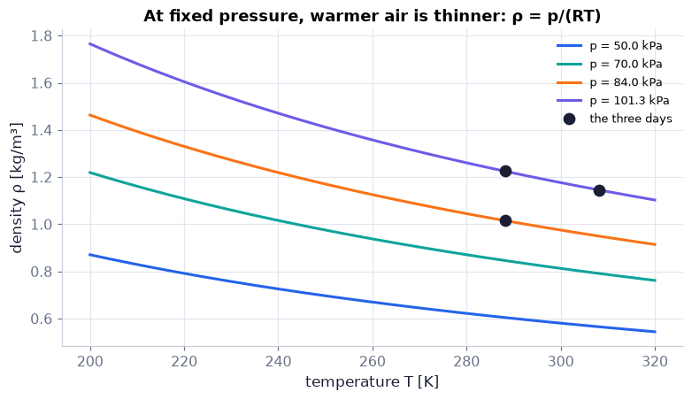

```python
T_grid = np.linspace(200, 320, 200)                                        # temperatures [K]
fig, ax = plt.subplots(figsize=(7, 4))                                     # one panel
for p_iso, col in ((50e3, COLORS["blue"]), (70e3, COLORS["teal"]), (84e3, COLORS["orange"]), (101325.0, COLORS["accent"])):   # four pressures [Pa]
    ax.plot(T_grid, ch01.perfect_gas_density(p_iso, T_grid), color=col, label=f"p = {p_iso/1e3:.1f} kPa")   # isobar ρ(T)
ax.plot(T_days, rho_days, "o", color=COLORS["ink"], ms=8, label="the three days")                        # worked example
ax.set_xlabel("temperature T [K]"); ax.set_ylabel("density ρ [kg/m³]")                                   # labels with units
ax.set_title("At fixed pressure, warmer air is thinner: ρ = p/(RT)")                                     # the message
ax.legend(fontsize=8.5)                                                                                  # legend
plt.show()                                                                                               # display
```

**What you see.** Four falling curves, one per pressure (50, 70, 84 and 101.3 kPa), with the three worked-example days marked as black dots: two on the sea-level curve, one on the 84 kPa curve.

**How to read it.** Along one curve (fixed p) the density is inversely proportional to T. The vertical spacing between curves at one T shows ρ ∝ p. The plateau day sits on the 84 kPa curve, below the two sea-level days.

**What would change if…** Humid air has a smaller mean molecular weight (water vapour 18 < 28.96), hence a larger R and a lower density at the same p and T — humid air is lighter than dry air.

> 📎 **Primer — plotly 3-D surface.** `P41` · `go.Figure(go.Surface(x=…, y=…, z=…))` draws a surface you can rotate with the mouse; `go.Scatter3d` adds points or lines on top. The published page keeps it interactive without Python.

```python
import plotly.graph_objects as go                          # plotly's figure objects
xg, yg = np.meshgrid(np.linspace(-1, 1, 10), np.linspace(-1, 1, 10))   # a 10 × 10 grid of (x, y) points
fig = go.Figure(go.Surface(x=xg, y=yg, z=xg**2 + yg**2, showscale=False))   # the paraboloid z = x² + y²
fig.update_layout(height=320, margin=dict(l=0, r=0, t=10, b=0))            # compact
fig.show()                                                                  # drag to rotate
```

[interactive chart not shown]

```python
vg, Tg = np.meshgrid(np.linspace(0.5, 2.0, 40), np.linspace(200, 350, 40))        # a 40 × 40 grid of states (v, T)
pg = ch01.perfect_gas_pressure(1 / vg, Tg) / 1e3                                  # p = ρRT with ρ = 1/v [kPa]
fig = go.Figure(go.Surface(x=vg, y=Tg, z=pg, colorscale="Viridis", opacity=0.85, showscale=False, name="p(v, T)"))  # the surface
for kind in routes:                                                               # the three C25 routes as curves on it
    path = ch01.process_path(kind, (v1, 300.0), (2 * v1, 300.0), n=81)            # 81 samples per route
    fig.add_trace(go.Scatter3d(x=path["v"], y=path["T"], z=path["p"] / 1e3, mode="lines",   # a 3-D line on the surface
                               line=dict(color=colors[kind], width=6), name=routes[kind][:1]))   # route colour and label
fig.add_trace(go.Scatter3d(x=[v1], y=[300.0], z=[100.0], mode="markers", marker=dict(color="red", size=6), name="state 1"))  # the dot
fig.update_layout(height=520, margin=dict(l=0, r=0, t=40, b=0), title="Every state of air is a point on p = RT/v",   # size, title
                  scene=dict(xaxis_title="v [m³/kg]", yaxis_title="T [K]", zaxis_title="p [kPa]"))                 # axis labels
fig.show()                                                                        # rotate and hover
```

[interactive chart not shown]

**What does the code above do?**

1. `perfect_gas_pressure` evaluates p = ρRT on a grid of specific volumes and temperatures: the surface of all equilibrium states of air.
2. The three routes of C25 are drawn on the surface: a process is a curve on it, and "two properties fix the state" (C28) means that choosing (v, T) picks exactly one point.

**What you see.** A curved surface of pressure over the plane of specific volume and temperature, the three coloured routes of C25 lying on it, and a red dot for state 1.

**How to read it.** Height above the (v, T) floor is the pressure. Moving along the T direction at fixed v the surface rises in a straight line (p ∝ T); moving along v at fixed T it falls like 1/v. Every route between states stays on the surface, because every equilibrium state does.

**What would change if…** A van der Waals gas (C41) would give a slightly different surface that sags at moderate v, where molecular attraction lowers the pressure (very close to the volume b taken up by the molecules themselves it would instead shoot up).

📝 **Note.** **A perfect gas stores energy in temperature only** `C41` — For a perfect gas the internal energy and the enthalpy depend on **temperature only**, and conversely only a perfect gas has this property (stated; the proof combines the Gibbs relations with p = ρRT to show (∂e/∂v)_T = 0). A real gas with molecular attractions does not: for CO₂ modelled as a van der Waals gas, e = C_vT − a/v, so squeezing it from 0.1 to 0.01 m³/kg at a fixed 300 K lowers e by 16.9 kJ/kg (code below).

$$ e = e(T), \qquad h = h(T) $$

📝 **Note.** **The expansion coefficient of a perfect gas** `C48` — At fixed p, ρ = p/(RT) ∝ 1/T, so (stated) the expansion coefficient $\alpha \equiv -\rho^{-1}(\partial\rho/\partial T)_p$ (1.20) is simply 1/T: 3.3×10⁻³ K⁻¹ for air at 300 K — sixteen times that of water at 20 °C.

$$ \alpha = \frac{1}{T} \qquad \text{(1.28)} $$

📝 **Note.** **The isothermal atmosphere (book §1.10)** `C62` — If a layer of atmosphere had one temperature T, hydrostatics $dp/dz = -\rho g$ (1.8) with ρ = p/(RT) would give dp/p = −(g/RT)dz, and (stated) pressure falls exponentially with height. Why is one temperature a fair first guess? Over roughly the lowest 50 km the standard atmosphere's temperature stays within a band of about ±15 % around 250 K (the code below finds a largest deviation of about 15 %), so read the isothermal model as an **order-of-magnitude** description, not a close fit. At 5 km with T = 250 K our model gives p = 51.2 kPa, while the US Standard Atmosphere has 54.0 kPa — 5 % more, because the real lower atmosphere is warmer than 250 K.

$$ p(z) = p_0\,e^{-gz/RT} $$

📝 **Note.** **The scale height (book §1.10)** `C63` — The height over which the isothermal pressure falls by a factor e (one e-folding, P36) is the **scale height**. For T = 250 K our `scale_height` gives 287.06 × 250/9.807 ≈ 7.32 km — a good one-number thickness of the atmosphere.

$$ H = \frac{RT}{g} $$

```python
print(f"C63 scale height at 250 K: {ch01.scale_height(250.0):.0f} m")                            # H = RT/g
print(f"C62 isothermal p at 5 km, 250 K: {ch01.isothermal_pressure(5000.0, ch01.P_ATM, 250.0):.0f} Pa")  # p0 e^(−gz/RT)
print("C62 USSA-1976 (T, p, ρ) at 5 km geopotential height:", ch01.standard_atmosphere(5000.0))       # the standard atmosphere
T_50 = ch01.standard_atmosphere(np.linspace(0, 50e3, 501))[0]                                     # USSA temperatures, 0–50 km [K]
print(f"C62 largest deviation of the USSA temperature from 250 K below 50 km: {np.max(np.abs(T_50/250 - 1)):.1%}")  # ≈ 15 %
print(f"C48 α of air at 300 K: {ch01.perfect_gas_expansion_coefficient(300.0):.2e} 1/K")          # 1/T
de_vdw = (ch01.van_der_waals_internal_energy(300.0, 0.1, ch01.VDW_CO2["a"], 655.0)                # C41: e at v = 0.1 m³/kg …
          - ch01.van_der_waals_internal_energy(300.0, 0.01, ch01.VDW_CO2["a"], 655.0))            # … minus e at 0.01 m³/kg [J/kg]
print(f"C41 van der Waals CO₂ squeezed 0.1 → 0.01 m³/kg at 300 K: e drops by {de_vdw:.0f} J/kg")  # a real gas: e depends on v
z_iso = np.linspace(0, 40e3, 161)                                                                  # heights [m]
p_ussa = ch01.standard_atmosphere(z_iso)[1] / 1e3                                                 # USSA pressure [kPa]
def iso(T):                                                                                        # one slider position
    H = ch01.scale_height(T)                                                                       # scale height [m]
    return {"isothermal p(z)": (z_iso / 1e3, ch01.isothermal_pressure(z_iso, ch01.P_ATM, T) / 1e3),   # the model [km, kPa]
            "US Standard Atmosphere 1976": (z_iso / 1e3, p_ussa),                                   # the reference, fixed
            "p₀/e at z = H": ([H / 1e3], [ch01.P_ATM / np.e / 1e3])}                                # one e-folding up
fig = slider_figure(iso, "T", np.linspace(200, 300, 21), unit="K", xlabel="height z [km]", ylabel="pressure p [kPa]",  # 21 steps
                    title="One temperature gets the shape of p(z) roughly right", modes={"p₀/e at z = H": "markers"}, active=10)   # start at 250 K
fig.show()                                                                                         # drag T
```

```
C63 scale height at 250 K: 7318 m
C62 isothermal p at 5 km, 250 K: 51166 Pa
C62 USSA-1976 (T, p, ρ) at 5 km geopotential height: (255.64999999999998, 54020.49492314558, 0.7361106703542685)
C62 largest deviation of the USSA temperature from 250 K below 50 km: 15.3%
C48 α of air at 300 K: 3.33e-03 1/K
C41 van der Waals CO₂ squeezed 0.1 → 0.01 m³/kg at 300 K: e drops by 16914 J/kg
```

[interactive chart not shown]

**What does the code above do?**

1. The printed lines are the numbers quoted in the C41, C48, C62 and C63 notes, computed now.
2. For each slider temperature the figure shows the isothermal model p₀e^(−gz/RT) (`isothermal_pressure`), the fixed US Standard Atmosphere profile, and a marker where the model has fallen to p₀/e — at z = H.

**What you see.** A falling exponential p(z) for the chosen temperature, the fixed US Standard Atmosphere profile, and a marker where the model's pressure has dropped to p₀/e.

**How to read it.** The marker's height is the scale height H = RT/g. Where the two curves overlap, one temperature describes the real atmosphere well; where they separate, the real temperature profile matters.

**What would change if…** At 200 K the model falls too quickly (H ≈ 5.9 km), at 300 K too slowly (H ≈ 8.8 km): the scale height is proportional to T.

**What would change if…** the gas were squeezed too quickly for heat to escape? Its temperature would rise, and p would climb faster than ρ. **Next:** the isentropic law (C45).

### 🧩 The isentropic law: p/ρ^γ = const `C45`

*The question:* Squeeze a gas quickly — no time for heat to leak out and no friction. How does its pressure follow its density?

#### The problem in plain words

A bicycle pump's barrel heats up; a diesel engine ignites its fuel by compression alone; a rising air parcel cools as it expands (§1.10); sound is a rapid squeeze. All follow the same power law.

#### The idea

| squeeze to 2× the density | isothermal (heat leaks out) | isentropic (no heat, no friction) |
| --- | --- | --- |
| pressure ratio | 2 | 2^1.4 = 2.64 |
| temperature | unchanged | × 2^0.4 = 1.32 |

**The work done on the gas stays in it as internal energy, so the pressure climbs faster.** On log–log axes: slope 1 versus slope γ.

📝 **Note.** **R = C_p − C_v** `C42` — For a perfect gas h = e + pv = e + RT, and e and h depend on T only (C41), so the partial derivatives in $C_p \equiv (\partial h/\partial T)_p$ (1.14) and $C_v \equiv (\partial e/\partial T)_v$ (1.15) become ordinary ones (*gloss:* a total derivative d/dT, because nothing else varies). Differentiating h = e + RT with respect to T gives (stated) the gap between the specific heats: 1004.7 − 717.6 = 287.1 J kg⁻¹ K⁻¹.

$$ R = C_p - C_v \qquad \text{(1.23)} $$

📝 **Note.** **The ratio of specific heats** `C43` — Kinetic theory with rigid molecules gives γ = 5/3 for monatomic gases (He, Ar), 7/5 for linear molecules — all diatomic ones (N₂, O₂, air) and also linear CO₂ — and 4/3 for non-linear molecules such as H₂O. Real CO₂ comes out lower (about 1.3), because its molecular vibrations already store energy at room temperature. `ch01.GAMMA_BY_ATOMICITY` holds the rigid values.

$$ \gamma \equiv C_p/C_v \qquad \text{(1.24)} $$

📝 **Note.** **Air's values** `N16` — Air at ordinary temperatures: γ = 1.40 and C_p ≈ 1005 J kg⁻¹ K⁻¹ (our constant 1004.7 follows from γ = 1.4 and R). Both C_p and C_v rise slowly with temperature; we treat them as constants, which is what $p/\rho^\gamma = \text{const}$ (1.25) needs.

📝 **Note.** **Adiabatic versus isentropic** `C44` — **Adiabatic** = no heat crosses the boundary. **Isentropic** = adiabatic *and* frictionless, so s stays constant. Stirring an insulated gas is adiabatic but not isentropic (Δs = 23.5 J kg⁻¹ K⁻¹ in the C34 example).

> 📎 **Primer — separation of variables.** `P42` · For an equation like dy/y = k dx, put each variable on its own side and integrate both sides: ln y = kx + C, so y = y₀e^{kx}. For dp/p = γ dρ/ρ the same move gives ln p = γ ln ρ + C.

```python
print(np.log(2.0**1.4), 1.4 * np.log(2.0))   # ln(2^1.4) = 1.4 ln 2 = 0.9704: integrating dp/p = 1.4 dρ/ρ from ρ to 2ρ
```

```
0.9704060527839233 0.9704060527839233
```

> 🔁 Exponent rules — a^m a^n = a^(m+n), (a^m)^n = a^(mn), a^(−m) = 1/a^m, (a/b)^m = a^m/b^m — were primed in C06 (P43).

#### 🧮 Derivation — The isentropic law for a perfect gas (Eq. 1.25)

**What we want to show.** Find how pressure follows density when a perfect gas is compressed or expanded with no heat and no friction.

**Assumptions.** Isentropic — adiabatic and frictionless, ds = 0 (steps 1, 3) · perfect gas (steps 2, 4) · constant C_p and C_v, hence constant γ (step 10).

**The plan.**

1. Set ds = 0 in both forms.
2. Use e = e(T) and h = h(T) to bring in C_v and C_p.
3. Divide the two equations so that T drops out.
4. Switch from v to ρ and integrate.

**Tools we use** (each explained before this point): Gibbs relations (C35, D10) · e = e(T), h = h(T) for a perfect gas (C41) · C_p, C_v (C30, C31) · γ = C_p/C_v (C43) · differentials (P34) · separation of variables (P42) · natural logarithm (P36) · exponent rules (P43)

**We start from**

$$ T\,ds = de + p\,dv = dh - v\,dp $$

*In words:* the Gibbs relations (1.18), valid for any process.

**Step 1 of 11 — Set ds = 0 in the first Gibbs form.**

$$ 0 = de + p\,dv $$

- *Why we can do this:* Isentropic means s does not change, so T ds = 0 (T > 0). We start with the energy form because the work p dv appears in it.
- *In words:* All the work done on the gas goes into internal energy.

**Step 2 of 11 — Use e = e(T).**

$$ C_v\,dT = -p\,dv $$

- *Why we can do this:* For a perfect gas e depends on T only (C41), so the partial derivative in $C_v \equiv (\partial e/\partial T)_v$ (1.15) is an ordinary one and de = C_v dT; then move p dv to the other side.
- *In words:* Compression (dv < 0) warms the gas.

**Step 3 of 11 — Set ds = 0 in the second Gibbs form.**

$$ 0 = dh - v\,dp $$

- *Why we can do this:* The same isentropic condition T ds = 0 applied to the enthalpy form $T\,ds = dh - v\,dp$ of (1.18). We need a second equation, one that contains dp.
- *In words:* At constant entropy, enthalpy rises by v dp when the pressure rises.

**Step 4 of 11 — Use h = h(T).**

$$ C_p\,dT = v\,dp $$

- *Why we can do this:* For a perfect gas h depends on T only (C41), so the partial derivative in $C_p \equiv (\partial h/\partial T)_p$ (1.14) is an ordinary one and dh = C_p dT; then move v dp to the other side.
- *In words:* Raising the pressure warms the gas.

**Step 5 of 11 — Divide step 4 by step 2.**

$$ \dfrac{C_p}{C_v} = \dfrac{v\,dp}{-\,p\,dv} $$

- *Why we can do this:* Along a compression dT ≠ 0, so both sides of step 2 are nonzero and we may divide; dT cancels, which removes the temperature from the problem.
- *In words:* The ratio of specific heats links the pressure change to the volume change.

**Step 6 of 11 — Name the ratio γ.**

$$ \gamma = -\dfrac{v\,dp}{p\,dv} $$

- *Why we can do this:* $\gamma \equiv C_p/C_v$ by definition (1.24); the minus sign is moved to the front of the fraction.
- *In words:* γ measures how much faster p changes than v, in relative terms.

**Step 7 of 11 — Separate the variables.**

$$ \dfrac{dp}{p} = -\gamma\,\dfrac{dv}{v} $$

- *Why we can do this:* Multiply both sides by −dv/v; now each side contains only one variable (P42).
- *In words:* A 1 % decrease in volume raises the pressure by γ %.

**Step 8 of 11 — Switch from specific volume to density.**

$$ \dfrac{dv}{v} = -\dfrac{d\rho}{\rho} $$

- *Why we can do this:* v = 1/ρ gives dv = −dρ/ρ² (the derivative of 1/ρ); dividing by v = 1/ρ gives −dρ/ρ. Watch the sign: this is the classic slip.
- *In words:* A 1 % increase in density is a 1 % decrease in volume.

**Step 9 of 11 — Substitute into step 7.**

$$ \dfrac{dp}{p} = \gamma\,\dfrac{d\rho}{\rho} $$

- *Why we can do this:* Replace dv/v in step 7 by −dρ/ρ from step 8; the two minus signs cancel.
- *In words:* Relative pressure change = γ × relative density change.

**Step 10 of 11 — Integrate both sides with constant γ.**

$$ \ln p = \gamma\,\ln\rho + \text{const} $$

- *Why we can do this:* ∫dx/x = ln x (P36); γ can be taken outside the integral because C_p and C_v are constant (assumption).
- *In words:* On log–log axes p against ρ is a straight line of slope γ.

**Step 11 of 11 — Combine the logarithms and exponentiate.**

$$ \dfrac{p}{\rho^\gamma} = \text{const} $$

- *Why we can do this:* ln p − γ ln ρ = ln(p/ρ^γ) by the log and exponent rules (P43); if a logarithm is constant, so is its argument.
- *In words:* Along an isentrope p/ρ^γ never changes.

**Result**

$$ p/\rho^\gamma = \text{const} $$

*In words:* with no heat and no friction, a perfect gas whose C_p and C_v do not vary keeps p ∝ ρ^γ.

**What it means.** Work done on the gas has nowhere to go but internal energy, so the gas heats up and its pressure rises faster than in an isothermal squeeze (slope γ instead of 1). Combined with p = ρRT it gives the ratios $T/T_0 = (p/p_0)^{(\gamma-1)/\gamma}$, $\rho/\rho_0 = (p/p_0)^{1/\gamma}$ (1.26), hence θ (D20), and c = √(γRT) (C47). It fails with friction or heat exchange (stirring, slow compression in a conducting cylinder) and when C_p varies strongly with T. In the explainer `heat_work_paths` below, the bold isentropic route lies exactly on the faint isentrope.

**Check it.** Units: the constant carries Pa (m³/kg)^γ — fine, it is fixed by the starting state ✓. Limit γ → 1: p/ρ = const, the isothermal law (RT constant) ✓. Number: a pump from 1 to 2 bar, ρ₂/ρ₁ = 2^(1/1.4) = 1.641 and T₂ = 288.15 × 2/1.641 = 351.3 K ✓; the step-by-step integration of dp/dρ = γp/ρ below agrees with `isentropic_pressure` to 10⁻⁴.

> ⚠️ **Common confusion (traps in this derivation):** the sign of dv/v = −dρ/ρ; assuming constant C_p and C_v silently; dividing step 2 by step 4 and getting 1/γ.

#### ✏️ Tiny example: a bicycle pump from 1 bar to 2 bar

Start at 288.15 K.

1. Density ratio from $p/\rho^\gamma = \text{const}$ (1.25): ρ₂/ρ₁ = (p₂/p₁)^(1/γ) = 2^0.714 = 1.641.
2. Temperature from p = ρRT: T₂/T₁ = (p₂/p₁)(ρ₁/ρ₂) = 2/1.641 = 1.219 → T₂ = 351.3 K, 63 K hotter.
3. Isothermal comparison: the density ratio would be 2 and there would be no warming at all.

```python
T_ratio, rho_ratio = ch01.isentropic_ratios(2.0)                  # Eq. (1.26) for p2/p1 = 2: (T2/T1, ρ2/ρ1)
print(T_ratio, rho_ratio, 288.15 * T_ratio)                      # 1.2190 1.6407 → T2 = 351.26 K
rho1 = ch01.perfect_gas_density(1e5, 288.15)                     # starting density at 1 bar, 15 °C [kg/m³]
print(ch01.isentropic_pressure(rho_ratio * rho1, 1e5, rho1))     # Eq. (1.25): the pressure at the new density → 2.0e5 Pa
print(ch01.cv_from_cp(ch01.CP_AIR), ch01.gamma_from_cp(ch01.CP_AIR))   # (1.23)–(1.24): C_v = 717.64, γ = 1.4
print(ch01.perfect_gas_sound_speed(np.array([250.0, 288.15, 300.0])))  # (1.27): c at three temperatures [m/s]
```

```
1.2190136542044754 1.640670712015276 351.2587844590196
200000.0
717.6449898973603 1.4000000000000001
[316.9705 340.297  347.2238]
```

**What does the code above do?**

1. `isentropic_ratios` applies $T/T_0 = (p/p_0)^{(\gamma-1)/\gamma}$, $\rho/\rho_0 = (p/p_0)^{1/\gamma}$ (1.26) to a pressure ratio of 2 — the pump numbers.
2. `isentropic_pressure` is $p/\rho^\gamma = \text{const}$ (1.25): starting from (ρ₁, p₁), it returns p at any density on the same isentrope.
3. `cv_from_cp` and `gamma_from_cp` use R = C_p − C_v and γ = C_p/C_v.
4. `perfect_gas_sound_speed` is c = √(γRT) of C47, below.

#### From scratch: follow the isentrope in small steps

```python
n_steps = 20_000                                                   # Euler steps (primer P30)
rho_grid = np.linspace(rho1, rho_ratio * rho1, n_steps + 1)        # densities from ρ1 to 1.641 ρ1 [kg/m³]
p_mine = np.empty(n_steps + 1); p_mine[0] = 1e5                    # start at 1 bar
for k in range(n_steps):                                           # step dp = γ p dρ/ρ (D14 step 9)
    p_mine[k + 1] = p_mine[k] + ch01.GAMMA_AIR * p_mine[k] / rho_grid[k] * (rho_grid[k + 1] - rho_grid[k])   # p_{k+1} = p_k + γ p_k Δρ/ρ_k
assert np.allclose(p_mine, ch01.isentropic_pressure(rho_grid, 1e5, rho1), rtol=1e-4)   # matches (1.25) everywhere
print(f"Euler end pressure {p_mine[-1]:.1f} Pa vs isentropic law {ch01.isentropic_pressure(rho_grid[-1], 1e5, rho1):.1f} Pa")   # hand integration vs (1.25)
```

```
Euler end pressure 199999.3 Pa vs isentropic law 200000.0 Pa
```

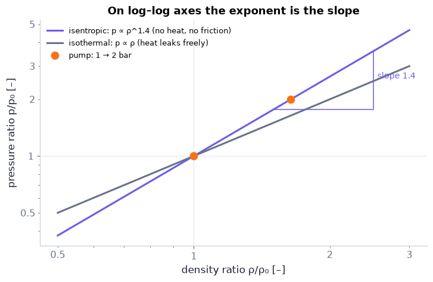

```python
r = np.logspace(np.log10(0.5), np.log10(3.0), 100)                             # density ratios ρ/ρ0 [–]
fig, ax = plt.subplots(figsize=(6.5, 4.2))                                     # one log–log panel
ax.loglog(r, ch01.isentropic_pressure(r, 1.0, 1.0), color=COLORS["accent"], label="isentropic: p ∝ ρ^1.4 (no heat, no friction)")  # (1.25)
ax.loglog(r, r, color=COLORS["muted"], label="isothermal: p ∝ ρ (heat leaks freely)")          # p/p0 = ρ/ρ0
ax.loglog([1, rho_ratio], [1, 2], "o", color=COLORS["orange"], ms=8, label="pump: 1 → 2 bar")  # the worked example
ax.plot([1.5, 2.5, 2.5], [1.5**1.4, 1.5**1.4, 2.5**1.4], color=COLORS["accent"], lw=1)         # slope triangle
ax.text(2.55, 1.9**1.4 * 1.05, "slope 1.4", color=COLORS["accent"], fontsize=9)                # its label
ax.set_xlabel("density ratio ρ/ρ₀ [–]"); ax.set_ylabel("pressure ratio p/p₀ [–]")             # dimensionless axes
from matplotlib.ticker import FuncFormatter                                                   # control how tick labels are written
for axis in (ax.xaxis, ax.yaxis):                                                              # both log axes
    axis.set_major_formatter(FuncFormatter(lambda v, _: f"{v:g}"))                              # plain numbers: 1, 2 instead of 10⁰, 2×10⁰
    axis.set_minor_formatter(FuncFormatter(lambda v, _: f"{v:g}" if v in (0.5, 2, 3, 5) else ""))  # label only a few minor ticks
ax.set_title("On log–log axes the exponent is the slope")                                      # the message
ax.legend(loc="upper left", fontsize=8.5)                                                      # legend
plt.show()                                                                                     # display
```

**What you see.** Two straight lines through the point (1, 1): a steeper purple isentrope and a grey isotherm, with the pump's start and end states on the isentrope and a slope triangle.

**How to read it.** The slope of each line is the exponent: 1.4 for a squeeze with no heat exchange, 1 when heat leaks away freely. Doubling the pressure needs only a 1.64× denser gas on the isentrope, because the gas heats up.

**What would change if…** Helium (γ = 5/3) gives an even steeper line — it heats more when pumped. A slow squeeze in a thin metal cylinder would move the gas toward the grey line.

📝 **Note.** **The isentropic ratios** `C46` — Combining $p/\rho^\gamma = \text{const}$ (1.25) with p = ρRT gives (stated) the temperature and density along an isentrope directly from the pressure ratio — the pump numbers above; θ in §1.10 is built from the first of them.

$$ \frac{T}{T_0} = \left(\frac{p}{p_0}\right)^{(\gamma-1)/\gamma}, \qquad \frac{\rho}{\rho_0} = \left(\frac{p}{p_0}\right)^{1/\gamma} \qquad \text{(1.26)} $$

📝 **Note.** **Sound speed of a perfect gas** `C47` — Differentiating p = Kρ^γ at constant s gives (∂p/∂ρ)_s = γp/ρ = γRT, so (stated, closing C36) the speed of sound depends on temperature only: 340.3 m/s at 288.15 K, 317 m/s at 250 K. **Trap:** Newton used the isothermal slope RT and got √(RT) = 287.6 m/s — 15 % too slow.

$$ c = \sqrt{\gamma R T} \qquad \text{(1.27)} $$

#### 🎮 Interactive: Same two states: what depends on the path?

Path dependence clicks only when you drag a route between the same two states and watch q and w change while Δe and Δs stay fixed; the irreversible modes then show where T ds = δq breaks. It ties together C25, C35 and this block, and its Derivation tab steps through D10 and D14.

**What to try:**

- Run 'isothermal ×2', then 'cool then expand', and compare the q and w bars.
- Open the Derivation tab and step through D10 with the stirring mode switched on at step 7.
- Choose 'pump (isentropic)' and check that the bold curve lies on the faint isentrope.
- Free expansion: which bar stays at zero, and what does Δs do?

```python
show_viz("ch01", "heat_work_paths")   # full-width explainer; ⤢ Full screen for more room
```

🎮 Interactive 3/5 Same two states: what depends on the path? Open alone ↗

[interactive chart not shown]

**What would change if…** a parcel of air were carried upward instead of pumped? Its pressure falls, so it expands and cools along exactly this isentrope — while the air around it follows hydrostatics. Whether it ends up heavier or lighter than its surroundings is the question of §1.10.

## 1.10 Stability of Stratified Fluid Media

**What is this section about?** Whether a fluid whose density changes with height is stable: displace a small parcel and see whether buoyancy pushes it back. For air this becomes a comparison of two lapse rates — written with **two opposite sign conventions** in the literature, and both are used here — and it is captured in one line by the potential temperature. (This book section also contains the isothermal atmosphere and the scale height, already stated as C62 and C63 in §1.9.)

> **Lapse-rate conventions in every cell of this section.** We compute with Kundu's Γ ≡ dT/dz, print the meteorology value Γ_met = −dT/dz next to it, and always write the stability inequality in the form being used.

### 🧩 The displaced parcel: buoyancy as a restoring or runaway force `C50`

*The question:* Nudge a small blob of fluid upward and let go. What force acts on it, and does it come back?

#### The problem in plain words

Morning fog stays trapped in a valley; a chimney plume spreads out flat under an inversion (a layer where the temperature rises with height); the ocean's thermocline (the layer, typically a few hundred metres down, where temperature and density change fastest with depth) blocks mixing between warm surface water and the cold deep; on a hot afternoon air parcels shoot up into towering cumulus. The same test decides all of them.

#### The idea

```
z_o + ζ ──  parcel density  ρ(z_o) + (dρ_a/dz)·ζ        environment  ρ(z_o) + (dρ/dz)·ζ
   ↑ ζ       the parcel changes along ITS OWN path        the surroundings keep THEIR profile
z_o ─────── parcel = environment (at rest)
parcel heavier than its new surroundings  → pushed back down  (stable)
parcel lighter                            → pushed further up (unstable)
```

The tools are already in place: Newton's second law (P09, C06), the first-order Taylor expansion (P26, C20) and buoyancy = weight of the displaced fluid (D37, C20).

> 📎 **Primer — square root of a negative number.** `P45` · There is no real number whose square is negative, so we name one: $i$ with $i^2 = -1$, and then $\sqrt{-a} = i\sqrt a$. Two facts turn exponentials into the curves we will see. **Euler's formula** $e^{i\theta} = \cos\theta + i\sin\theta$, so $\tfrac12(e^{iNt} + e^{-iNt}) = \cos Nt$ — an oscillation. The **hyperbolic cosine** $\cosh x = \tfrac12(e^{x} + e^{-x})$ — equal to 1 at x = 0, then growing like ½eˣ: a runaway. Its partner, the **hyperbolic sine** $\sinh x = \tfrac12(e^{x} - e^{-x})$, starts at 0 and also grows like ½eˣ. Replacing a real frequency by an imaginary one turns cos into cosh: $\cos(i\sigma t) = \cosh(\sigma t)$.

```python
theta = 0.7                                                    # any angle [rad]
print(np.exp(1j * theta), np.cos(theta) + 1j * np.sin(theta))  # Euler's formula (1j is Python's i): both (0.7648+0.6442j)
print(np.cosh(2.0), (np.exp(2.0) + np.exp(-2.0)) / 2)          # cosh 2 = (e² + e⁻²)/2 = 3.762
print(np.cos(1j * 2.0).real)                                   # cos(2i) = cosh 2 = 3.762: an imaginary frequency means growth
```

```
(0.7648421872844885+0.644217687237691j) (0.7648421872844885+0.644217687237691j)
3.7621956910836314 3.7621956910836314
3.7621956910836314
```

> 📎 **Primer — linear second-order ODE.** `P44` · $\zeta'' + N^2\zeta = 0$ with a constant $N^2$. Try $\zeta = e^{\lambda t}$: every derivative brings down a factor λ, so $\lambda^2 + N^2 = 0$ and $\lambda = \pm\sqrt{-N^2}$. If $N^2 > 0$ the roots are $\pm iN$ and (P45) the solutions are cos Nt and sin Nt — oscillation. If $N^2 < 0$ the roots are real, $\pm\sigma$ with $\sigma = \sqrt{-N^2}$, and the solutions are cosh σt and sinh σt — runaway. If $N^2 = 0$ both roots are 0 (a *double* root): the equation is just ζ″ = 0, whose solutions are 1 and t, so ζ = A + Bt — a straight line.

```python
N_demo, t_demo = 0.01, 100.0                                           # a frequency [1/s] and a time [s]
zeta_dd = -5 * N_demo**2 * np.cos(N_demo * t_demo)                     # second derivative of ζ = 5 cos(N t)
print(zeta_dd + N_demo**2 * 5 * np.cos(N_demo * t_demo))               # ζ'' + N² ζ → 0.0: it solves the equation
```

```
0.0
```

#### 🧮 Derivation — The parcel equation of §1.10 and N² (Eq. 1.29)

**What we want to show.** Find the equation of motion of a small blob of fluid pushed a little way up or down in a stratified fluid at rest, and the number that decides whether it comes back.

**Assumptions.** Small displacement ζ (steps 5–8) · the parcel moves without friction and adiabatically, with no mixing (step 5: it follows its own isentropic density) · its pressure instantly equals that of its surroundings (step 2: buoyancy from the environment) · the background is static (step 6) · released from rest (steps 13–14).

**The plan.**

1. Forces: weight and buoyancy.
2. Densities of the parcel and of its new surroundings, to first order in ζ.
3. Keep only first-order terms.
4. Name the coefficient N² and solve.

**Tools we use** (each explained before this point): Newton's second law (P09) · buoyancy (D37, C20) · first-order Taylor expansion (P26) · square root of a negative number, Euler's formula and cosh (P45) · linear second-order ODE (P44)

**We start from**

$$ \rho_p V\,\dfrac{d^2\zeta}{dt^2} = \sum F_z $$

*In words:* Newton's second law for a parcel of volume V and density ρ_p displaced by ζ from its rest height z_o.

**Step 1 of 14 — Name the parcel's two vertical forces.**

$$ \sum F_z = -\rho_p V g + F_b $$

- *Why we can do this:* Its weight points down; the surrounding fluid's pressure gives a net force F_b. Nothing else acts on a frictionless parcel. We list the forces before using Newton's law.
- *In words:* Weight down, buoyancy up.

**Step 2 of 14 — Use the buoyancy of D37 at the new height.**

$$ F_b = \rho(z_o + \zeta)\,V g $$

- *Why we can do this:* The parcel's pressure matches its surroundings, so the pressure around it is the environment's hydrostatic pressure at z_o + ζ; D37 says the net push is the weight of displaced *environment* fluid there.
- *In words:* The parcel is buoyed up by the fluid it pushes aside at its new height.

**Step 3 of 14 — Insert both forces into Newton's law.**

$$ \rho_p V\,\dfrac{d^2\zeta}{dt^2} = -\rho_p V g + \rho(z_o+\zeta)\,V g $$

- *Why we can do this:* The start says mass × acceleration equals the sum of the forces; steps 1 and 2 give that sum term by term.
- *In words:* The parcel accelerates according to the difference between buoyancy and weight.

**Step 4 of 14 — Divide by the parcel's mass ρ_pV.**

$$ \dfrac{d^2\zeta}{dt^2} = -\,g\,\dfrac{\rho_p - \rho(z_o+\zeta)}{\rho_p} $$

- *Why we can do this:* ρ_pV ≠ 0, so we may divide both sides by it; the g terms are collected as −g(ρ_p − ρ(z_o+ζ))/ρ_p, which leaves the acceleration alone on the left.
- *In words:* A parcel heavier than its surroundings accelerates down.

**Step 5 of 14 — Expand the parcel's density along its own path.**

$$ \rho_p = \rho(z_o) + \dfrac{d\rho_a}{dz}\,\zeta $$

- *Why we can do this:* First-order Taylor expansion (P26). The parcel started with the environment's density ρ(z_o) and changes adiabatically as it meets new pressure; dρ_a/dz is that isentropic rate of change.
- *In words:* The parcel's density changes at its own rate.

**Step 6 of 14 — Expand the environment's density at the new height.**

$$ \rho(z_o+\zeta) = \rho(z_o) + \dfrac{d\rho}{dz}\,\zeta $$

- *Why we can do this:* First-order Taylor expansion of the static background profile; dρ/dz is the environment's gradient.
- *In words:* The surroundings have their own, different rate.

**Step 7 of 14 — Subtract the two.**

$$ \rho_p - \rho(z_o+\zeta) = \Big(\dfrac{d\rho_a}{dz} - \dfrac{d\rho}{dz}\Big)\zeta $$

- *Why we can do this:* ρ(z_o) cancels because parcel and environment matched at rest; what remains is first order in ζ.
- *In words:* The density difference grows in proportion to the displacement.

**Step 8 of 14 — Keep only the leading term in the denominator.**

$$ \rho_p \approx \rho(z_o) $$

- *Why we can do this:* The numerator is already proportional to ζ; the correction (dρ_a/dz)ζ in the denominator would only add terms of order ζ², which we drop for a small displacement.
- *In words:* For the inertia, the parcel's density is simply its starting density.

**Step 9 of 14 — Substitute steps 7 and 8 into step 4.**

$$ \dfrac{d^2\zeta}{dt^2} = -\,\dfrac{g}{\rho(z_o)}\Big(\dfrac{d\rho_a}{dz} - \dfrac{d\rho}{dz}\Big)\zeta $$

- *Why we can do this:* Replace the density difference in the numerator by step 7 and the denominator by step 8; nothing else changes.
- *In words:* The acceleration is proportional to the displacement.

**Step 10 of 14 — Swap the order in the bracket.**

$$ \dfrac{d^2\zeta}{dt^2} - \dfrac{g}{\rho(z_o)}\Big(\dfrac{d\rho}{dz} - \dfrac{d\rho_a}{dz}\Big)\zeta = 0 $$

- *Why we can do this:* −(a − b) = (b − a); then move the right-hand side to the left. This is the form the book writes.
- *In words:* The parcel equation of §1.10.

**Step 11 of 14 — Name the coefficient N².**

$$ N^2 \equiv -\dfrac{g}{\rho(z_o)}\Big(\dfrac{d\rho}{dz} - \dfrac{d\rho_a}{dz}\Big) $$

- *Why we can do this:* Definition (1.29), chosen so that the equation reads ζ″ + N²ζ = 0 — the oscillator form of P44.
- *In words:* One number collects gravity and the two density gradients.

**Step 12 of 14 — Try an exponential solution.**

$$ \zeta = e^{\lambda t}\ \Rightarrow\ \lambda^2 + N^2 = 0 $$

- *Why we can do this:* For a linear equation with constant coefficients, e^{λt} turns derivatives into powers of λ (P44); e^{λt} ≠ 0 divides out.
- *In words:* The motion is set by the roots λ = ±√(−N²).

**Step 13 of 14 — Apply release from rest when N² ≠ 0.**

$$ \zeta = \zeta_0\cos Nt\ \ (N^2>0),\qquad \zeta = \zeta_0\cosh\!\big(\sqrt{-N^2}\,t\big)\ \ (N^2<0) $$

- *Why we can do this:* With two different roots ±λ the general solution is ae^{λt} + be^{−λt}. Starting at rest, ζ′(0) = λ(a − b) = 0, so a = b = ζ₀/2 (from ζ(0) = ζ₀): the even combination ½ζ₀(e^{λt} + e^{−λt}). For imaginary λ = iN that is ζ₀ cos Nt (Euler's formula, P45); for real λ = √(−N²) it is ζ₀ cosh √(−N²)t (P45).
- *In words:* Stable columns make the parcel oscillate; unstable ones make it run away.

**Step 14 of 14 — Treat the double root N² = 0.**

$$ \zeta = A + Bt,\quad \zeta'(0) = B = 0\ \Rightarrow\ \zeta = \zeta_0 $$

- *Why we can do this:* With N² = 0 both roots are 0 and e^{λt} gives only the constant; the equation is ζ″ = 0, whose general solution is the straight line A + Bt (P44). Release from rest means ζ′(0) = B = 0, and ζ(0) = A = ζ₀.
- *In words:* A neutral column leaves the parcel where it was put.

**Result**

$$ \dfrac{d^2\zeta}{dt^2} + N^2\zeta = 0,\qquad N^2 = -\dfrac{g}{\rho(z_o)}\Big(\dfrac{d\rho}{dz} - \dfrac{d\rho_a}{dz}\Big) $$

*In words:* a displaced parcel is a harmonic oscillator with squared frequency N², positive when the environment's density falls with height faster than the parcel's own.

**What it means.** Stability is a race between two density gradients: the environment's and the parcel's own adiabatic one. It is the book's first stability analysis — the same "linearise, then look at the sign of the growth rate" logic returns in Ch. 11. N is the highest frequency internal waves can have (Ch. 7 §7.8). The model has no friction, so a stable parcel rings forever; real fluids damp it. It fails for large displacements (the Taylor steps) and when the parcel mixes with its surroundings.

**Check it.** Units: (m s⁻² / kg m⁻³) × kg m⁻⁴ = s⁻² ✓. Limits: a uniform incompressible fluid with an incompressible parcel, dρ/dz = dρ_a/dz = 0 → N² = 0, neutral ✓; an environment that is exactly isentropic, dρ/dz = dρ_a/dz → neutral ✓. Number: ocean thermocline, dρ/dz = −0.01 kg m⁻⁴, dρ_a/dz = 0, ρ = 1025 kg/m³ → N² = 9.57×10⁻⁵ s⁻², period 642 s ✓ (the code below: `brunt_vaisala_sq`, `parcel_displacement`, an Euler–Cromer loop and the unlinearised `parcel_ode_from_gradients` agree).

> ⚠️ **Common confusion (traps in this derivation):** the sign of buoyancy; using the environment's gradient for the parcel; keeping O(ζ²) terms inconsistently; replacing ρ_p by ρ(z_o) *before* subtracting (that would lose the whole effect).

#### ✏️ Tiny example: a parcel in the ocean thermocline

ρ = 1025 kg/m³; the density falls upward by 1 kg/m³ per 100 m, so dρ/dz = −0.01 kg m⁻⁴; treat the parcel as incompressible, dρ_a/dz = 0.

1. N² = −(g/ρ)(dρ/dz − dρ_a/dz) = −(9.81/1025)(−0.01 − 0) = 9.57×10⁻⁵ s⁻².
2. N = 9.78×10⁻³ s⁻¹; period 2π/N = 642 s ≈ 10.7 min.
3. Released 5 m above its rest height: $\zeta(t) = 5\cos(0.00978\,t)$ m.

```python
N2_oc = ch01.brunt_vaisala_sq(1025.0, -0.01, 0.0)                     # Eq. (1.29): thermocline, incompressible parcel [1/s²]
t = np.linspace(0, 1800, 601)                                          # half an hour, every 3 s [s]
zeta = ch01.parcel_displacement(t, 5.0, N2_oc)                         # D18 step 13: ζ = 5 cos(N t) [m]
print(f"N² = {N2_oc:.4g} 1/s², {ch01.stability_timescale(N2_oc)}")    # 9.567e-05 and ('period', ≈ 642 s)
drho_a_demo = -0.005                                                   # a parcel that gets denser as it sinks [kg/m⁴] (illustrative)
N2_demo = ch01.brunt_vaisala_sq(1025.0, -0.01, drho_a_demo)            # its N² from (1.29) [1/s²]
for z0 in (5.0, 300.0, 1000.0):                                        # small, larger and very large releases [m]
    lin = ch01.parcel_displacement(t, z0, N2_demo)                     # linear solution (steps 13–14)
    nl = ch01.parcel_ode_from_gradients(t, z0, 1025.0, -0.01, drho_a_demo)   # step 4 before linearising, solve_ivp (P31)
    print(f"ζ0 = {z0:6.0f} m: largest linear − unlinearised gap = {np.abs(lin - nl).max():.2e} m "
          f"({np.abs(lin - nl).max() / z0:.1e} of the amplitude)")    # grows with the release height
```

```
N² = 9.567e-05 1/s², ('period', 642.364398579369)
ζ0 =      5 m: largest linear − unlinearised gap = 9.15e-05 m (1.8e-05 of the amplitude)
ζ0 =    300 m: largest linear − unlinearised gap = 3.30e-01 m (1.1e-03 of the amplitude)
ζ0 =   1000 m: largest linear − unlinearised gap = 3.68e+00 m (3.7e-03 of the amplitude)
```

**What does the code above do?**

1. `brunt_vaisala_sq` is $N^2 = -\frac{g}{\rho}\big(\frac{d\rho}{dz} - \frac{d\rho_a}{dz}\big)$ (1.29) with the two density gradients; `stability_timescale` gives the period.
2. `parcel_displacement` is the solution of steps 13–14 (cos, constant or cosh, chosen by the sign of N²).
3. `parcel_ode_from_gradients` solves Newton's law of step 4 *before* the small-displacement steps 5–8, keeping the parcel's changing density ρ_p in the denominator. (With an incompressible parcel, dρ_a/dz = 0, that denominator never changes and the two equations would be identical, so here the parcel is given a density gradient of its own.)
4. The gap relative to the amplitude grows with the release height — from about 10⁻⁵ for 5 m to a few ×10⁻³ for 1 km: linearisation (step 8) is excellent for small nudges and slowly degrades for large ones.

#### From scratch: an Euler–Cromer loop

```python
dt_p = 1.0                                          # time step [s]
z_mine = np.empty(1801); w = 0.0                    # displacement history [m] and vertical velocity [m/s]
z_mine[0] = 5.0                                     # released 5 m up, from rest
for k in range(1800):                               # 1800 steps = 30 min
    w += -N2_oc * z_mine[k] * dt_p                  # velocity first: dw/dt = −N² ζ (the parcel equation)
    z_mine[k + 1] = z_mine[k] + w * dt_p            # then position with the NEW velocity (Euler–Cromer, P30)
assert np.allclose(z_mine[::3], zeta, atol=0.05)    # within 5 cm (1 % of the amplitude) of the exact cosine
print(f"after 30 min: loop {z_mine[-1]:.3f} m, exact {zeta[-1]:.3f} m")   # loop vs cosine
```

```
after 30 min: loop 1.633 m, exact 1.609 m
```

```python
nfr_p = 48 if not FAST else 24                                                  # frames
t_an = np.linspace(0, 600, nfr_p)                                               # ten minutes [s]
cases = [(1e-4, "stable, N² = +1e-4 s⁻²", COLORS["teal"]), (0.0, "neutral, N² = 0", COLORS["amber"]),   # (N², label, colour) for …
         (-1e-4, "unstable, N² = −1e-4 s⁻²", COLORS["rose"])]                   # the three columns
top = 200.0                                                                     # height of the drawn column top [m]
tracks = [np.minimum(ch01.parcel_displacement(t_an, 20.0, N2c), top) for N2c, _, _ in cases]   # ζ(t), capped at the top [m]
fig = plt.figure(figsize=(7.6, 5.0))                                            # three columns above, ζ(t) below
gs = fig.add_gridspec(2, 3, height_ratios=[1.3, 1])   # 2 rows × 3 columns layout
dots_p = []   # the three parcel markers
for j, (N2c, lab, col) in enumerate(cases):                                     # draw each column once
    axc = fig.add_subplot(gs[0, j])   # column j in the top row
    shade = np.linspace(1, 0, 50)[:, None] if N2c > 0 else (np.zeros((50, 1)) + 0.5 if N2c == 0 else np.linspace(0, 1, 50)[:, None])   # density shading: stable, neutral, unstable
    axc.imshow(shade, extent=(-1, 1, -100, top), aspect="auto", cmap="Blues", vmin=-0.5, vmax=1.5, origin="lower")  # dark = dense
    axc.axhline(0, color=COLORS["muted"], lw=0.8, ls=":")                       # rest height z_o
    (dp_,) = axc.plot([0], [20.0], "o", color=col, ms=14)                       # the parcel
    dots_p.append(dp_)   # keep it for the update function
    axc.set_xticks([]); axc.set_ylim(-100, top); axc.set_title(lab, fontsize=9)   # fixed height axis and label
    axc.set_ylabel("ζ [m]" if j == 0 else "")   # y label on the first column only
axz = fig.add_subplot(gs[1, :])                                                 # the ζ(t) traces
lines_p = []   # the three growing traces
for (N2c, lab, col), trk in zip(cases, tracks):   # one trace per column
    axz.plot(t_an, trk, color=col, alpha=0.2, lw=1)                             # ghost of the whole solution
    (ln,) = axz.plot([], [], color=col, lw=2.5)                                 # the part played so far
    lines_p.append(ln)   # keep it for the update function
axz.set_xlim(0, 600); axz.set_ylim(-30, top + 10)   # fixed axes
axz.set_xlabel("time t [s]"); axz.set_ylabel("displacement ζ [m]")   # axis labels with units
def update(i):                                                                  # frame i: time t_an[i]
    for dp_, ln, trk in zip(dots_p, lines_p, tracks):   # each column in turn
        dp_.set_data([0], [trk[i]])                                             # move each parcel
        ln.set_data(t_an[:i + 1], trk[:i + 1])                                  # extend each trace
    return dots_p + lines_p   # the artists that changed
show_animation(animate(update, frames=nfr_p, fig=fig, interval=80), player="video")   # smooth MP4
```

[video not shown]

**What does the code above do?**

1. `parcel_displacement` gives ζ(t) for the three signs of N², each released 20 m above its rest height; the runaway parcel is stopped at the drawn column top with `np.minimum`.
2. Each column is shaded by density (dark = dense): heavy fluid below light fluid in the stable column, uniform in the neutral one, heavy over light in the unstable one.
3. The bottom panel draws each trace as time advances, over a faint ghost of the full solution.

**What you see.** One parcel bobbing up and down (period 10.5 min), one resting where it was released, one accelerating away until it hits the top of the drawing.

**How to read it.** The three curves are a cosine, a flat line and a cosh; nothing but the sign of N² differs between the columns.

**What would change if…** N² were doubled: the period would shrink by √2, from 10.5 to 7.4 minutes, and the runaway parcel would escape faster by the same factor.

**What would change if…** the parcel felt friction or exchanged heat with its surroundings? The oscillation would die out — the model has neither, so it rings forever. **Next:** everything hinges on the number N² — let us read it (C51).

### 🧩 The Brunt–Väisälä frequency N²: one number that classifies a column `C51`

*The question:* What do the sign and the size of N² tell you about a fluid column before you push anything?

#### The problem in plain words

Internal waves in the ocean, lee waves behind mountains, the Richardson number of Ch. 11, the convection switch in climate models — all read N². It is the natural frequency of a stratified fluid.

#### The idea

| N² | motion after release | time scale |
| --- | --- | --- |
| > 0 | oscillation, cos Nt | period 2π/N |
| = 0 | stays (or drifts at its initial speed) | none |
| < 0 | runaway, cosh √(−N²) t | e-folding time 1/√(−N²) |

> 🔁 An imaginary frequency means growth: cos(iσt) = cosh σt, and cosh x = ½(eˣ + e⁻ˣ) (primer P45 in the C50 block).

#### The maths, step by step

1. From D18: $$N^2 = -\frac{g}{\rho(z_o)}\left(\frac{d\rho}{dz} - \frac{d\rho_a}{dz}\right) \qquad (1.29) \quad [\mathrm{1/s^2}]$$ with g [m/s²], ρ [kg/m³] and the density gradients in kg/m⁴.
2. N² > 0 ⇔ dρ/dz < dρ_a/dz: the environment's density falls with height **faster** than a displaced parcel's does.
3. N = √N² [rad/s], and the period is T_N = 2π/N [s].
4. N² < 0: growth rate σ = √(−N²) [1/s] and e-folding time 1/σ. After 3 e-foldings the displacement has grown by cosh 3 ≈ ½e³ ≈ 10× — the ½ in cosh halves what a pure exponential (e³ ≈ 20×) would give.

📝 **Note.** **Stable, neutral, unstable** `C52` — **Stable** (N² > 0): a displaced parcel returns and oscillates. **Unstable** (N² < 0): it accelerates away. **Neutral** (N² = 0): it stays where it is put — reached either when density does not vary at all (dρ/dz = dρ_a/dz = 0) or when the environment's density falls exactly as fast as a parcel's (dρ/dz = dρ_a/dz), an atmosphere of uniform entropy.

#### ✏️ Tiny example: reading three values of N²

- N² = 10⁻⁴ s⁻² → N = 0.01 s⁻¹ → period 628 s = 10.5 min.
- N² = 4×10⁻⁴ s⁻² → N = 0.02 s⁻¹ → period 314 s.
- N² = −10⁻⁴ s⁻² → σ = 0.01 s⁻¹ → one e-folding every 100 s; after 5 minutes (3 e-foldings) the parcel is cosh(3) = 10.1 times as far from its rest height as it started.

> 📎 **Primer — np.where and np.select.** `P46` · `np.where(cond, a, b)` picks a where the condition holds and b elsewhere, element by element; `np.select([c1, c2], [a1, a2], default)` handles several regimes — that is how labels like "stable" are assigned to whole arrays.

```python
x = np.array([1e-4, 0.0, -1e-4])                                          # three values of N² [1/s²]
print(np.where(x > 0, "stable", "not stable"))                           # two regimes
print(np.select([x > 0, x < 0], ["stable", "unstable"], "neutral"))      # three regimes
```

```
['stable' 'not stable' 'not stable']
['stable' 'neutral' 'unstable']
```

```python
N2_set = np.array([4e-4, 1e-4, 0.0, -1e-4])                   # four columns [1/s²]
print(ch01.classify_stability(N2_set))                        # C52 labels → ['stable' 'stable' 'neutral' 'unstable']
for x in N2_set:                                              # the time scale of each
    kind, secs = ch01.stability_timescale(x)                  # ('period', s), ('none', inf) or ('efold', s)
    print(f"N² = {x:+.0e} 1/s²: {kind} {secs:.1f} s")   # kind and time scale
```

```
['stable' 'stable' 'neutral' 'unstable']
N² = +4e-04 1/s²: period 314.2 s
N² = +1e-04 1/s²: period 628.3 s
N² = +0e+00 1/s²: none inf s
N² = -1e-04 1/s²: efold 100.0 s
```

**What does the code above do?**

1. `classify_stability` labels each N² (with `np.select`-style logic, P46).
2. `stability_timescale` returns the period 2π/N for stable columns, the e-folding time 1/√(−N²) for unstable ones and no time scale for a neutral column.

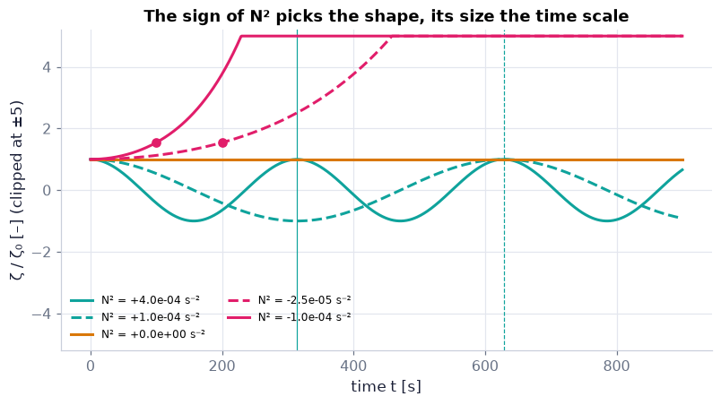

```python
t_f = np.linspace(0, 900, 901)                                             # 15 minutes [s]
fig, ax = plt.subplots(figsize=(7.2, 4))                                   # one panel
for N2c, col, ls in ((4e-4, COLORS["teal"], "-"), (1e-4, COLORS["teal"], "--"), (0.0, COLORS["amber"], "-"),   # five columns:
                     (-2.5e-5, COLORS["rose"], "--"), (-1e-4, COLORS["rose"], "-")):                            # N², colour, line style
    ax.plot(t_f, np.clip(ch01.parcel_displacement(t_f, 1.0, N2c), -5, 5), color=col, ls=ls, label=f"N² = {N2c:+.1e} s⁻²")  # ζ/ζ0
    kind, secs = ch01.stability_timescale(N2c)                             # its time scale
    if kind == "period":                                                   # oscillating column
        ax.axvline(secs, color=col, ls=ls, lw=0.8)                         # a dashed vertical at each period
    elif kind == "efold":                                                  # runaway column
        ax.plot([secs], [np.cosh(1.0)], "o", color=col)                    # a dot one e-folding time after release
ax.set_ylim(-5.2, 5.2)                                                     # fixed range; runaways leave the frame
ax.set_xlabel("time t [s]"); ax.set_ylabel("ζ / ζ₀ [–] (clipped at ±5)")   # axis labels
ax.set_title("The sign of N² picks the shape, its size the time scale")   # the message
ax.legend(loc="lower left", fontsize=8, ncol=2)                            # legend in two columns
plt.show()                                                                 # display
```

**What you see.** Two cosines of different periods (teal), a flat line (amber) and two curves that leave the frame upward (rose). Vertical lines mark the two periods (314 s and 628 s); dots mark one e-folding time on the growing curves (100 s and 200 s).

**How to read it.** The sign of N² decides the shape of the motion; its size sets the time scale — the period 2π/N or the e-folding time 1/√(−N²).

**What would change if…** Halve every |N²| and every time scale grows by √2: the periods move right to 444 s and 889 s, and the runaways take 141 s and 283 s per e-folding.

> 📎 **Primer — live widgets.** `P47` · `live(fn, a=(lo, hi, step))` builds ipywidgets sliders that re-run `fn` each time you release a slider — but only while Python is running (Colab or a local Jupyter). On the published web page the cell is frozen and replaced by a note; the static figure above carries the idea there.

> ▶️ **Live cell.** The widget below needs a running Python kernel. On the web page it is frozen — open this notebook in Colab (button at the top) or run it locally to drag the sliders.

```python
from fluidpy.core.interact import live                                             # ipywidgets sliders (kernel only)
def parcel_plot(N2=1e-4, zeta0=20.0):                                              # called again whenever a slider moves
    t_l = np.linspace(0, 1800, 400)                                                # half an hour [s]
    rho0 = 1025.0                                                                  # seawater density [kg/m³]
    lin = ch01.parcel_displacement(t_l, zeta0, N2)                                 # linear solution (D18 steps 13–14)
    drho_a = -0.005                                                                # the parcel's own density gradient [kg/m⁴]
    drho_env = drho_a - N2 * rho0 / ch01.G0                                        # environment gradient that gives this N² (1.29)
    nl = ch01.parcel_ode_from_gradients(t_l, zeta0, rho0, drho_env, drho_a, zeta_max=2000.0)   # unlinearised, stopped at 2 km
    fig, ax = plt.subplots(figsize=(6.5, 3.2))                                     # one panel
    ax.plot(t_l, lin, color=COLORS["accent"], label="linear ζ₀ cos/cosh")   # linear solution
    ax.plot(t_l, nl, "--", color=COLORS["orange"], label="unlinearised (stops at 2 km)")   # unlinearised solution
    ax.set_ylim(-1.2 * zeta0, 2000); ax.set_xlabel("t [s]"); ax.set_ylabel("ζ [m]"); ax.legend(fontsize=8)   # axes and legend
    plt.show()                                                                     # draw the figure for these slider values
_ = live(parcel_plot, N2=(-2e-4, 4e-4, 1e-5), zeta0=(1.0, 200.0, 1.0))            # two sliders (_ hides the return value)
```

▶️ **Live cell.** These sliders need a running Python kernel, so they are frozen on this page. Press **Open in Colab** at the top (or run the notebook locally) to use them.

**What does the code above do?**

1. The callback draws the linear solution and the unlinearised Newton law for the chosen N² and release height. The parcel has its own density gradient dρ_a/dz = −0.005 kg m⁻⁴, and the environment gradient is chosen so that $N^2 = -\frac{g}{\rho}\big(\frac{d\rho}{dz} - \frac{d\rho_a}{dz}\big)$ (1.29) gives the slider's N²; the unlinearised law therefore keeps the parcel's changing density in its denominator.
2. On this 2 km axis the two curves lie on top of each other: as the C50 printout showed, their gap stays a small fraction of the displacement (about 10⁻³ at a few hundred metres). The only visible difference is for N² < 0, where the runaway unlinearised run is stopped at 2 km while the linear cosh keeps growing.

📝 **Note.** **Seawater** `C60` — Seawater density depends on temperature, pressure **and salinity** S (grams of salt per kilogram of seawater, about 35 g/kg on average). The **potential density** ρ_θ is the density a parcel would have if it were brought isentropically (no heat, no friction) to a fixed reference pressure — defined properly in C58, below in this section. A displaced parcel keeps its salt, so for seawater ρ_θ is taken at constant S, and oceanographers refer densities to sea-level pressure. Our linear model: 10 °C and 35 g/kg → 1027.0 kg/m³; 20 °C → 1025.3 kg/m³.

$$ \rho = \rho(T, p, S) $$

📝 **Note.** **How fast a sinking ocean parcel gets denser** `N21` — A parcel moved vertically in the ocean is squeezed or relaxed by the pressure of its surroundings, at constant entropy and salinity, so (stated) its density changes at a rate set by the speed of sound: with c = 1500 m/s and ρ = 1025 kg/m³, dρ_a/dz = −4.47×10⁻³ kg m⁻⁴.

$$ \frac{d\rho_a}{dz} \cong -\frac{\rho g}{c^2} $$

📝 **Note.** **The ocean's stability criterion** `C61` — With N21, $N^2 = -\frac{g}{\rho}\big(\frac{d\rho}{dz} - \frac{d\rho_a}{dz}\big)$ (1.29) becomes the ocean's stability test: the column is stable when the compressibility-corrected density gradient below is negative. **We read $d\rho_\theta/dz \cong d\rho/dz + \rho g/c^2$ (1.35) as "has the same sign as" dρ_θ/dz** — the two sides agree only up to a positive factor near the reference pressure. Thermocline with dρ/dz = −0.01 kg m⁻⁴: −0.01 + 0.00447 = −5.53×10⁻³ kg m⁻⁴ < 0 → stable, but N² drops from 9.57×10⁻⁵ to 5.29×10⁻⁵ s⁻² (the period grows from 10.7 to 14.4 min), because the sinking parcel is also squeezed denser.

$$ \frac{d\rho_\theta}{dz} \;\sim\; \frac{d\rho}{dz} + \frac{\rho g}{c^2} \qquad \text{(1.35)} $$

```python
print("C60 linear seawater ρ at 10 and 20 °C, 35 g/kg:", ch01.seawater_density_linear(np.array([283.15, 293.15]), 35.0))   # warmer water is lighter
drho_a = ch01.isentropic_density_gradient(1025.0, 1500.0)                         # N21: −ρ g / c² [kg/m⁴]
print(f"N21 parcel density gradient: {drho_a:.3e} kg/m⁴")   # the parcel's own gradient
print(f"C61 corrected gradient: {ch01.ocean_potential_density_gradient(-0.01, 1025.0, 1500.0):.3e} kg/m⁴")   # (1.35)
N2_c = ch01.brunt_vaisala_sq(1025.0, -0.01, drho_a)                              # (1.29) with a compressible parcel
print(f"N² with a compressible parcel: {N2_c:.3e} 1/s², period {ch01.stability_timescale(N2_c)[1]/60:.1f} min")   # weaker stability, longer period
```

```
C60 linear seawater ρ at 10 and 20 °C, 35 g/kg: [1027.     1025.2849]
N21 parcel density gradient: -4.467e-03 kg/m⁴
C61 corrected gradient: -5.533e-03 kg/m⁴
N² with a compressible parcel: 5.293e-05 1/s², period 14.4 min
```

**What does the code above do?**

1. `seawater_density_linear` is a linear equation of state in T and S around 10 °C and 35 g/kg.
2. `isentropic_density_gradient` is −ρg/c² (N21); `ocean_potential_density_gradient` adds it to the observed gradient (C61).
3. Putting the parcel's own gradient into `brunt_vaisala_sq` shows the stability is weaker than the incompressible estimate.

**What would change if…** the fluid were air, whose parcels expand a lot as they rise? Then dρ_a/dz is large, and it is easier to compare temperatures than densities. **Next:** the adiabatic lapse rate (C54).